# Elsevier 2022 SDG mapping

# General to all SDGs

## Introduction

The United Nations Sustainable Development Goals (SDGs) challenge the global community to build a world where no one is left behind.

Since 2018, Elsevier has generated SDG search queries to help researchers and institutions track and demonstrate progress toward the SDG targets. In the past 3 years, these queries, along with the university’s own data and evidence supporting progress and contributions to the particular SDG outside of research-based metrics, are used for the THE Impact Rankings.

## Method

For 2022, this SDG uses the exact same search query and ML algorithm as the Elsevier 2021 SDG mapping. [Full details of the 2021 methodology are available on Digital Commons Data.](https://elsevier.digitalcommonsdata.com/datasets/9sxdykm8s4/4)

# [SDG 11 - Make cities and human settlements inclusive, safe, resilient and sustainable](https://sdgs.un.org/goals/goal11)

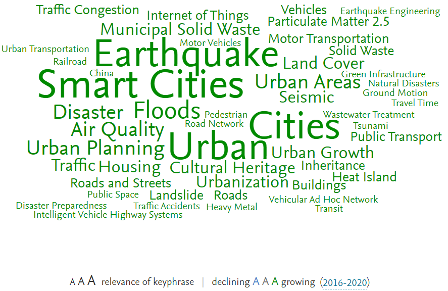

Explore this wordcloud plus the most active contributors on the [SciVal SDG site](https://scival.com/sdg)

## Query

Below is the full search query used for this SDG. We’ve broken it down by each query component. Use the + and – to concatenate the different bracket levels.

(

(

(

TITLE-ABS

(

"land use planning"

)

AND TITLE-ABS

(

"suburban"

)

)

OR

(

AUTHKEY

(

"land use planning"

)

AND AUTHKEY

(

"suburban"

)

)

OR

(

TITLE-ABS

(

"landscape* plan*"

)

AND TITLE-ABS

(

"city"

)

)

OR

(

AUTHKEY

(

"landscape* plan*"

)

AND AUTHKEY

(

"city"

)

)

OR

(

TITLE-ABS

(

"land use planning"

)

AND TITLE-ABS

(

"housing"

)

)

OR

(

AUTHKEY

(

"land use planning"

)

AND AUTHKEY

(

"housing"

)

)

OR TITLE-ABS

(

"urban renewal project"

)

OR AUTHKEY

(

"urban renewal project"

)

OR TITLE-ABS

(

"town planning"

)

OR AUTHKEY

(

"town planning"

)

OR TITLE-ABS

(

"New urbanism"

)

OR AUTHKEY

(

"New urbanism"

)

OR

(

TITLE-ABS

(

"public participation"

)

AND TITLE-ABS

(

"urban* design*"

)

)

OR

(

AUTHKEY

(

"public participation"

)

AND AUTHKEY

(

"urban* design*"

)

)

OR

(

TITLE-ABS

(

"town-planning"

)

OR TITLE-ABS

(

"townplanning"

)

)

OR

(

AUTHKEY

(

"town-planning"

)

OR AUTHKEY

(

"townplanning"

)

)

OR TITLE-ABS

(

"integrated urban"

)

OR AUTHKEY

(

"integrated urban"

)

OR TITLE-ABS

(

"urban infrastructure"

)

OR AUTHKEY

(

"urban infrastructure"

)

OR TITLE-ABS

(

"creative city"

)

OR AUTHKEY

(

"creative city"

)

OR

(

TITLE-ABS

(

"urban renewal"

)

AND TITLE-ABS

(

"slum"

)

)

OR

(

AUTHKEY

(

"urban renewal"

)

AND AUTHKEY

(

"slum"

)

)

OR

(

TITLE-ABS

(

"urban expansion"

)

AND TITLE-ABS

(

"environment*"

)

)

OR

(

AUTHKEY

(

"urban expansion"

)

AND AUTHKEY

(

"environment*"

)

)

OR

(

TITLE-ABS

(

"urban design"

)

AND TITLE-ABS

(

"participatory"

)

)

OR

(

AUTHKEY

(

"urban design"

)

AND AUTHKEY

(

"participatory"

)

)

OR TITLE-ABS

(

"regional development plans"

)

OR AUTHKEY

(

"regional development plans"

)

OR TITLE-ABS

(

"regional development planning"

)

OR AUTHKEY

(

"regional development planning"

)

OR

(

(

TITLE-ABS("land-use planning") AND TITLE-ABS("urban*")

)

OR

(

TITLE-ABS("landuse planning") AND TITLE-ABS("urban*")

)

)

OR

(

(

AUTHKEY("land-use planning") AND AUTHKEY("urban*")

)

OR

(

AUTHKEY("landuse planning") AND AUTHKEY("urban*")

)

)

OR TITLE-ABS

(

"participatory geographical information system"

)

OR AUTHKEY

(

"participatory geographical information system"

)

OR TITLE-ABS

(

"urban sustainability"

)

OR AUTHKEY

(

"urban sustainability"

)

OR

(

TITLE-ABS

(

"urban renewal"

)

AND TITLE-ABS

(

"redevelopment"

)

)

OR

(

AUTHKEY

(

"urban renewal"

)

AND AUTHKEY

(

"redevelopment"

)

)

OR

(

TITLE-ABS

(

"public participation"

)

AND TITLE-ABS

(

"urban*"

)

)

OR

(

AUTHKEY

(

"public participation"

)

AND AUTHKEY

(

"urban*"

)

)

OR

(

TITLE-ABS

(

"urban design"

)

AND TITLE-ABS

(

"inclusiveness"

)

)

OR

(

AUTHKEY

(

"urban design"

)

AND AUTHKEY

(

"inclusiveness"

)

)

OR TITLE-ABS

(

"urban development"

)

OR AUTHKEY

(

"urban development"

)

OR TITLE-ABS

(

"urban renewal policy"

)

OR AUTHKEY

(

"urban renewal policy"

)

OR TITLE-ABS

(

"intermunicipal cooperation"

)

OR AUTHKEY

(

"intermunicipal cooperation"

)

OR

(

TITLE-ABS

(

"land expansion"

)

AND TITLE-ABS

(

"urban*"

)

)

OR

(

AUTHKEY

(

"land expansion"

)

AND AUTHKEY

(

"urban*"

)

)

OR TITLE-ABS

(

"mapping urban"

)

OR AUTHKEY

(

"mapping urban"

)

OR TITLE-ABS

(

"urban forms"

)

OR AUTHKEY

(

"urban forms"

)

OR TITLE-ABS

(

"urban design and planning"

)

OR AUTHKEY

(

"urban design and planning"

)

OR TITLE-ABS

(

"public participation gis"

)

OR AUTHKEY

(

"public participation gis"

)

OR TITLE-ABS

(

"urban governance"

)

OR AUTHKEY

(

"urban governance"

)

OR TITLE-ABS

(

"urban land"

)

OR AUTHKEY

(

"urban land"

)

OR TITLE-ABS

(

"urban renewal program"

)

OR AUTHKEY

(

"urban renewal program"

)

OR

(

TITLE-ABS

(

"land use planning"

)

AND TITLE-ABS

(

"communities"

)

)

OR

(

AUTHKEY

(

"land use planning"

)

AND AUTHKEY

(

"communities"

)

)

OR TITLE-ABS

(

"human settlement planning"

)

OR AUTHKEY

(

"human settlement planning"

)

OR TITLE-ABS

(

"development of cities"

)

OR AUTHKEY

(

"development of cities"

)

OR TITLE-ABS

(

"shrinking city"

)

OR AUTHKEY

(

"shrinking city"

)

OR

(

(

TITLE-ABS("land-use planning") AND TITLE-ABS("cities")

)

OR

(

TITLE-ABS("landuse planning") AND TITLE-ABS("cities")

)

)

OR

(

(

AUTHKEY("land-use planning") AND AUTHKEY("cities")

)

OR

(

AUTHKEY("landuse planning") AND AUTHKEY("cities")

)

)

OR TITLE-ABS

(

"urban infrastructure"

)

OR AUTHKEY

(

"urban infrastructure"

)

OR TITLE-ABS

(

"urban renewal strategies"

)

OR AUTHKEY

(

"urban renewal strategies"

)

OR TITLE-ABS

(

"slum clearance"

)

OR AUTHKEY

(

"slum clearance"

)

OR TITLE-ABS

(

"participatory gis"

)

OR AUTHKEY

(

"participatory gis"

)

OR TITLE-ABS

(

"town planning"

)

OR AUTHKEY

(

"town planning"

)

OR TITLE-ABS

(

"compact cities"

)

OR AUTHKEY

(

"compact cities"

)

OR TITLE-ABS

(

"new towns"

)

OR AUTHKEY

(

"new towns"

)

OR TITLE-ABS

(

"creative city"

)

OR AUTHKEY

(

"creative city"

)

OR TITLE-ABS

(

"urban policy"

)

OR AUTHKEY

(

"urban policy"

)

OR TITLE-ABS

(

"urban infrastructures"

)

OR AUTHKEY

(

"urban infrastructures"

)

OR TITLE-ABS

(

"metropolitan governance"

)

OR AUTHKEY

(

"metropolitan governance"

)

OR TITLE-ABS

(

"urban transformation"

)

OR AUTHKEY

(

"urban transformation"

)

OR

(

TITLE-ABS

(

"landscape* plan*"

)

AND TITLE-ABS

(

"suburb*"

)

)

OR

(

AUTHKEY

(

"landscape* plan*"

)

AND AUTHKEY

(

"suburb*"

)

)

OR TITLE-ABS

(

"sustainable urbanization"

)

OR AUTHKEY

(

"sustainable urbanization"

)

OR TITLE-ABS

(

"development of city"

)

OR AUTHKEY

(

"development of city"

)

OR

(

TITLE-ABS

(

"land use planning"

)

AND TITLE-ABS

(

"cities"

)

)

OR

(

AUTHKEY

(

"land use planning"

)

AND AUTHKEY

(

"cities"

)

)

OR TITLE-ABS

(

"urban renewal policies"

)

OR AUTHKEY

(

"urban renewal policies"

)

OR TITLE-ABS

(

"urban settlement planning"

)

OR AUTHKEY

(

"urban settlement planning"

)

OR TITLE-ABS

(

"shrinking cities"

)

OR AUTHKEY

(

"shrinking cities"

)

OR TITLE-ABS

(

"urban plan"

)

OR AUTHKEY

(

"urban plan"

)

OR

(

TITLE-ABS

(

"urban design"

)

AND TITLE-ABS

(

"inclusive"

)

)

OR

(

AUTHKEY

(

"urban design"

)

AND AUTHKEY

(

"inclusive"

)

)

OR

(

TITLE-ABS

(

"public participation"

)

AND TITLE-ABS

(

"urban* plan*"

)

)

OR

(

AUTHKEY

(

"public participation"

)

AND AUTHKEY

(

"urban* plan*"

)

)

OR

(

TITLE-ABS

(

"regeneration projects"

)

AND TITLE-ABS

(

"urban*"

)

)

OR

(

AUTHKEY

(

"regeneration projects"

)

AND AUTHKEY

(

"urban*"

)

)

OR

(

TITLE-ABS

(

"landscape* plan*"

)

AND TITLE-ABS

(

"urban*"

)

)

OR

(

AUTHKEY

(

"landscape* plan*"

)

AND AUTHKEY

(

"urban*"

)

)

OR TITLE-ABS

(

"urban renewal strategy"

)

OR AUTHKEY

(

"urban renewal strategy"

)

OR TITLE-ABS

(

"urban infrastructure"

)

OR AUTHKEY

(

"urban infrastructure"

)

OR TITLE-ABS

(

"urbanization policy"

)

OR AUTHKEY

(

"urbanization policy"

)

OR

(

TITLE-ABS

(

"urban sprawl"

)

AND TITLE-ABS

(

"urbanization"

)

)

OR

(

AUTHKEY

(

"urban sprawl"

)

AND AUTHKEY

(

"urbanization"

)

)

OR

(

TITLE-ABS

(

"land use planning"

)

AND TITLE-ABS

(

"sub urban"

)

)

OR

(

AUTHKEY

(

"land use planning"

)

AND AUTHKEY

(

"sub urban"

)

)

OR TITLE-ABS

(

"urban renewal"

)

OR AUTHKEY

(

"urban renewal"

)

OR TITLE-ABS

(

"urban renewal programs"

)

OR AUTHKEY

(

"urban renewal programs"

)

OR

(

TITLE-ABS

(

"urban land-use"

)

OR TITLE-ABS

(

"urban landuse"

)

)

OR

(

AUTHKEY

(

"urban land-use"

)

OR AUTHKEY

(

"urban landuse"

)

)

OR

(

TITLE-ABS

(

"urban expansion"

)

AND TITLE-ABS

(

"sprawl"

)

)

OR

(

AUTHKEY

(

"urban expansion"

)

AND AUTHKEY

(

"sprawl"

)

)

OR TITLE-ABS

(

"city planning"

)

OR AUTHKEY

(

"city planning"

)

OR TITLE-ABS

(

"new town"

)

OR AUTHKEY

(

"new town"

)

OR TITLE-ABS

(

"compact city"

)

OR AUTHKEY

(

"compact city"

)

OR TITLE-ABS

(

"participatory landscape planning"

)

OR AUTHKEY

(

"participatory landscape planning"

)

OR TITLE-ABS

(

"urban form"

)

OR AUTHKEY

(

"urban form"

)

OR TITLE-ABS

(

"smart city"

)

OR AUTHKEY

(

"smart city"

)

OR TITLE-ABS

(

"affected by urbanization"

)

OR AUTHKEY

(

"affected by urbanization"

)

OR

(

TITLE-ABS

(

"landscape* plan*"

)

AND TITLE-ABS

(

"cities"

)

)

OR

(

AUTHKEY

(

"landscape* plan*"

)

AND AUTHKEY

(

"cities"

)

)

OR

(

TITLE-ABS

(

"urban design"

)

AND TITLE-ABS

(

"accessibility"

)

)

OR

(

AUTHKEY

(

"urban design"

)

AND AUTHKEY

(

"accessibility"

)

)

OR

(

TITLE-ABS

(

"land use planning"

)

AND TITLE-ABS

(

"urban*"

)

)

OR

(

AUTHKEY

(

"land use planning"

)

AND AUTHKEY

(

"urban*"

)

)

OR

(

TITLE-ABS

(

"land use planning"

)

AND TITLE-ABS

(

"periurban"

)

)

OR

(

AUTHKEY

(

"land use planning"

)

AND AUTHKEY

(

"periurban"

)

)

OR

(

TITLE-ABS

(

"land use planning"

)

AND TITLE-ABS

(

"city"

)

)

OR

(

AUTHKEY

(

"land use planning"

)

AND AUTHKEY

(

"city"

)

)

OR TITLE-ABS

(

"city concept"

)

OR AUTHKEY

(

"city concept"

)

OR TITLE-ABS

(

"urban regeneration"

)

OR AUTHKEY

(

"urban regeneration"

)

OR

(

TITLE-ABS

(

"ppgis"

)

AND TITLE-ABS

(

"geograp*"

)

)

OR

(

AUTHKEY

(

"ppgis"

)

AND AUTHKEY

(

"geograp*"

)

)

OR

(

TITLE-ABS

(

"urban design"

)

AND TITLE-ABS

(

"participative"

)

)

OR

(

AUTHKEY

(

"urban design"

)

AND AUTHKEY

(

"participative"

)

)

OR TITLE-ABS

(

"urban planning"

)

OR AUTHKEY

(

"urban planning"

)

OR TITLE-ABS

(

"gentrification"

)

OR AUTHKEY

(

"gentrification"

)

OR TITLE-ABS

(

"smart cities"

)

OR AUTHKEY

(

"smart cities"

)

OR

(

TITLE-ABS

(

"urban renewal"

)

AND TITLE-ABS

(

"slums"

)

)

OR

(

AUTHKEY

(

"urban renewal"

)

AND AUTHKEY

(

"slums"

)

)

OR

(

(

TITLE-ABS("land-use planning") AND TITLE-ABS("city")

)

OR

(

TITLE-ABS("landuse planning") AND TITLE-ABS("city")

)

)

OR

(

(

AUTHKEY("land-use planning") AND AUTHKEY("city")

)

OR

(

AUTHKEY("landuse planning") AND AUTHKEY("city")

)

)

OR

(

TITLE-ABS

(

"urban expansion"

)

AND TITLE-ABS

(

"urbanization"

)

)

OR

(

AUTHKEY

(

"urban expansion"

)

AND AUTHKEY

(

"urbanization"

)

)

OR TITLE-ABS

(

"urban densification"

)

OR AUTHKEY

(

"urban densification"

)

OR TITLE-ABS

(

"urban renewal projects"

)

OR AUTHKEY

(

"urban renewal projects"

)

OR

(

TITLE-ABS

(

"land use planning"

)

AND TITLE-ABS

(

"metropolitan"

)

)

OR

(

AUTHKEY

(

"land use planning"

)

AND AUTHKEY

(

"metropolitan"

)

)

OR TITLE-ABS

(

"city application"

)

OR AUTHKEY

(

"city application"

)

OR TITLE-ABS

(

"metropolitan planning"

)

OR AUTHKEY

(

"metropolitan planning"

)

OR TITLE-ABS

(

"mega cities"

)

OR AUTHKEY

(

"mega cities"

)

OR TITLE-ABS

(

"city development"

)

OR AUTHKEY

(

"city development"

)

OR

(

TITLE-ABS

(

"urban expansion"

)

AND TITLE-ABS

(

"sustainable"

)

)

OR

(

AUTHKEY

(

"urban expansion"

)

AND AUTHKEY

(

"sustainable"

)

)

OR TITLE-ABS

(

"creative cities"

)

OR AUTHKEY

(

"creative cities"

)

OR TITLE-ABS

(

"development/revitalization"

)

OR AUTHKEY

(

"development/revitalization"

)

OR

(

TITLE-ABS

(

"urban design"

)

AND TITLE-ABS

(

"citizen"

)

)

OR

(

AUTHKEY

(

"urban design"

)

AND AUTHKEY

(

"citizen"

)

)

OR TITLE-ABS

(

"regional development plan"

)

OR AUTHKEY

(

"regional development plan"

)

OR TITLE-ABS

(

"urban infrastructures"

)

OR AUTHKEY

(

"urban infrastructures"

)

)

)

OR

(

(

TITLE-ABS

(

"cycling infrastructures"

)

OR AUTHKEY

(

"cycling infrastructures"

)

OR

(

TITLE-ABS

(

"cycle path"

)

AND TITLE-ABS

(

"transport*"

)

)

OR

(

AUTHKEY

(

"cycle path"

)

AND AUTHKEY

(

"transport*"

)

)

OR TITLE-ABS

(

"city transit"

)

OR AUTHKEY

(

"city transit"

)

OR

(

TITLE-ABS

(

"traffic management"

)

AND TITLE-ABS

(

"city"

)

)

OR

(

AUTHKEY

(

"traffic management"

)

AND AUTHKEY

(

"city"

)

)

OR

(

TITLE-ABS

(

"traffic accidents"

)

AND TITLE-ABS

(

"urban"

)

)

OR

(

AUTHKEY

(

"traffic accidents"

)

AND AUTHKEY

(

"urban"

)

)

OR

(

TITLE-ABS

(

"traffic noise"

)

AND TITLE-ABS

(

"cities"

)

)

OR

(

AUTHKEY

(

"traffic noise"

)

AND AUTHKEY

(

"cities"

)

)

OR

(

TITLE-ABS

(

"traffic safety"

)

AND TITLE-ABS

(

"metropolitan"

)

)

OR

(

AUTHKEY

(

"traffic safety"

)

AND AUTHKEY

(

"metropolitan"

)

)

OR

(

TITLE-ABS

(

"bus stops"

)

AND TITLE-ABS

(

"transportation"

)

)

OR

(

AUTHKEY

(

"bus stops"

)

AND AUTHKEY

(

"transportation"

)

)

OR

(

TITLE-ABS

(

"public transport"

)

AND TITLE-ABS

(

"metropolitan"

)

)

OR

(

AUTHKEY

(

"public transport"

)

AND AUTHKEY

(

"metropolitan"

)

)

OR

(

TITLE-ABS

(

"transportation planning"

)

AND TITLE-ABS

(

"metropolitan"

)

)

OR

(

AUTHKEY

(

"transportation planning"

)

AND AUTHKEY

(

"metropolitan"

)

)

OR

(

TITLE-ABS

(

"traffic information"

)

AND TITLE-ABS

(

"urban*"

)

)

OR

(

AUTHKEY

(

"traffic information"

)

AND AUTHKEY

(

"urban*"

)

)

OR

(

TITLE-ABS

(

"public transport"

)

AND TITLE-ABS

(

"walking"

)

)

OR

(

AUTHKEY

(

"public transport"

)

AND AUTHKEY

(

"walking"

)

)

OR

(

TITLE-ABS

(

"rapid transit"

)

AND TITLE-ABS

(

"cities"

)

)

OR

(

AUTHKEY

(

"rapid transit"

)

AND AUTHKEY

(

"cities"

)

)

OR TITLE-ABS

(

"urban rail transportation"

)

OR AUTHKEY

(

"urban rail transportation"

)

OR TITLE-ABS

(

"parking price"

)

OR AUTHKEY

(

"parking price"

)

OR

(

TITLE-ABS

(

"traffic management"

)

AND TITLE-ABS

(

"urban*"

)

)

OR

(

AUTHKEY

(

"traffic management"

)

AND AUTHKEY

(

"urban*"

)

)

OR

(

TITLE-ABS

(

"urban public"

)

AND TITLE-ABS

(

"transportation"

)

)

OR

(

AUTHKEY

(

"urban public"

)

AND AUTHKEY

(

"transportation"

)

)

OR TITLE-ABS

(

"urban railway"

)

OR AUTHKEY

(

"urban railway"

)

OR

(

TITLE-ABS

(

"sustainable* transport*"

)

AND TITLE-ABS

(

"city"

)

)

OR

(

AUTHKEY

(

"sustainable* transport*"

)

AND AUTHKEY

(

"city"

)

)

OR

(

TITLE-ABS

(

"bus stations"

)

AND TITLE-ABS

(

"transportation"

)

)

OR

(

AUTHKEY

(

"bus stations"

)

AND AUTHKEY

(

"transportation"

)

)

OR

(

TITLE-ABS

(

"adaptive traffic"

)

AND TITLE-ABS

(

"cities"

)

)

OR

(

AUTHKEY

(

"adaptive traffic"

)

AND AUTHKEY

(

"cities"

)

)

OR TITLE-ABS

(

"helmet legislation"

)

OR AUTHKEY

(

"helmet legislation"

)

OR

(

TITLE-ABS

(

"passengers"

)

AND TITLE-ABS

(

"vehicle"

)

AND TITLE-ABS

(

"metropolitan"

)

)

OR

(

AUTHKEY

(

"passengers"

)

AND AUTHKEY

(

"vehicle"

)

AND AUTHKEY

(

"metropolitan"

)

)

OR

(

TITLE-ABS

(

"urban public"

)

AND TITLE-ABS

(

"transport*"

)

)

OR

(

AUTHKEY

(

"urban public"

)

AND AUTHKEY

(

"transport*"

)

)

OR TITLE-ABS

(

"urban intersection"

)

OR AUTHKEY

(

"urban intersection"

)

OR

(

TITLE-ABS

(

"cities"

)

AND TITLE-ABS

(

"transit network"

)

)

OR

(

AUTHKEY

(

"cities"

)

AND AUTHKEY

(

"transit network"

)

)

OR

(

TITLE-ABS

(

"transportation Planning"

)

AND TITLE-ABS

(

"cities"

)

)

OR

(

AUTHKEY

(

"transportation Planning"

)

AND AUTHKEY

(

"cities"

)

)

OR

(

TITLE-ABS

(

"commuting behaviour"

)

AND TITLE-ABS

(

"cities"

)

)

OR

(

AUTHKEY

(

"commuting behaviour"

)

AND AUTHKEY

(

"cities"

)

)

OR

(

TITLE-ABS

(

"intersection traffic"

)

AND TITLE-ABS

(

"cities"

)

)

OR

(

AUTHKEY

(

"intersection traffic"

)

AND AUTHKEY

(

"cities"

)

)

OR

(

TITLE-ABS

(

"traffic light"

)

AND TITLE-ABS

(

"urban*"

)

)

OR

(

AUTHKEY

(

"traffic light"

)

AND AUTHKEY

(

"urban*"

)

)

OR TITLE-ABS

(

"urban cycling"

)

OR AUTHKEY

(

"urban cycling"

)

OR TITLE-ABS

(

"urban expressways"

)

OR AUTHKEY

(

"urban expressways"

)

OR TITLE-ABS

(

"landuse and transportation"

)

OR AUTHKEY

(

"landuse and transportation"

)

OR

(

TITLE-ABS

(

"cities"

)

AND TITLE-ABS

(

"transportation* plan*"

)

)

OR

(

AUTHKEY

(

"cities"

)

AND AUTHKEY

(

"transportation* plan*"

)

)

OR

(

TITLE-ABS

(

"traffic simulation"

)

AND TITLE-ABS

(

"urban*"

)

)

OR

(

AUTHKEY

(

"traffic simulation"

)

AND AUTHKEY

(

"urban*"

)

)

OR

(

TITLE-ABS

(

"public transport"

)

AND TITLE-ABS

(

"cities"

)

)

OR

(

AUTHKEY

(

"public transport"

)

AND AUTHKEY

(

"cities"

)

)

OR

(

TITLE-ABS

(

"cycle paths"

)

AND TITLE-ABS

(

"transport*"

)

)

OR

(

AUTHKEY

(

"cycle paths"

)

AND AUTHKEY

(

"transport*"

)

)

OR TITLE-ABS

(

"urban transit"

)

OR AUTHKEY

(

"urban transit"

)

OR TITLE-ABS

(

"urban transport"

)

OR AUTHKEY

(

"urban transport"

)

OR TITLE-ABS

(

"urban roads"

)

OR AUTHKEY

(

"urban roads"

)

OR TITLE-ABS

(

"metro system"

)

OR AUTHKEY

(

"metro system"

)

OR TITLE-ABS

(

"public transport"

)

OR AUTHKEY

(

"public transport"

)

OR

(

TITLE-ABS

(

"urban*"

)

AND TITLE-ABS

(

"commuting to work"

)

)

OR

(

AUTHKEY

(

"urban*"

)

AND AUTHKEY

(

"commuting to work"

)

)

OR

(

TITLE-ABS

(

"urban traffic"

)

AND TITLE-ABS

(

"vehicle"

)

)

OR

(

AUTHKEY

(

"urban traffic"

)

AND AUTHKEY

(

"vehicle"

)

)

OR

(

TITLE-ABS

(

"traffic"

)

AND TITLE-ABS

(

"air pollution"

)

)

OR

(

AUTHKEY

(

"traffic"

)

AND AUTHKEY

(

"air pollution"

)

)

OR

(

TITLE-ABS

(

"parking"

)

AND TITLE-ABS

(

"transit"

)

)

OR

(

AUTHKEY

(

"parking"

)

AND AUTHKEY

(

"transit"

)

)

OR TITLE-ABS

(

"urban signalized intersection"

)

OR AUTHKEY

(

"urban signalized intersection"

)

OR

(

TITLE-ABS

(

"traffic accident"

)

AND TITLE-ABS

(

"safety"

)

)

OR

(

AUTHKEY

(

"traffic accident"

)

AND AUTHKEY

(

"safety"

)

)

OR

(

TITLE-ABS

(

"traffic light"

)

AND TITLE-ABS

(

"urban*"

)

)

OR

(

AUTHKEY

(

"traffic light"

)

AND AUTHKEY

(

"urban*"

)

)

OR

(

TITLE-ABS

(

"passengers"

)

AND TITLE-ABS

(

"vehicles"

)

AND TITLE-ABS

(

"cities"

)

)

OR

(

AUTHKEY

(

"passengers"

)

AND AUTHKEY

(

"vehicles"

)

AND AUTHKEY

(

"cities"

)

)

OR TITLE-ABS

(

"land use and transport"

)

OR AUTHKEY

(

"land use and transport"

)

OR TITLE-ABS

(

"travel time savings"

)

OR AUTHKEY

(

"travel time savings"

)

OR

(

TITLE-ABS

(

"intelligent traffic"

)

AND TITLE-ABS

(

"car"

)

)

OR

(

AUTHKEY

(

"intelligent traffic"

)

AND AUTHKEY

(

"car"

)

)

OR TITLE-ABS

(

"road pricing"

)

OR AUTHKEY

(

"road pricing"

)

OR

(

TITLE-ABS

(

"passengers"

)

AND TITLE-ABS

(

"vehicle"

)

AND TITLE-ABS

(

"urban"

)

)

OR

(

AUTHKEY

(

"passengers"

)

AND AUTHKEY

(

"vehicle"

)

AND AUTHKEY

(

"urban"

)

)

OR

(

TITLE-ABS

(

"passengers"

)

AND TITLE-ABS

(

"bus"

)

AND TITLE-ABS

(

"urban"

)

)

OR

(

AUTHKEY

(

"passengers"

)

AND AUTHKEY

(

"bus"

)

AND AUTHKEY

(

"urban"

)

)

OR TITLE-ABS

(

"commuter cycling"

)

OR AUTHKEY

(

"commuter cycling"

)

OR TITLE-ABS

(

"traffic flow forecasting"

)

OR AUTHKEY

(

"traffic flow forecasting"

)

OR

(

TITLE-ABS

(

"commuting* cost*"

)

AND TITLE-ABS

(

"urban*"

)

)

OR

(

AUTHKEY

(

"commuting* cost*"

)

AND AUTHKEY

(

"urban*"

)

)

OR

(

TITLE-ABS

(

"commuting time"

)

AND TITLE-ABS

(

"city"

)

)

OR

(

AUTHKEY

(

"commuting time"

)

AND AUTHKEY

(

"city"

)

)

OR TITLE-ABS

(

"urban freight"

)

OR AUTHKEY

(

"urban freight"

)

OR

(

TITLE-ABS

(

"transportation planning"

)

AND TITLE-ABS

(

"cities"

)

)

OR

(

AUTHKEY

(

"transportation planning"

)

AND AUTHKEY

(

"cities"

)

)

OR

(

TITLE-ABS

(

"traffic management"

)

AND TITLE-ABS

(

"cities"

)

)

OR

(

AUTHKEY

(

"traffic management"

)

AND AUTHKEY

(

"cities"

)

)

OR

(

TITLE-ABS

(

"bus stops"

)

AND TITLE-ABS

(

"transport"

)

)

OR

(

AUTHKEY

(

"bus stops"

)

AND AUTHKEY

(

"transport"

)

)

OR TITLE-ABS

(

"bicycle commuting"

)

OR AUTHKEY

(

"bicycle commuting"

)

OR TITLE-ABS

(

"city traffic"

)

OR AUTHKEY

(

"city traffic"

)

OR

(

TITLE-ABS

(

"commuting pattern"

)

AND TITLE-ABS

(

"city"

)

)

OR

(

AUTHKEY

(

"commuting pattern"

)

AND AUTHKEY

(

"city"

)

)

OR

(

TITLE-ABS

(

"arterial roadways"

)

AND TITLE-ABS

(

"urban"

)

)

OR

(

AUTHKEY

(

"arterial roadways"

)

AND AUTHKEY

(

"urban"

)

)

OR

(

TITLE-ABS

(

"traffic safety"

)

AND TITLE-ABS

(

"cities"

)

)

OR

(

AUTHKEY

(

"traffic safety"

)

AND AUTHKEY

(

"cities"

)

)

OR TITLE-ABS

(

"underground transport"

)

OR AUTHKEY

(

"underground transport"

)

OR

(

TITLE-ABS

(

"cities"

)

AND TITLE-ABS

(

"commuting to work"

)

)

OR

(

AUTHKEY

(

"cities"

)

AND AUTHKEY

(

"commuting to work"

)

)

OR TITLE-ABS

(

"transport policies"

)

OR AUTHKEY

(

"transport policies"

)

OR

(

TITLE-ABS

(

"traffic congestion"

)

AND NOT

(

(TITLE-ABS("communication*") OR TITLE-ABS("network*"))

)

)

OR

(

AUTHKEY

(

"traffic congestion"

)

AND NOT

(

(AUTHKEY("communication*") OR AUTHKEY("network*"))

)

)

OR TITLE-ABS

(

"urban freeway"

)

OR AUTHKEY

(

"urban freeway"

)

OR

(

TITLE-ABS

(

"public transport"

)

AND TITLE-ABS

(

"transit"

)

)

OR

(

AUTHKEY

(

"public transport"

)

AND AUTHKEY

(

"transit"

)

)

OR

(

TITLE-ABS

(

"urban traffic"

)

AND TITLE-ABS

(

"congestion"

)

)

OR

(

AUTHKEY

(

"urban traffic"

)

AND AUTHKEY

(

"congestion"

)

)

OR

(

TITLE-ABS

(

"passengers"

)

AND TITLE-ABS

(

"vehicles"

)

AND TITLE-ABS

(

"urban"

)

)

OR

(

AUTHKEY

(

"passengers"

)

AND AUTHKEY

(

"vehicles"

)

AND AUTHKEY

(

"urban"

)

)

OR TITLE-ABS

(

"land use and transport"

)

OR AUTHKEY

(

"land use and transport"

)

OR TITLE-ABS

(

"carsharing"

)

OR AUTHKEY

(

"carsharing"

)

OR TITLE-ABS

(

"parking policy"

)

OR AUTHKEY

(

"parking policy"

)

OR

(

TITLE-ABS

(

"transportation planning"

)

AND TITLE-ABS

(

"intercity"

)

)

OR

(

AUTHKEY

(

"transportation planning"

)

AND AUTHKEY

(

"intercity"

)

)

OR TITLE-ABS

(

"urban traffic congestion"

)

OR AUTHKEY

(

"urban traffic congestion"

)

OR TITLE-ABS

(

"bus rapid transit"

)

OR AUTHKEY

(

"bus rapid transit"

)

OR TITLE-ABS

(

"Intelligent transportation Systems"

)

OR AUTHKEY

(

"Intelligent transportation Systems"

)

OR

(

TITLE-ABS

(

"adaptive traffic"

)

AND TITLE-ABS

(

"city"

)

)

OR

(

AUTHKEY

(

"adaptive traffic"

)

AND AUTHKEY

(

"city"

)

)

OR

(

TITLE-ABS

(

"passengers"

)

AND TITLE-ABS

(

"vehicle"

)

AND TITLE-ABS

(

"city"

)

)

OR

(

AUTHKEY

(

"passengers"

)

AND AUTHKEY

(

"vehicle"

)

AND AUTHKEY

(

"city"

)

)

OR TITLE-ABS

(

"urban passenger transport"

)

OR AUTHKEY

(

"urban passenger transport"

)

OR TITLE-ABS

(

"carpooling"

)

OR AUTHKEY

(

"carpooling"

)

OR

(

TITLE-ABS

(

"commuting* cost*"

)

AND TITLE-ABS

(

"cities"

)

)

OR

(

AUTHKEY

(

"commuting* cost*"

)

AND AUTHKEY

(

"cities"

)

)

OR

(

TITLE-ABS

(

"urban*"

)

AND TITLE-ABS

(

"transportation* plan*"

)

)

OR

(

AUTHKEY

(

"urban*"

)

AND AUTHKEY

(

"transportation* plan*"

)

)

OR TITLE-ABS

(

"bicycle infrastructure"

)

OR AUTHKEY

(

"bicycle infrastructure"

)

OR TITLE-ABS

(

"urban highways"

)

OR AUTHKEY

(

"urban highways"

)

OR

(

TITLE-ABS

(

"urban traffic"

)

AND TITLE-ABS

(

"car"

)

)

OR

(

AUTHKEY

(

"urban traffic"

)

AND AUTHKEY

(

"car"

)

)

OR

(

TITLE-ABS

(

"passengers"

)

AND TITLE-ABS

(

"bus"

)

AND TITLE-ABS

(

"metropolitan"

)

)

OR

(

AUTHKEY

(

"passengers"

)

AND AUTHKEY

(

"bus"

)

AND AUTHKEY

(

"metropolitan"

)

)

OR TITLE-ABS

(

"tramway"

)

OR AUTHKEY

(

"tramway"

)

OR TITLE-ABS

(

"signalized intersection"

)

OR AUTHKEY

(

"signalized intersection"

)

OR TITLE-ABS

(

"road network"

)

OR AUTHKEY

(

"road network"

)

OR

(

TITLE-ABS

(

"transportation planning"

)

AND TITLE-ABS

(

"metro"

)

)

OR

(

AUTHKEY

(

"transportation planning"

)

AND AUTHKEY

(

"metro"

)

)

OR TITLE-ABS

(

"intelligent transit"

)

OR AUTHKEY

(

"intelligent transit"

)

OR

(

TITLE-ABS

(

"transport planning"

)

AND TITLE-ABS

(

"cities"

)

)

OR

(

AUTHKEY

(

"transport planning"

)

AND AUTHKEY

(

"cities"

)

)

OR

(

TITLE-ABS

(

"public transport"

)

AND TITLE-ABS

(

"city"

)

)

OR

(

AUTHKEY

(

"public transport"

)

AND AUTHKEY

(

"city"

)

)

OR TITLE-ABS

(

"urban commuting"

)

OR AUTHKEY

(

"urban commuting"

)

OR

(

TITLE-ABS

(

"traffic noise"

)

AND TITLE-ABS

(

"urban"

)

)

OR

(

AUTHKEY

(

"traffic noise"

)

AND AUTHKEY

(

"urban"

)

)

OR

(

TITLE-ABS

(

"traffic management"

)

AND TITLE-ABS

(

"urban*"

)

)

OR

(

AUTHKEY

(

"traffic management"

)

AND AUTHKEY

(

"urban*"

)

)

OR

(

TITLE-ABS

(

"urban public"

)

AND TITLE-ABS

(

"transport"

)

)

OR

(

AUTHKEY

(

"urban public"

)

AND AUTHKEY

(

"transport"

)

)

OR TITLE-ABS

(

"lane enforcement"

)

OR AUTHKEY

(

"lane enforcement"

)

OR TITLE-ABS

(

"public transportation"

)

OR AUTHKEY

(

"public transportation"

)

OR TITLE-ABS

(

"cyclist safety"

)

OR AUTHKEY

(

"cyclist safety"

)

OR TITLE-ABS

(

"intelligent transport"

)

OR AUTHKEY

(

"intelligent transport"

)

OR

(

TITLE-ABS

(

"sustainable* transport*"

)

AND TITLE-ABS

(

"cities"

)

)

OR

(

AUTHKEY

(

"sustainable* transport*"

)

AND AUTHKEY

(

"cities"

)

)

OR

(

TITLE-ABS

(

"passengers"

)

AND TITLE-ABS

(

"vehicles"

)

AND TITLE-ABS

(

"metropolitan"

)

)

OR

(

AUTHKEY

(

"passengers"

)

AND AUTHKEY

(

"vehicles"

)

AND AUTHKEY

(

"metropolitan"

)

)

OR

(

TITLE-ABS

(

"urban traffic"

)

AND NOT

(

TITLE-ABS("drug*")

)

)

OR

(

AUTHKEY

(

"urban traffic"

)

AND NOT

(

AUTHKEY("drug*")

)

)

OR

(

TITLE-ABS

(

"commuting behavior"

)

AND TITLE-ABS

(

"urban*"

)

)

OR

(

AUTHKEY

(

"commuting behavior"

)

AND AUTHKEY

(

"urban*"

)

)

OR TITLE-ABS

(

"road traffic safety"

)

OR AUTHKEY

(

"road traffic safety"

)

OR

(

TITLE-ABS

(

"metropolitan"

)

AND TITLE-ABS

(

"transit network"

)

)

OR

(

AUTHKEY

(

"metropolitan"

)

AND AUTHKEY

(

"transit network"

)

)

OR

(

TITLE-ABS

(

"intersection traffic"

)

AND TITLE-ABS

(

"urban*"

)

)

OR

(

AUTHKEY

(

"intersection traffic"

)

AND AUTHKEY

(

"urban*"

)

)

OR TITLE-ABS

(

"walking and cycling"

)

OR AUTHKEY

(

"walking and cycling"

)

OR

(

TITLE-ABS

(

"motorised traffic"

)

AND TITLE-ABS

(

"urban"

)

)

OR

(

AUTHKEY

(

"motorised traffic"

)

AND AUTHKEY

(

"urban"

)

)

OR TITLE-ABS

(

"urban bus"

)

OR AUTHKEY

(

"urban bus"

)

OR TITLE-ABS

(

"Traffic and transportation"

)

OR AUTHKEY

(

"Traffic and transportation"

)

OR

(

TITLE-ABS

(

"commuting time"

)

AND TITLE-ABS

(

"urban*"

)

)

OR

(

AUTHKEY

(

"commuting time"

)

AND AUTHKEY

(

"urban*"

)

)

OR

(

TITLE-ABS

(

"traffic simulation"

)

AND TITLE-ABS

(

"city"

)

)

OR

(

AUTHKEY

(

"traffic simulation"

)

AND AUTHKEY

(

"city"

)

)

OR TITLE-ABS

(

"urban transportation"

)

OR AUTHKEY

(

"urban transportation"

)

OR TITLE-ABS

(

"road safety"

)

OR AUTHKEY

(

"road safety"

)

OR TITLE-ABS

(

"underground transportation"

)

OR AUTHKEY

(

"underground transportation"

)

OR

(

TITLE-ABS

(

"traffic crash"

)

AND TITLE-ABS

(

"urban*"

)

)

OR

(

AUTHKEY

(

"traffic crash"

)

AND AUTHKEY

(

"urban*"

)

)

OR

(

TITLE-ABS

(

"urban traffic"

)

AND TITLE-ABS

(

"metro"

)

)

OR

(

AUTHKEY

(

"urban traffic"

)

AND AUTHKEY

(

"metro"

)

)

OR

(

TITLE-ABS

(

"traffic safety"

)

AND TITLE-ABS

(

"city"

)

)

OR

(

AUTHKEY

(

"traffic safety"

)

AND AUTHKEY

(

"city"

)

)

OR

(

TITLE-ABS

(

"traffic safety"

)

AND TITLE-ABS

(

"streets"

)

)

OR

(

AUTHKEY

(

"traffic safety"

)

AND AUTHKEY

(

"streets"

)

)

OR

(

TITLE-ABS

(

"adaptive traffic"

)

AND TITLE-ABS

(

"urban*"

)

)

OR

(

AUTHKEY

(

"adaptive traffic"

)

AND AUTHKEY

(

"urban*"

)

)

OR TITLE-ABS

(

"transit oriented development"

)

OR AUTHKEY

(

"transit oriented development"

)

OR

(

TITLE-ABS

(

"commuting behaviour"

)

AND TITLE-ABS

(

"city"

)

)

OR

(

AUTHKEY

(

"commuting behaviour"

)

AND AUTHKEY

(

"city"

)

)

OR

(

TITLE-ABS

(

"traffic accidents"

)

AND TITLE-ABS

(

"pedestrian"

)

)

OR

(

AUTHKEY

(

"traffic accidents"

)

AND AUTHKEY

(

"pedestrian"

)

)

OR

(

TITLE-ABS

(

"sustainable* transport*"

)

AND TITLE-ABS

(

"urban*"

)

)

OR

(

AUTHKEY

(

"sustainable* transport*"

)

AND AUTHKEY

(

"urban*"

)

)

OR TITLE-ABS

(

"traffic noise"

)

OR AUTHKEY

(

"traffic noise"

)

OR

(

TITLE-ABS

(

"rapid transit"

)

AND TITLE-ABS

(

"urban"

)

)

OR

(

AUTHKEY

(

"rapid transit"

)

AND AUTHKEY

(

"urban"

)

)

OR

(

TITLE-ABS

(

"public transport"

)

AND TITLE-ABS

(

"urban"

)

)

OR

(

AUTHKEY

(

"public transport"

)

AND AUTHKEY

(

"urban"

)

)

OR

(

TITLE-ABS

(

"transit"

)

AND TITLE-ABS

(

"air pollution"

)

)

OR

(

AUTHKEY

(

"transit"

)

AND AUTHKEY

(

"air pollution"

)

)

OR TITLE-ABS

(

"traffic fatalities"

)

OR AUTHKEY

(

"traffic fatalities"

)

OR TITLE-ABS

(

"public transit"

)

OR AUTHKEY

(

"public transit"

)

OR TITLE-ABS

(

"transit agencies"

)

OR AUTHKEY

(

"transit agencies"

)

OR TITLE-ABS

(

"urban freeways"

)

OR AUTHKEY

(

"urban freeways"

)

OR TITLE-ABS

(

"urban signalized intersections"

)

OR AUTHKEY

(

"urban signalized intersections"

)

OR

(

TITLE-ABS

(

"public transport"

)

AND TITLE-ABS

(

"metro"

)

)

OR

(

AUTHKEY

(

"public transport"

)

AND AUTHKEY

(

"metro"

)

)

OR TITLE-ABS

(

"intelligent transportation"

)

OR AUTHKEY

(

"intelligent transportation"

)

OR

(

TITLE-ABS

(

"sustainable transport"

)

AND TITLE-ABS

(

"cities"

)

)

OR

(

AUTHKEY

(

"sustainable transport"

)

AND AUTHKEY

(

"cities"

)

)

OR TITLE-ABS

(

"urban freeway"

)

OR AUTHKEY

(

"urban freeway"

)

OR TITLE-ABS

(

"cycling injuries"

)

OR AUTHKEY

(

"cycling injuries"

)

OR

(

TITLE-ABS

(

"city"

)

AND TITLE-ABS

(

"transportation* plan*"

)

)

OR

(

AUTHKEY

(

"city"

)

AND AUTHKEY

(

"transportation* plan*"

)

)

OR TITLE-ABS

(

"car pool"

)

OR AUTHKEY

(

"car pool"

)

OR TITLE-ABS

(

"cycle lanes"

)

OR AUTHKEY

(

"cycle lanes"

)

OR

(

TITLE-ABS

(

"intersection traffic"

)

AND TITLE-ABS

(

"city"

)

)

OR

(

AUTHKEY

(

"intersection traffic"

)

AND AUTHKEY

(

"city"

)

)

OR

(

TITLE-ABS

(

"commuting time"

)

AND TITLE-ABS

(

"cities"

)

)

OR

(

AUTHKEY

(

"commuting time"

)

AND AUTHKEY

(

"cities"

)

)

OR TITLE-ABS

(

"cycling infrastructure"

)

OR AUTHKEY

(

"cycling infrastructure"

)

OR TITLE-ABS

(

"urban highway"

)

OR AUTHKEY

(

"urban highway"

)

OR TITLE-ABS

(

"transport in urban areas"

)

OR AUTHKEY

(

"transport in urban areas"

)

OR TITLE-ABS

(

"public* mass* transport*"

)

OR AUTHKEY

(

"public* mass* transport*"

)

OR TITLE-ABS

(

"road network capacity"

)

OR AUTHKEY

(

"road network capacity"

)

OR TITLE-ABS

(

"traffic assignment"

)

OR AUTHKEY

(

"traffic assignment"

)

OR

(

TITLE-ABS

(

"traffic accidents"

)

AND TITLE-ABS

(

"city"

)

)

OR

(

AUTHKEY

(

"traffic accidents"

)

AND AUTHKEY

(

"city"

)

)

OR

(

TITLE-ABS

(

"flow prediction"

)

AND TITLE-ABS

(

"transit"

)

)

OR

(

AUTHKEY

(

"flow prediction"

)

AND AUTHKEY

(

"transit"

)

)

OR TITLE-ABS

(

"traffic flow prediction"

)

OR AUTHKEY

(

"traffic flow prediction"

)

OR

(

TITLE-ABS

(

"transport* project*"

)

AND TITLE-ABS

(

"urban*"

)

)

OR

(

AUTHKEY

(

"transport* project*"

)

AND AUTHKEY

(

"urban*"

)

)

OR

(

TITLE-ABS

(

"jobs–housing"

)

AND TITLE-ABS

(

"commuting"

)

)

OR

(

AUTHKEY

(

"jobs–housing"

)

AND AUTHKEY

(

"commuting"

)

)

OR

(

TITLE-ABS

(

"traffic noise"

)

AND TITLE-ABS

(

"city"

)

)

OR

(

AUTHKEY

(

"traffic noise"

)

AND AUTHKEY

(

"city"

)

)

OR

(

TITLE-ABS

(

"passengers"

)

AND TITLE-ABS

(

"bus"

)

AND TITLE-ABS

(

"cities"

)

)

OR

(

AUTHKEY

(

"passengers"

)

AND AUTHKEY

(

"bus"

)

AND AUTHKEY

(

"cities"

)

)

OR

(

TITLE-ABS

(

"commuting pattern"

)

AND TITLE-ABS

(

"urban*"

)

)

OR

(

AUTHKEY

(

"commuting pattern"

)

AND AUTHKEY

(

"urban*"

)

)

OR

(

TITLE-ABS

(

"commuting behavior"

)

AND TITLE-ABS

(

"cities"

)

)

OR

(

AUTHKEY

(

"commuting behavior"

)

AND AUTHKEY

(

"cities"

)

)

OR

(

TITLE-ABS

(

"transportation Planning"

)

AND TITLE-ABS

(

"city"

)

)

OR

(

AUTHKEY

(

"transportation Planning"

)

AND AUTHKEY

(

"city"

)

)

OR

(

TITLE-ABS

(

"traffic simulation"

)

AND TITLE-ABS

(

"street*"

)

)

OR

(

AUTHKEY

(

"traffic simulation"

)

AND AUTHKEY

(

"street*"

)

)

OR

(

TITLE-ABS

(

"traffic safety"

)

AND TITLE-ABS

(

"pedestrian"

)

)

OR

(

AUTHKEY

(

"traffic safety"

)

AND AUTHKEY

(

"pedestrian"

)

)

OR

(

TITLE-ABS

(

"transport planning"

)

AND TITLE-ABS

(

"urban"

)

)

OR

(

AUTHKEY

(

"transport planning"

)

AND AUTHKEY

(

"urban"

)

)

OR

(

TITLE-ABS

(

"car-free"

)

OR TITLE-ABS

(

"carfree"

)

)

OR

(

AUTHKEY

(

"car-free"

)

OR AUTHKEY

(

"carfree"

)

)

OR TITLE-ABS

(

"urban rail"

)

OR AUTHKEY

(

"urban rail"

)

OR

(

TITLE-ABS

(

"traffic safety"

)

AND TITLE-ABS

(

"street"

)

)

OR

(

AUTHKEY

(

"traffic safety"

)

AND AUTHKEY

(

"street"

)

)

OR

(

TITLE-ABS

(

"rapid transit"

)

AND TITLE-ABS

(

"city"

)

)

OR

(

AUTHKEY

(

"rapid transit"

)

AND AUTHKEY

(

"city"

)

)

OR TITLE-ABS

(

"Highway traffic"

)

OR AUTHKEY

(

"Highway traffic"

)

OR

(

TITLE-ABS

(

"intelligent traffic"

)

AND TITLE-ABS

(

"cars"

)

)

OR

(

AUTHKEY

(

"intelligent traffic"

)

AND AUTHKEY

(

"cars"

)

)

OR TITLE-ABS

(

"urban railways"

)

OR AUTHKEY

(

"urban railways"

)

OR TITLE-ABS

(

"congestion pricing"

)

OR AUTHKEY

(

"congestion pricing"

)

OR TITLE-ABS

(

"transport policy"

)

OR AUTHKEY

(

"transport policy"

)

OR

(

TITLE-ABS

(

"transportation systems"

)

AND TITLE-ABS

(

"urban"

)

)

OR

(

AUTHKEY

(

"transportation systems"

)

AND AUTHKEY

(

"urban"

)

)

OR TITLE-ABS

(

"road networks"

)

OR AUTHKEY

(

"road networks"

)

OR

(

TITLE-ABS

(

"urban traffic"

)

AND TITLE-ABS

(

"bus"

)

)

OR

(

AUTHKEY

(

"urban traffic"

)

AND AUTHKEY

(

"bus"

)

)

OR TITLE-ABS

(

"Personal* rapid* transit*"

)

OR AUTHKEY

(

"Personal* rapid* transit*"

)

OR TITLE-ABS

(

"urban mobility"

)

OR AUTHKEY

(

"urban mobility"

)

OR TITLE-ABS

(

"land use and transportation"

)

OR AUTHKEY

(

"land use and transportation"

)

OR

(

TITLE-ABS

(

"real-time traffic flow"

)

OR TITLE-ABS

(

"realtime traffic flow"

)

)

OR

(

AUTHKEY

(

"real-time traffic flow"

)

OR AUTHKEY

(

"realtime traffic flow"

)

)

OR

(

TITLE-ABS

(

"passengers"

)

AND TITLE-ABS

(

"vehicle"

)

AND TITLE-ABS

(

"cities"

)

)

OR

(

AUTHKEY

(

"passengers"

)

AND AUTHKEY

(

"vehicle"

)

AND AUTHKEY

(

"cities"

)

)

OR

(

TITLE-ABS

(

"city"

)

AND TITLE-ABS

(

"transit network"

)

)

OR

(

AUTHKEY

(

"city"

)

AND AUTHKEY

(

"transit network"

)

)

OR

(

TITLE-ABS

(

"commuting behaviour"

)

AND TITLE-ABS

(

"urban*"

)

)

OR

(

AUTHKEY

(

"commuting behaviour"

)

AND AUTHKEY

(

"urban*"

)

)

OR TITLE-ABS

(

"transit accessibility"

)

OR AUTHKEY

(

"transit accessibility"

)

OR TITLE-ABS

(

"urban transit networks"

)

OR AUTHKEY

(

"urban transit networks"

)

OR

(

TITLE-ABS

(

"metropolitan"

)

AND TITLE-ABS

(

"train"

)

)

OR

(

AUTHKEY

(

"metropolitan"

)

AND AUTHKEY

(

"train"

)

)

OR

(

TITLE-ABS

(

"traffic accidents"

)

AND TITLE-ABS

(

"cities"

)

)

OR

(

AUTHKEY

(

"traffic accidents"

)

AND AUTHKEY

(

"cities"

)

)

OR

(

TITLE-ABS

(

"Automobile"

)

AND TITLE-ABS

(

"air pollution"

)

)

OR

(

AUTHKEY

(

"Automobile"

)

AND AUTHKEY

(

"air pollution"

)

)

OR

(

TITLE-ABS

(

"job–housing"

)

AND TITLE-ABS

(

"commuting"

)

)

OR

(

AUTHKEY

(

"job–housing"

)

AND AUTHKEY

(

"commuting"

)

)

OR

(

TITLE-ABS

(

"commuting behavior"

)

AND TITLE-ABS

(

"city"

)

)

OR

(

AUTHKEY

(

"commuting behavior"

)

AND AUTHKEY

(

"city"

)

)

OR

(

TITLE-ABS

(

"traffic noise"

)

AND TITLE-ABS

(

"metropolitan"

)

)

OR

(

AUTHKEY

(

"traffic noise"

)

AND AUTHKEY

(

"metropolitan"

)

)

OR

(

TITLE-ABS

(

"transport planning"

)

AND TITLE-ABS

(

"city"

)

)

OR

(

AUTHKEY

(

"transport planning"

)

AND AUTHKEY

(

"city"

)

)

OR TITLE-ABS

(

"signalized intersections"

)

OR AUTHKEY

(

"signalized intersections"

)

OR

(

TITLE-ABS

(

"transportation planning"

)

AND TITLE-ABS

(

"bus"

)

)

OR

(

AUTHKEY

(

"transportation planning"

)

AND AUTHKEY

(

"bus"

)

)

OR

(

TITLE-ABS

(

"traffic flow"

)

AND TITLE-ABS

(

"street*"

)

)

OR

(

AUTHKEY

(

"traffic flow"

)

AND AUTHKEY

(

"street*"

)

)

OR

(

TITLE-ABS

(

"urban traffic"

)

AND TITLE-ABS

(

"cars"

)

)

OR

(

AUTHKEY

(

"urban traffic"

)

AND AUTHKEY

(

"cars"

)

)

OR TITLE-ABS

(

"highway capacity"

)

OR AUTHKEY

(

"highway capacity"

)

OR TITLE-ABS

(

"metro systems"

)

OR AUTHKEY

(

"metro systems"

)

OR

(

TITLE-ABS

(

"parking"

)

AND TITLE-ABS

(

"traffic"

)

)

OR

(

AUTHKEY

(

"parking"

)

AND AUTHKEY

(

"traffic"

)

)

OR

(

TITLE-ABS

(

"road safety"

)

AND TITLE-ABS

(

"urban*"

)

)

OR

(

AUTHKEY

(

"road safety"

)

AND AUTHKEY

(

"urban*"

)

)

OR TITLE-ABS

(

"rapid bus"

)

OR AUTHKEY

(

"rapid bus"

)

OR TITLE-ABS

(

"rail transit"

)

OR AUTHKEY

(

"rail transit"

)

OR TITLE-ABS

(

"road traffic congestion"

)

OR AUTHKEY

(

"road traffic congestion"

)

OR

(

TITLE-ABS

(

"passengers"

)

AND TITLE-ABS

(

"vehicles"

)

AND TITLE-ABS

(

"city"

)

)

OR

(

AUTHKEY

(

"passengers"

)

AND AUTHKEY

(

"vehicles"

)

AND AUTHKEY

(

"city"

)

)

OR

(

TITLE-ABS

(

"Freeway speed"

)

AND TITLE-ABS

(

"urban*"

)

)

OR

(

AUTHKEY

(

"Freeway speed"

)

AND AUTHKEY

(

"urban*"

)

)

OR TITLE-ABS

(

"congestion traffic"

)

OR AUTHKEY

(

"congestion traffic"

)

OR TITLE-ABS

(

"pedestrian safety"

)

OR AUTHKEY

(

"pedestrian safety"

)

OR TITLE-ABS

(

"safe cycling"

)

OR AUTHKEY

(

"safe cycling"

)

OR TITLE-ABS

(

"urban road"

)

OR AUTHKEY

(

"urban road"

)

OR TITLE-ABS

(

"urban traffic flow"

)

OR AUTHKEY

(

"urban traffic flow"

)

OR

(

TITLE-ABS

(

"intelligent traffic"

)

AND TITLE-ABS

(

"urban"

)

)

OR

(

AUTHKEY

(

"intelligent traffic"

)

AND AUTHKEY

(

"urban"

)

)

OR TITLE-ABS

(

"cycling collisions"

)

OR AUTHKEY

(

"cycling collisions"

)

OR TITLE-ABS

(

"urban transit network"

)

OR AUTHKEY

(

"urban transit network"

)

OR

(

TITLE-ABS

(

"traffic simulation"

)

AND TITLE-ABS

(

"cities"

)

)

OR

(

AUTHKEY

(

"traffic simulation"

)

AND AUTHKEY

(

"cities"

)

)

OR

(

TITLE-ABS

(

"transit-oriented development"

)

OR TITLE-ABS

(

"transitoriented development"

)

)

OR

(

AUTHKEY

(

"transit-oriented development"

)

OR AUTHKEY

(

"transitoriented development"

)

)

OR TITLE-ABS

(

"traffic injuries"

)

OR AUTHKEY

(

"traffic injuries"

)

OR

(

TITLE-ABS

(

"traffic* signal*"

)

AND NOT

(

TITLE-ABS("network*")

)

)

OR

(

AUTHKEY

(

"traffic* signal*"

)

AND NOT

(

AUTHKEY("network*")

)

)

OR TITLE-ABS

(

"city logistics"

)

OR AUTHKEY

(

"city logistics"

)

OR

(

TITLE-ABS

(

"short-term traffic flow"

)

OR TITLE-ABS

(

"shortterm traffic flow"

)

)

OR

(

AUTHKEY

(

"short-term traffic flow"

)

OR AUTHKEY

(

"shortterm traffic flow"

)

)

OR

(

TITLE-ABS

(

"traffic management"

)

AND TITLE-ABS

(

"city"

)

)

OR

(

AUTHKEY

(

"traffic management"

)

AND AUTHKEY

(

"city"

)

)

OR

(

TITLE-ABS

(

"urban*"

)

AND TITLE-ABS

(

"train"

)

)

OR

(

AUTHKEY

(

"urban*"

)

AND AUTHKEY

(

"train"

)

)

OR

(

TITLE-ABS

(

"urban traffic"

)

AND TITLE-ABS

(

"vehicles"

)

)

OR

(

AUTHKEY

(

"urban traffic"

)

AND AUTHKEY

(

"vehicles"

)

)

OR

(

TITLE-ABS

(

"urban traffic"

)

AND TITLE-ABS

(

"metros"

)

)

OR

(

AUTHKEY

(

"urban traffic"

)

AND AUTHKEY

(

"metros"

)

)

OR TITLE-ABS

(

"arterial streets"

)

OR AUTHKEY

(

"arterial streets"

)

OR TITLE-ABS

(

"urban intersections"

)

OR AUTHKEY

(

"urban intersections"

)

OR TITLE-ABS

(

"traffic safety"

)

OR AUTHKEY

(

"traffic safety"

)

OR

(

TITLE-ABS

(

"traffic congestion"

)

AND TITLE-ABS

(

"urban"

)

)

OR

(

AUTHKEY

(

"traffic congestion"

)

AND AUTHKEY

(

"urban"

)

)

OR

(

TITLE-ABS

(

"city"

)

AND TITLE-ABS

(

"commuting to work"

)

)

OR

(

AUTHKEY

(

"city"

)

AND AUTHKEY

(

"commuting to work"

)

)

OR

(

TITLE-ABS

(

"parking pricing"

)

AND TITLE-ABS

(

"urban*"

)

)

OR

(

AUTHKEY

(

"parking pricing"

)

AND AUTHKEY

(

"urban*"

)

)

OR

(

TITLE-ABS

(

"public transport"

)

AND TITLE-ABS

(

"tramway"

)

)

OR

(

AUTHKEY

(

"public transport"

)

AND AUTHKEY

(

"tramway"

)

)

OR TITLE-ABS

(

"transportation planning and traffic"

)

OR AUTHKEY

(

"transportation planning and traffic"

)

OR

(

TITLE-ABS

(

"parking pricing"

)

AND TITLE-ABS

(

"transit"

)

)

OR

(

AUTHKEY

(

"parking pricing"

)

AND AUTHKEY

(

"transit"

)

)

OR

(

TITLE-ABS

(

"bus stations"

)

AND TITLE-ABS

(

"transport"

)

)

OR

(

AUTHKEY

(

"bus stations"

)

AND AUTHKEY

(

"transport"

)

)

OR

(

TITLE-ABS

(

"intelligent traffic"

)

AND TITLE-ABS

(

"vehicle*"

)

)

OR

(

AUTHKEY

(

"intelligent traffic"

)

AND AUTHKEY

(

"vehicle*"

)

)

OR TITLE-ABS

(

"cycling accidents"

)

OR AUTHKEY

(

"cycling accidents"

)

OR TITLE-ABS

(

"travel time saving"

)

OR AUTHKEY

(

"travel time saving"

)

OR

(

TITLE-ABS

(

"traffic safety"

)

AND TITLE-ABS

(

"urban"

)

)

OR

(

AUTHKEY

(

"traffic safety"

)

AND AUTHKEY

(

"urban"

)

)

OR

(

TITLE-ABS

(

"transportation Planning"

)

AND TITLE-ABS

(

"urban"

)

)

OR

(

AUTHKEY

(

"transportation Planning"

)

AND AUTHKEY

(

"urban"

)

)

OR

(

TITLE-ABS

(

"passengers"

)

AND TITLE-ABS

(

"bus"

)

AND TITLE-ABS

(

"city"

)

)

OR

(

AUTHKEY

(

"passengers"

)

AND AUTHKEY

(

"bus"

)

AND AUTHKEY

(

"city"

)

)

OR TITLE-ABS

(

"carpool"

)

OR AUTHKEY

(

"carpool"

)

OR

(

TITLE-ABS

(

"commuting* cost*"

)

AND TITLE-ABS

(

"city"

)

)

OR

(

AUTHKEY

(

"commuting* cost*"

)

AND AUTHKEY

(

"city"

)

)

OR TITLE-ABS

(

"urban public transport"

)

OR AUTHKEY

(

"urban public transport"

)

OR TITLE-ABS

(

"Intelligent transport Systems"

)

OR AUTHKEY

(

"Intelligent transport Systems"

)

OR

(

TITLE-ABS

(

"urban"

)

AND TITLE-ABS

(

"transit network"

)

)

OR

(

AUTHKEY

(

"urban"

)

AND AUTHKEY

(

"transit network"

)

)

OR

(

TITLE-ABS

(

"intersection traffic"

)

AND TITLE-ABS

(

"cities"

)

)

OR

(

AUTHKEY

(

"intersection traffic"

)

AND AUTHKEY

(

"cities"

)

)

OR TITLE-ABS

(

"cycling safety"

)

OR AUTHKEY

(

"cycling safety"

)

OR

(

TITLE-ABS

(

"passengers"

)

AND TITLE-ABS

(

"vehicles"

)

AND TITLE-ABS

(

"metropolitan"

)

)

OR

(

AUTHKEY

(

"passengers"

)

AND AUTHKEY

(

"vehicles"

)

AND AUTHKEY

(

"metropolitan"

)

)

)

)

OR

(

(

(

TITLE-ABS

(

"housing choice voucher"

)

OR AUTHKEY

(

"housing choice voucher"

)

OR TITLE-ABS

(

"squatter settlements"

)

OR AUTHKEY

(

"squatter settlements"

)

OR TITLE-ABS

(

"slum settlements"

)

OR AUTHKEY

(

"slum settlements"

)

OR TITLE-ABS

(

"public housing program"

)

OR AUTHKEY

(

"public housing program"

)

OR TITLE-ABS

(

"social housing"

)

OR AUTHKEY

(

"social housing"

)

OR

(

TITLE-ABS("low-income housing") OR TITLE-ABS("lowincome housing")

)

OR

(

AUTHKEY("low-income housing") OR AUTHKEY("lowincome housing")

)

OR TITLE-ABS

(

"affordability housing"

)

OR AUTHKEY

(

"affordability housing"

)

OR

(

TITLE-ABS("Public Policy") AND TITLE-ABS("housing")

)

OR

(

AUTHKEY("Public Policy") AND AUTHKEY("housing")

)

OR TITLE-ABS

(

"homeownership"

)

OR AUTHKEY

(

"homeownership"

)

OR TITLE-ABS

(

"housing programs"

)

OR AUTHKEY

(

"housing programs"

)

OR TITLE-ABS

(

"housing careers "

)

OR AUTHKEY

(

"housing careers "

)

OR TITLE-ABS

(

"local housing systems"

)

OR AUTHKEY

(

"local housing systems"

)

OR

(

TITLE-ABS("low-cost housing") OR TITLE-ABS("lowcost housing")

)

OR

(

AUTHKEY("low-cost housing") OR AUTHKEY("lowcost housing")

)

OR TITLE-ABS

(

"public housing"

)

OR AUTHKEY

(

"public housing"

)

OR TITLE-ABS

(

"housing tax credits"

)

OR AUTHKEY

(

"housing tax credits"

)

OR

(

TITLE-ABS("housing") AND TITLE-ABS("slums")

)

OR

(

AUTHKEY("housing") AND AUTHKEY("slums")

)

OR TITLE-ABS

(

"public* housing* redevelopment*"

)

OR AUTHKEY

(

"public* housing* redevelopment*"

)

OR TITLE-ABS

(

"street lighting"

)

OR AUTHKEY

(

"street lighting"

)

OR

(

TITLE-ABS("urban villages") AND TITLE-ABS("development")

)

OR

(

AUTHKEY("urban villages") AND AUTHKEY("development")

)

OR TITLE-ABS

(

"public housing"

)

OR AUTHKEY

(

"public housing"

)

OR TITLE-ABS

(

"right to housing"

)

OR AUTHKEY

(

"right to housing"

)

OR TITLE-ABS

(

"affordable urban housing"

)

OR AUTHKEY

(

"affordable urban housing"

)

OR TITLE-ABS

(

"housing needs"

)

OR AUTHKEY

(

"housing needs"

)

OR TITLE-ABS

(

"housing shortage"

)

OR AUTHKEY

(

"housing shortage"

)

OR TITLE-ABS

(

"subsidized developments"

)

OR AUTHKEY

(

"subsidized developments"

)

OR TITLE-ABS

(

"slums upgrading"

)

OR AUTHKEY

(

"slums upgrading"

)

OR TITLE-ABS

(

"housing* program*"

)

OR AUTHKEY

(

"housing* program*"

)

OR TITLE-ABS

(

"housing career"

)

OR AUTHKEY

(

"housing career"

)

OR TITLE-ABS

(

"housing association"

)

OR AUTHKEY

(

"housing association"

)

OR TITLE-ABS

(

"public housing"

)

OR AUTHKEY

(

"public housing"

)

OR

(

TITLE-ABS("housing") AND TITLE-ABS("welfare state")

)

OR

(

AUTHKEY("housing") AND AUTHKEY("welfare state")

)

OR TITLE-ABS

(

"public rental house"

)

OR AUTHKEY

(

"public rental house"

)

OR TITLE-ABS

(

"neighbourhood poverty"

)

OR AUTHKEY

(

"neighbourhood poverty"

)

OR

(

TITLE-ABS("housing") AND TITLE-ABS("services") AND TITLE-ABS("ageing")

)

OR

(

AUTHKEY("housing") AND AUTHKEY("services") AND AUTHKEY("ageing")

)

OR

(

TITLE-ABS("housing development") AND TITLE-ABS("urban")

)

OR

(

AUTHKEY("housing development") AND AUTHKEY("urban")

)

OR TITLE-ABS

(

"housing markets"

)

OR AUTHKEY

(

"housing markets"

)

OR TITLE-ABS

(

"neighbourhood renewal"

)

OR AUTHKEY

(

"neighbourhood renewal"

)

OR

(

TITLE-ABS("Public investment") AND TITLE-ABS("housing")

)

OR

(

AUTHKEY("Public investment") AND AUTHKEY("housing")

)

OR

(

TITLE-ABS("informal settlements") AND TITLE-ABS("public* service*")

)

OR

(

AUTHKEY("informal settlements") AND AUTHKEY("public* service*")

)

OR

(

TITLE-ABS("policy") AND TITLE-ABS("housing deprivation")

)

OR

(

AUTHKEY("policy") AND AUTHKEY("housing deprivation")

)

OR TITLE-ABS

(

"affordable rental housing"

)

OR AUTHKEY

(

"affordable rental housing"

)

OR TITLE-ABS

(

"housing associations"

)

OR AUTHKEY

(

"housing associations"

)

OR TITLE-ABS

(

"housing welfare"

)

OR AUTHKEY

(

"housing welfare"

)

OR

(

TITLE-ABS("housing development") AND TITLE-ABS("metropolitan")

)

OR

(

AUTHKEY("housing development") AND AUTHKEY("metropolitan")

)

OR

(

TITLE-ABS("housing") AND TITLE-ABS("services") AND TITLE-ABS("elderly")

)

OR

(

AUTHKEY("housing") AND AUTHKEY("services") AND AUTHKEY("elderly")

)

OR TITLE-ABS

(

"housing* intervention*"

)

OR AUTHKEY

(

"housing* intervention*"

)

OR TITLE-ABS

(

"housing mobility"

)

OR AUTHKEY

(

"housing mobility"

)

OR

(

TITLE-ABS("policies") AND TITLE-ABS("urban renewal")

)

OR

(

AUTHKEY("policies") AND AUTHKEY("urban renewal")

)

OR

(

TITLE-ABS("Public") AND TITLE-ABS("redevelopment")

)

OR

(

AUTHKEY("Public") AND AUTHKEY("redevelopment")

)

OR

(

TITLE-ABS("housing prices") AND TITLE-ABS("urban")

)

OR

(

AUTHKEY("housing prices") AND AUTHKEY("urban")

)

OR TITLE-ABS

(

"housing developments"

)

OR AUTHKEY

(

"housing developments"

)

OR TITLE-ABS

(

"housing tax credit"

)

OR AUTHKEY

(

"housing tax credit"

)

OR TITLE-ABS

(

"housing allowances"

)

OR AUTHKEY

(

"housing allowances"

)

OR

(

TITLE-ABS("urban slums") AND TITLE-ABS("internet")

)

OR

(

AUTHKEY("urban slums") AND AUTHKEY("internet")

)

OR TITLE-ABS

(

"housing affordability"

)

OR AUTHKEY

(

"housing affordability"

)

OR TITLE-ABS

(

"subsidized housing"

)

OR AUTHKEY

(

"subsidized housing"

)

OR TITLE-ABS

(

"housing improvement"

)

OR AUTHKEY

(

"housing improvement"

)

OR TITLE-ABS

(

"housing studies"

)

OR AUTHKEY

(

"housing studies"

)

OR

(

TITLE-ABS("housing development") AND TITLE-ABS("communities")

)

OR

(

AUTHKEY("housing development") AND AUTHKEY("communities")

)

OR TITLE-ABS

(

"housing sustainability"

)

OR AUTHKEY

(

"housing sustainability"

)

OR TITLE-ABS

(

"public housing"

)

OR AUTHKEY

(

"public housing"

)

OR TITLE-ABS

(

"housing allowances"

)

OR AUTHKEY

(

"housing allowances"

)

OR

(

TITLE-ABS("housing* project*") AND TITLE-ABS("redevelopment")

)

OR

(

AUTHKEY("housing* project*") AND AUTHKEY("redevelopment")

)

OR TITLE-ABS

(

"housing tenure"

)

OR AUTHKEY

(

"housing tenure"

)

OR TITLE-ABS

(

"local housing system"

)

OR AUTHKEY

(

"local housing system"

)

OR TITLE-ABS

(

"deprived neighbourhood"

)

OR AUTHKEY

(

"deprived neighbourhood"

)

OR TITLE-ABS

(

"housing policies"

)

OR AUTHKEY

(

"housing policies"

)

OR TITLE-ABS

(

"housing subsidy"

)

OR AUTHKEY

(

"housing subsidy"

)

OR

(

TITLE-ABS("housing") AND TITLE-ABS("services") AND TITLE-ABS("seniors")

)

OR

(

AUTHKEY("housing") AND AUTHKEY("services") AND AUTHKEY("seniors")

)

OR TITLE-ABS

(

"housing market"

)

OR AUTHKEY

(

"housing market"

)

OR TITLE-ABS

(

"access to housing"

)

OR AUTHKEY

(

"access to housing"

)

OR TITLE-ABS

(

"fair housing"

)

OR AUTHKEY

(

"fair housing"

)

OR TITLE-ABS

(

"adequate housing"

)

OR AUTHKEY

(

"adequate housing"

)

OR TITLE-ABS

(

"neighbourhood deprivation"

)

OR AUTHKEY

(

"neighbourhood deprivation"

)

OR

(

TITLE-ABS("public* housing*") AND TITLE-ABS("development")

)

OR

(

AUTHKEY("public* housing*") AND AUTHKEY("development")

)

OR TITLE-ABS

(

"housing policy"

)

OR AUTHKEY

(

"housing policy"

)

OR TITLE-ABS

(

"deprived neighbourhoods"

)

OR AUTHKEY

(

"deprived neighbourhoods"

)

OR TITLE-ABS

(

"public rental houses"

)

OR AUTHKEY

(

"public rental houses"

)

OR

(

TITLE-ABS("owner-occupied housing") OR TITLE-ABS("owneroccupied housing")

)

OR

(

AUTHKEY("owner-occupied housing") OR AUTHKEY("owneroccupied housing")

)

OR TITLE-ABS

(

"housing rights"

)

OR AUTHKEY

(

"housing rights"

)

OR TITLE-ABS

(

"public* housing* project*"

)

OR AUTHKEY

(

"public* housing* project*"

)

OR

(

TITLE-ABS("home improvements") AND TITLE-ABS("housing")

)

OR

(

AUTHKEY("home improvements") AND AUTHKEY("housing")

)

OR TITLE-ABS

(

"housing research"

)

OR AUTHKEY

(

"housing research"

)

OR TITLE-ABS

(

"residential mobility"

)

OR AUTHKEY

(

"residential mobility"

)

OR TITLE-ABS

(

"informal housing development"

)

OR AUTHKEY

(

"informal housing development"

)

OR TITLE-ABS

(

"community housing"

)

OR AUTHKEY

(

"community housing"

)

OR

(

TITLE-ABS("housing") AND TITLE-ABS("services") AND TITLE-ABS("disabled")

)

OR

(

AUTHKEY("housing") AND AUTHKEY("services") AND AUTHKEY("disabled")

)

OR TITLE-ABS

(

"slum settlement"

)

OR AUTHKEY

(

"slum settlement"

)

OR TITLE-ABS

(

"housing* redevelopment*"

)

OR AUTHKEY

(

"housing* redevelopment*"

)

OR TITLE-ABS

(

"residential satisfaction"

)

OR AUTHKEY

(

"residential satisfaction"

)

OR TITLE-ABS

(

"residential segregation"

)

OR AUTHKEY

(

"residential segregation"

)

OR TITLE-ABS

(

"housing regulations"

)

OR AUTHKEY

(

"housing regulations"

)

OR

(

TITLE-ABS("social housing") AND TITLE-ABS("polic*")

)

OR

(

AUTHKEY("social housing") AND AUTHKEY("polic*")

)

OR TITLE-ABS

(

"inclusionary housing"

)

OR AUTHKEY

(

"inclusionary housing"

)

OR

(

TITLE-ABS("housing improvements") AND NOT (TITLE-ABS("animal*"))

)

OR

(

AUTHKEY("housing improvements") AND NOT (AUTHKEY("animal*"))

)

OR

(

TITLE-ABS("housing* project*") AND TITLE-ABS("development")

)

OR

(

AUTHKEY("housing* project*") AND AUTHKEY("development")

)

OR

(

TITLE-ABS("housing") AND TITLE-ABS("slum")

)

OR

(

AUTHKEY("housing") AND AUTHKEY("slum")

)

OR TITLE-ABS

(

"housing market"

)

OR AUTHKEY

(

"housing market"

)

OR

(

TITLE-ABS("housing development") AND TITLE-ABS("community")

)

OR

(

AUTHKEY("housing development") AND AUTHKEY("community")

)

OR

(

TITLE-ABS("housing price") AND TITLE-ABS("urban")

)

OR

(

AUTHKEY("housing price") AND AUTHKEY("urban")

)

OR TITLE-ABS

(

"affordable housing"

)

OR AUTHKEY

(

"affordable housing"

)

OR TITLE-ABS

(

"housing subsidies"

)

OR AUTHKEY

(

"housing subsidies"

)

OR TITLE-ABS

(

"informal* settlement*"

)

OR AUTHKEY

(

"informal* settlement*"

)

OR TITLE-ABS

(

"housing regulation"

)

OR AUTHKEY

(

"housing regulation"

)

OR

(

TITLE-ABS("social housing") AND TITLE-ABS("building")

)

OR

(

AUTHKEY("social housing") AND AUTHKEY("building")

)

OR

(

TITLE-ABS("housing prices") AND TITLE-ABS("cities")

)

OR

(

AUTHKEY("housing prices") AND AUTHKEY("cities")

)

OR

(

TITLE-ABS("policy") AND TITLE-ABS("urban renewal")

)

OR

(

AUTHKEY("policy") AND AUTHKEY("urban renewal")

)

OR TITLE-ABS

(

"squatter* settlement*"

)

OR AUTHKEY

(

"squatter* settlement*"

)

OR TITLE-ABS

(

"housing associations"

)

OR AUTHKEY

(

"housing associations"

)

OR TITLE-ABS

(

"slum upgrading"

)

OR AUTHKEY

(

"slum upgrading"

)

OR

(

TITLE-ABS("homeless*") AND TITLE-ABS("housing")

)

OR

(

AUTHKEY("homeless*") AND AUTHKEY("housing")

)

OR TITLE-ABS

(

"hope vi"

)

OR AUTHKEY

(

"hope vi"

)

OR

(

TITLE-ABS("adaptive lighting") AND TITLE-ABS("street*")

)

OR

(

AUTHKEY("adaptive lighting") AND AUTHKEY("street*")

)

OR TITLE-ABS

(

"housing allowance"

)

OR AUTHKEY

(

"housing allowance"

)

OR TITLE-ABS

(

"housing taxation"

)

OR AUTHKEY

(

"housing taxation"

)

OR TITLE-ABS

(

"public rental housing"

)

OR AUTHKEY

(

"public rental housing"

)

OR TITLE-ABS

(

"housing provision"

)

OR AUTHKEY

(

"housing provision"

)

OR TITLE-ABS

(

"comparative housing"

)

OR AUTHKEY

(

"comparative housing"

)

OR TITLE-ABS

(

"public housing"

)

OR AUTHKEY

(

"public housing"

)

OR

(

(TITLE-ABS("quality of life") AND TITLE-ABS("housing quality")) AND NOT (TITLE-ABS("farm"))

)

OR

(

(AUTHKEY("quality of life") AND AUTHKEY("housing quality")) AND NOT (AUTHKEY("farm"))

)

OR

(

TITLE-ABS("housing* project*") AND TITLE-ABS("public housing")

)

OR

(

AUTHKEY("housing* project*") AND AUTHKEY("public housing")

)

OR TITLE-ABS

(

"regional housing"

)

OR AUTHKEY

(

"regional housing"

)

OR

(

TITLE-ABS("housing development") AND TITLE-ABS("sustainable")

)

OR

(

AUTHKEY("housing development") AND AUTHKEY("sustainable")

)

OR TITLE-ABS

(

"slum* improvement*"

)

OR AUTHKEY

(

"slum* improvement*"

)

OR TITLE-ABS

(

"senior housing"

)

OR AUTHKEY

(

"senior housing"

)

OR

(

TITLE-ABS("housing development") AND TITLE-ABS("planning")

)

OR

(

AUTHKEY("housing development") AND AUTHKEY("planning")

)

OR TITLE-ABS

(

"informal housing"

)

OR AUTHKEY

(

"informal housing"

)

OR TITLE-ABS

(

"housing market"

)

OR AUTHKEY

(

"housing market"

)

OR TITLE-ABS

(

"housing supply"

)

OR AUTHKEY

(

"housing supply"

)

OR

(

TITLE-ABS("policies") AND TITLE-ABS("housing deprivation")

)

OR

(

AUTHKEY("policies") AND AUTHKEY("housing deprivation")

)

OR TITLE-ABS

(

"slum upgrade"

)

OR AUTHKEY

(

"slum upgrade"

)

OR

(

TITLE-ABS("slums") AND TITLE-ABS("public* service*")

)

OR

(

AUTHKEY("slums") AND AUTHKEY("public* service*")

)

OR TITLE-ABS

(

"housing* Voucher*"

)

OR AUTHKEY

(

"housing* Voucher*"

)

OR TITLE-ABS

(

"public housing"

)

OR AUTHKEY

(

"public housing"

)

)

AND NOT

(

(

(SRCTITLE(*health*) OR SRCTITLE(*animal*)) AND ((TITLE-ABS("health impact") OR TITLE-ABS("health growth") OR TITLE-ABS("health impact assessment") OR TITLE-ABS("self-rated health") OR TITLE-ABS("health psychology") OR TITLE-ABS("health intervention") OR TITLE-ABS("self-reported health") OR TITLE-ABS("primary health") OR TITLE-ABS("health promotion and") OR TITLE-ABS("healthy eating") OR TITLE-ABS("health risks") OR TITLE-ABS("respiratory health") OR TITLE-ABS("children's health") OR TITLE-ABS("cancer") OR TITLE-ABS("pediatric") OR TITLE-ABS("pediatrics") OR TITLE-ABS("allergic") OR TITLE-ABS("rhinitis") OR TITLE-ABS("education health") OR TITLE-ABS("health of children") OR TITLE-ABS("health effects") OR TITLE-ABS("determinant of health") OR TITLE-ABS("health centers") OR TITLE-ABS("health promotion") OR TITLE-ABS("mental health") OR TITLE-ABS("determinants of health") OR TITLE-ABS("health inequalities") OR TITLE-ABS("child health") OR TITLE-ABS("promotion health") OR TITLE-ABS("health outcomes") OR TITLE-ABS("maternal health") OR TITLE-ABS("health behaviors") OR TITLE-ABS("health workers") OR TITLE-ABS("health risk") OR TITLE-ABS("inequalities in health") OR TITLE-ABS("health inequality") OR TITLE-ABS("health survey") OR TITLE-ABS("health literacy") OR TITLE-ABS("health impacts") OR TITLE-ABS("health research") OR TITLE-ABS("depressive symptoms") OR TITLE-ABS("blood pressure") OR TITLE-ABS("hypertension") OR TITLE-ABS("depression") OR TITLE-ABS("health-related") OR TITLE-ABS("illness") OR TITLE-ABS("animal welfare") OR TITLE-ABS("silver fox") OR TITLE-ABS("animal") OR TITLE-ABS("environmental enrichment") OR TITLE-ABS("macaques") OR TITLE-ABS("mice") OR TITLE-ABS("primates") OR TITLE-ABS("primate") OR TITLE-ABS("cattle") OR TITLE-ABS("feeding") OR TITLE-ABS("monkeys") OR TITLE-ABS("macaque") OR TITLE-ABS("animals")) OR (AUTHKEY("health impact") OR AUTHKEY("health growth") OR AUTHKEY("health impact assessment") OR AUTHKEY("self-rated health") OR AUTHKEY("health psychology") OR AUTHKEY("health intervention") OR AUTHKEY("self-reported health") OR AUTHKEY("primary health") OR AUTHKEY("health promotion and") OR AUTHKEY("healthy eating") OR AUTHKEY("health risks") OR AUTHKEY("respiratory health") OR AUTHKEY("children's health") OR AUTHKEY("cancer") OR AUTHKEY("pediatric") OR AUTHKEY("pediatrics") OR AUTHKEY("allergic") OR AUTHKEY("rhinitis") OR AUTHKEY("education health") OR AUTHKEY("health of children") OR AUTHKEY("health effects") OR AUTHKEY("determinant of health") OR AUTHKEY("health centers") OR AUTHKEY("health promotion") OR AUTHKEY("mental health") OR AUTHKEY("determinants of health") OR AUTHKEY("health inequalities") OR AUTHKEY("child health") OR AUTHKEY("promotion health") OR AUTHKEY("health outcomes") OR AUTHKEY("maternal health") OR AUTHKEY("health behaviors") OR AUTHKEY("health workers") OR AUTHKEY("health risk") OR AUTHKEY("inequalities in health") OR AUTHKEY("health inequality") OR AUTHKEY("health survey") OR AUTHKEY("health literacy") OR AUTHKEY("health impacts") OR AUTHKEY("health research") OR AUTHKEY("depressive symptoms") OR AUTHKEY("blood pressure") OR AUTHKEY("hypertension") OR AUTHKEY("depression") OR AUTHKEY("health-related") OR AUTHKEY("illness") OR AUTHKEY("animal welfare") OR AUTHKEY("silver fox") OR AUTHKEY("animal") OR AUTHKEY("environmental enrichment") OR AUTHKEY("macaques") OR AUTHKEY("mice") OR AUTHKEY("primates") OR AUTHKEY("primate") OR AUTHKEY("cattle") OR AUTHKEY("feeding") OR AUTHKEY("monkeys") OR AUTHKEY("macaque") OR AUTHKEY("animals")))

)

)

)

)

OR

(

(

(

TITLE-ABS

(

"cultural heritage"

)

AND TITLE-ABS

(

"buildings"

)

)

OR

(

AUTHKEY

(

"cultural heritage"

)

AND AUTHKEY

(

"buildings"

)

)

OR TITLE-ABS

(

"cultural* heritage* object*"

)

OR AUTHKEY

(

"cultural* heritage* object*"

)

OR

(

TITLE-ABS

(

"cultural heritage"

)

AND TITLE-ABS

(

"city"

)

)

OR

(

AUTHKEY

(

"cultural heritage"

)

AND AUTHKEY

(

"city"

)

)

OR TITLE-ABS

(

"medieval wall painting"

)

OR AUTHKEY

(

"medieval wall painting"

)

OR

(

TITLE-ABS

(

"restoration"

)

AND TITLE-ABS

(

"historical structures"

)

)

OR

(

AUTHKEY

(

"restoration"

)

AND AUTHKEY

(

"historical structures"

)

)

OR TITLE-ABS

(

"archaeological heritage"

)

OR AUTHKEY

(

"archaeological heritage"

)

OR TITLE-ABS

(

"art and archaeology"

)

OR AUTHKEY

(

"art and archaeology"

)

OR

(

TITLE-ABS

(

"restoration"

)

AND TITLE-ABS

(

"historical bridge"

)

)

OR

(

AUTHKEY

(

"restoration"

)

AND AUTHKEY

(

"historical bridge"

)

)

OR

(

TITLE-ABS

(

"natural heritage"

)

AND TITLE-ABS

(

"town"

)

)

OR

(

AUTHKEY

(

"natural heritage"

)

AND AUTHKEY

(

"town"

)

)

OR TITLE-ABS

(

"historic monument protection"

)

OR AUTHKEY

(

"historic monument protection"

)

OR TITLE-ABS

(

"historic city"

)

OR AUTHKEY

(

"historic city"

)

OR TITLE-ABS

(

"roman wall paintings"

)

OR AUTHKEY

(

"roman wall paintings"

)

OR TITLE-ABS

(

"acropolis sculptures"

)

OR AUTHKEY

(

"acropolis sculptures"

)

OR TITLE-ABS

(

"heritage institution"

)

OR AUTHKEY

(

"heritage institution"

)

OR TITLE-ABS

(

"artistic heritage"

)

OR AUTHKEY

(

"artistic heritage"

)

OR TITLE-ABS

(

"world heritage list"

)

OR AUTHKEY

(

"world heritage list"

)

OR TITLE-ABS

(

"geological heritage"

)

OR AUTHKEY

(

"geological heritage"

)

OR TITLE-ABS

(

"archaeological artifacts"

)

OR AUTHKEY

(

"archaeological artifacts"

)

OR

(

TITLE-ABS

(

"cultural heritage"

)

AND TITLE-ABS

(

"cities"

)

)

OR

(

AUTHKEY

(

"cultural heritage"

)

AND AUTHKEY

(

"cities"

)

)

OR

(

TITLE-ABS

(

"cultural heritage"

)

AND TITLE-ABS

(

"site*"

)

)

OR

(

AUTHKEY

(

"cultural heritage"

)

AND AUTHKEY

(

"site*"

)

)

OR TITLE-ABS

(

"historic architecture"

)

OR AUTHKEY

(

"historic architecture"

)

OR TITLE-ABS

(

"heritage collection"

)

OR AUTHKEY

(

"heritage collection"

)

OR

(

TITLE-ABS

(

"restoration"

)

AND TITLE-ABS

(

"historic monument"

)

)

OR

(

AUTHKEY

(

"restoration"

)

AND AUTHKEY

(

"historic monument"

)

)

OR

(

TITLE-ABS

(

"cultural heritage"

)

AND TITLE-ABS

(

"urban"

)

)

OR

(

AUTHKEY

(

"cultural heritage"

)

AND AUTHKEY

(

"urban"

)

)

OR TITLE-ABS

(

"renaissance glass"

)

OR AUTHKEY

(

"renaissance glass"

)

OR TITLE-ABS

(

"medieval ceramic"

)

OR AUTHKEY

(

"medieval ceramic"

)

OR TITLE-ABS

(

"heritage buildings"

)

OR AUTHKEY

(

"heritage buildings"

)

OR TITLE-ABS

(

"qing dynasty painting"

)

OR AUTHKEY

(

"qing dynasty painting"

)

OR

(

TITLE-ABS

(

"heritage conservation"

)

AND TITLE-ABS

(

"protect*"

)

)

OR

(

AUTHKEY

(

"heritage conservation"

)

AND AUTHKEY

(

"protect*"

)

)

OR

(

TITLE-ABS

(

"restoration"

)

AND TITLE-ABS

(

"historical bridges"

)

)

OR

(

AUTHKEY

(

"restoration"

)

AND AUTHKEY

(

"historical bridges"

)

)

OR TITLE-ABS

(

"historical masonry"

)

OR AUTHKEY

(

"historical masonry"

)

OR

(

TITLE-ABS

(

"world heritage"

)

AND TITLE-ABS

(

"tourism"

)

)

OR

(

AUTHKEY

(

"world heritage"

)

AND AUTHKEY

(

"tourism"

)

)

OR TITLE-ABS

(

"heritage artefacts"

)

OR AUTHKEY

(

"heritage artefacts"

)

OR TITLE-ABS

(

"world heritage sites"

)

OR AUTHKEY

(

"world heritage sites"

)

OR

(

TITLE-ABS

(

"historic urban"

)

AND TITLE-ABS

(

"heritage"

)

)

OR

(

AUTHKEY

(

"historic urban"

)

AND AUTHKEY

(

"heritage"

)

)

OR TITLE-ABS

(

"medieval building"

)

OR AUTHKEY

(

"medieval building"

)

OR TITLE-ABS

(

"archaeological artefact"

)

OR AUTHKEY

(

"archaeological artefact"

)

OR

(

TITLE-ABS

(

"conservation"

)

AND TITLE-ABS

(

"modern architecture"

)

)

OR

(

AUTHKEY

(

"conservation"

)

AND AUTHKEY

(

"modern architecture"

)

)

OR TITLE-ABS

(

"ancient paintings"

)

OR AUTHKEY

(

"ancient paintings"

)

OR TITLE-ABS

(

"architecture heritage"

)

OR AUTHKEY

(

"architecture heritage"

)

OR TITLE-ABS

(

"medieval painting"

)

OR AUTHKEY

(

"medieval painting"

)

OR

(

TITLE-ABS

(

"cultural heritage"

)

AND TITLE-ABS

(

"artifact*"

)

)

OR

(

AUTHKEY

(

"cultural heritage"

)

AND AUTHKEY

(

"artifact*"

)

)

OR

(

TITLE-ABS

(

"restoration"

)

AND TITLE-ABS

(

"historic preservation"

)

)

OR

(

AUTHKEY

(

"restoration"

)

AND AUTHKEY

(

"historic preservation"

)

)

OR

(

TITLE-ABS

(

"restoration"

)

AND TITLE-ABS

(

"historic landscape"

)

)

OR

(

AUTHKEY

(

"restoration"

)

AND AUTHKEY

(

"historic landscape"

)

)

OR TITLE-ABS

(

"historic urban landscape"

)

OR AUTHKEY

(

"historic urban landscape"

)

OR TITLE-ABS

(

"medieval monuments"

)

OR AUTHKEY

(

"medieval monuments"

)

OR TITLE-ABS

(

"renaissance glasses"

)

OR AUTHKEY

(

"renaissance glasses"

)

OR

(

TITLE-ABS

(

"restoration"

)

AND TITLE-ABS

(

"historical monuments"

)

)

OR

(

AUTHKEY

(

"restoration"

)

AND AUTHKEY

(

"historical monuments"

)

)

OR

(

TITLE-ABS

(

"restoration"

)

AND TITLE-ABS

(

"historical architecture"

)

)

OR

(

AUTHKEY

(

"restoration"

)

AND AUTHKEY

(

"historical architecture"

)

)

OR

(

TITLE-ABS

(

"restoration"

)

AND TITLE-ABS

(

"building*"

)

AND TITLE-ABS

(

"historical"

)

)

OR

(

AUTHKEY

(

"restoration"

)

AND AUTHKEY

(

"building*"

)

AND AUTHKEY

(

"historical"

)

)

OR TITLE-ABS

(

"medieval wall paintings"

)

OR AUTHKEY

(

"medieval wall paintings"

)

OR

(

TITLE-ABS

(

"natural heritage"

)

AND TITLE-ABS

(

"city"

)

)

OR

(

AUTHKEY

(

"natural heritage"

)

AND AUTHKEY

(

"city"

)

)

OR TITLE-ABS

(

"paleontological heritage"

)

OR AUTHKEY

(

"paleontological heritage"

)

OR TITLE-ABS

(

"earthen architecture"

)

OR AUTHKEY

(

"earthen architecture"

)

OR

(

TITLE-ABS

(

"conservation"

)

AND TITLE-ABS

(

"historic* area*"

)

)

OR

(

AUTHKEY

(

"conservation"

)

AND AUTHKEY

(

"historic* area*"

)

)

OR TITLE-ABS

(

"roman wall painting"

)

OR AUTHKEY

(

"roman wall painting"

)

OR

(

TITLE-ABS

(

"heritage conservation"

)

AND TITLE-ABS

(

"unesco"

)

)

OR

(

AUTHKEY

(

"heritage conservation"

)

AND AUTHKEY

(

"unesco"

)

)

OR

(

TITLE-ABS

(

"restoration"

)

AND TITLE-ABS

(

"historical landscape"

)

)

OR

(

AUTHKEY

(

"restoration"

)

AND AUTHKEY

(

"historical landscape"

)

)

OR

(

TITLE-ABS

(

"cultural heritage"

)

AND TITLE-ABS

(

"building*"

)

)

OR

(

AUTHKEY

(

"cultural heritage"

)

AND AUTHKEY

(

"building*"

)

)

OR TITLE-ABS

(

"heritage collections"

)

OR AUTHKEY

(

"heritage collections"

)

OR TITLE-ABS

(

"heritage site"

)

OR AUTHKEY

(

"heritage site"

)

OR TITLE-ABS

(

"medieval sculpture"

)

OR AUTHKEY

(

"medieval sculpture"

)

OR

(

TITLE-ABS

(

"cultural heritage"

)

AND TITLE-ABS

(

"painting*"

)

)

OR

(

AUTHKEY

(

"cultural heritage"

)

AND AUTHKEY

(

"painting*"

)

)

OR

(

TITLE-ABS

(

"restoration"

)

AND TITLE-ABS

(

"historical garden"

)

)

OR

(

AUTHKEY

(

"restoration"

)

AND AUTHKEY

(

"historical garden"

)

)

OR TITLE-ABS

(

"heritage education"

)

OR AUTHKEY

(

"heritage education"

)

OR TITLE-ABS

(

"rock art sites"

)

OR AUTHKEY

(

"rock art sites"

)

OR TITLE-ABS

(

"historic buildings"

)

OR AUTHKEY

(

"historic buildings"

)

OR

(

TITLE-ABS

(

"restoration"

)

AND TITLE-ABS

(

"historical site"

)

)

OR

(

AUTHKEY

(

"restoration"

)

AND AUTHKEY

(

"historical site"

)

)

OR TITLE-ABS

(

"historical city"

)

OR AUTHKEY

(

"historical city"

)

OR TITLE-ABS

(

"heritage sector"

)

OR AUTHKEY

(

"heritage sector"

)

OR TITLE-ABS

(

"historical centers"

)

OR AUTHKEY

(

"historical centers"

)

OR

(

TITLE-ABS

(

"cultural heritage"

)

AND TITLE-ABS

(

"archaeolog*"

)

)

OR

(

AUTHKEY

(

"cultural heritage"

)

AND AUTHKEY

(

"archaeolog*"

)

)

OR TITLE-ABS

(

" world heritage areas"

)

OR AUTHKEY

(

" world heritage areas"

)

OR TITLE-ABS

(

"built heritage"

)

OR AUTHKEY

(

"built heritage"

)

OR TITLE-ABS

(

"traditional chinese painting"

)

OR AUTHKEY

(

"traditional chinese painting"

)

OR TITLE-ABS

(

"urban heritage"

)

OR AUTHKEY

(

"urban heritage"

)

OR TITLE-ABS

(

"archaeological artefacts"

)

OR AUTHKEY

(

"archaeological artefacts"

)

OR TITLE-ABS

(

"ancient* building*"

)

OR AUTHKEY

(

"ancient* building*"

)

OR TITLE-ABS

(

"nineteenth century painting"

)

OR AUTHKEY

(

"nineteenth century painting"

)

OR TITLE-ABS

(

"medieval stained glasses"

)

OR AUTHKEY

(

"medieval stained glasses"

)

OR TITLE-ABS

(

"heritage building"

)

OR AUTHKEY

(

"heritage building"

)

OR TITLE-ABS

(

"historical mortars"

)

OR AUTHKEY

(

"historical mortars"

)

OR TITLE-ABS

(

"heritage preservation"

)

OR AUTHKEY

(

"heritage preservation"

)

OR TITLE-ABS

(

"medieval ceramics"

)

OR AUTHKEY

(

"medieval ceramics"

)

OR TITLE-ABS

(

"world natural heritage"

)

OR AUTHKEY

(

"world natural heritage"

)

OR TITLE-ABS

(

"bohemian panel paintings"

)

OR AUTHKEY

(

"bohemian panel paintings"

)

OR TITLE-ABS

(

"world cultural heritage"

)

OR AUTHKEY

(

"world cultural heritage"

)

OR TITLE-ABS

(

"monuments restoration"

)

OR AUTHKEY

(

"monuments restoration"

)

OR TITLE-ABS

(

"palaeontological heritage"

)

OR AUTHKEY

(

"palaeontological heritage"

)

OR TITLE-ABS

(

"preservation of heritage"

)

OR AUTHKEY

(

"preservation of heritage"

)

OR TITLE-ABS

(

"world heritage site"

)

OR AUTHKEY

(

"world heritage site"

)

OR

(

TITLE-ABS

(

"natural heritage"

)

AND TITLE-ABS

(

"cities"

)

)

OR

(

AUTHKEY

(

"natural heritage"

)

AND AUTHKEY

(

"cities"

)

)

OR TITLE-ABS

(

"monument restoration"

)

OR AUTHKEY

(

"monument restoration"

)

OR

(

TITLE-ABS

(

"natural heritage"

)

AND TITLE-ABS

(

"urban"

)

)

OR

(

AUTHKEY

(

"natural heritage"

)

AND AUTHKEY

(

"urban"

)

)

OR TITLE-ABS

(

"historical paintings"

)

OR AUTHKEY

(

"historical paintings"

)

OR TITLE-ABS

(

"medieval paintings"

)

OR AUTHKEY

(

"medieval paintings"

)

OR TITLE-ABS

(

"historical heritage"

)

OR AUTHKEY

(

"historical heritage"

)

OR TITLE-ABS

(

"archaeological artifact"

)

OR AUTHKEY

(

"archaeological artifact"

)

OR TITLE-ABS

(

"19th century paintings"

)

OR AUTHKEY

(

"19th century paintings"

)

OR

(

TITLE-ABS

(

" world heritage"

)

AND TITLE-ABS

(

"cultural"

)

)

OR

(

AUTHKEY

(

" world heritage"

)

AND AUTHKEY

(

"cultural"

)

)

OR TITLE-ABS

(

"national heritage"

)

OR AUTHKEY

(

"national heritage"

)

OR

(

TITLE-ABS

(

"restoration"

)

AND TITLE-ABS

(

"historic landscapes"

)

)

OR

(

AUTHKEY

(

"restoration"

)

AND AUTHKEY

(

"historic landscapes"

)

)

OR TITLE-ABS

(

"world heritage listing"

)

OR AUTHKEY

(

"world heritage listing"

)

OR TITLE-ABS

(

"ancient wall paintings"

)

OR AUTHKEY

(

"ancient wall paintings"

)

OR

(

TITLE-ABS

(

"restoration"

)

AND TITLE-ABS

(

"historical monument"

)

)

OR

(

AUTHKEY

(

"restoration"

)

AND AUTHKEY

(

"historical monument"

)

)

OR TITLE-ABS

(

"heritage sites"

)

OR AUTHKEY

(

"heritage sites"

)

OR TITLE-ABS

(

"geoheritage"

)

OR AUTHKEY

(

"geoheritage"

)

OR TITLE-ABS

(

"architectural heritage"

)

OR AUTHKEY

(

"architectural heritage"

)

OR TITLE-ABS

(

"geologic heritage"

)

OR AUTHKEY

(

"geologic heritage"

)

OR TITLE-ABS

(

"natural heritage"

)

OR AUTHKEY

(

"natural heritage"

)

OR TITLE-ABS

(

"historic building"

)

OR AUTHKEY

(

"historic building"

)

OR TITLE-ABS

(

"medieval construction"

)

OR AUTHKEY

(

"medieval construction"

)

OR TITLE-ABS

(

"historical painting"

)

OR AUTHKEY

(

"historical painting"

)

OR TITLE-ABS

(

"heritage institutions"

)

OR AUTHKEY

(

"heritage institutions"

)

OR TITLE-ABS

(

"urban conservation"

)

OR AUTHKEY

(

"urban conservation"

)

OR TITLE-ABS

(

"historical artifacts"

)

OR AUTHKEY

(

"historical artifacts"

)

OR TITLE-ABS

(

"colonial art"

)

OR AUTHKEY

(

"colonial art"

)

OR TITLE-ABS

(

"heritage management"

)

OR AUTHKEY

(

"heritage management"

)

OR

(

TITLE-ABS

(

"restoration"

)

AND TITLE-ABS

(

"historical landscapes"

)

)

OR

(

AUTHKEY

(

"restoration"

)

AND AUTHKEY

(

"historical landscapes"

)

)

OR TITLE-ABS

(

"historical buildings"

)

OR AUTHKEY

(

"historical buildings"

)

OR TITLE-ABS

(

"urban archaeology"

)

OR AUTHKEY

(

"urban archaeology"

)

OR TITLE-ABS

(

"cultural* heritage* material*"

)

OR AUTHKEY

(

"cultural* heritage* material*"

)

OR

(

TITLE-ABS

(

" world heritage"

)

AND TITLE-ABS

(

"landscape*"

)

)

OR

(

AUTHKEY

(

" world heritage"

)

AND AUTHKEY

(

"landscape*"

)

)

OR

(

TITLE-ABS

(

"cultural heritage"

)

AND TITLE-ABS

(

"museum*"

)

)

OR

(

AUTHKEY

(

"cultural heritage"

)

AND AUTHKEY

(

"museum*"

)

)

OR TITLE-ABS

(

"heritage places"

)

OR AUTHKEY

(

"heritage places"

)

OR

(

TITLE-ABS

(

"restoration"

)

AND TITLE-ABS

(

"building*"

)

AND TITLE-ABS

(

"historic"

)

)

OR

(

AUTHKEY

(

"restoration"

)

AND AUTHKEY

(

"building*"

)

AND AUTHKEY

(

"historic"

)

)

OR TITLE-ABS

(

"heritage city"

)

OR AUTHKEY

(

"heritage city"

)

OR

(

TITLE-ABS

(

"urban conservation"

)

AND TITLE-ABS

(

"heritage"

)

)

OR

(

AUTHKEY

(

"urban conservation"

)

AND AUTHKEY

(

"heritage"

)

)

OR TITLE-ABS

(

"danish golden age paintings"

)

OR AUTHKEY

(

"danish golden age paintings"

)

OR TITLE-ABS

(

"world heritage convention"

)

OR AUTHKEY

(

"world heritage convention"

)

OR

(

TITLE-ABS

(

"cultural heritage"

)

AND TITLE-ABS

(

"stone*"

)

)

OR

(

AUTHKEY

(

"cultural heritage"

)

AND AUTHKEY

(

"stone*"

)

)

OR

(

TITLE-ABS

(

"urban conservation"

)

AND TITLE-ABS

(

"historic"

)

)

OR

(

AUTHKEY

(

"urban conservation"

)

AND AUTHKEY

(

"historic"

)

)

OR

(

TITLE-ABS

(

"restoration"

)

AND TITLE-ABS

(

"historical sites"

)

)

OR

(

AUTHKEY

(

"restoration"

)

AND AUTHKEY

(

"historical sites"

)

)

OR TITLE-ABS

(

"restoration mortars"

)

OR AUTHKEY

(

"restoration mortars"

)

OR TITLE-ABS

(

"historical cities"

)

OR AUTHKEY

(

"historical cities"

)

OR TITLE-ABS

(

"unesco world heritage"

)

OR AUTHKEY

(

"unesco world heritage"

)

OR TITLE-ABS

(

"medieval buildings"

)

OR AUTHKEY

(

"medieval buildings"

)

OR

(

TITLE-ABS

(

"restoration"

)

AND TITLE-ABS

(

"historic masonry"

)

)

OR

(

AUTHKEY

(

"restoration"

)

AND AUTHKEY

(

"historic masonry"

)

)

OR TITLE-ABS

(

"heritage place"

)

OR AUTHKEY

(

"heritage place"

)

OR TITLE-ABS

(

"medieval constructions"

)

OR AUTHKEY

(

"medieval constructions"

)

OR TITLE-ABS

(

"world heritage area"

)

OR AUTHKEY

(

"world heritage area"

)

OR

(

TITLE-ABS

(

"world heritage"

)

AND TITLE-ABS

(

"conservation"

)

)

OR

(

AUTHKEY

(

"world heritage"

)

AND AUTHKEY

(

"conservation"

)

)

OR

(

TITLE-ABS

(

"restoration"

)

AND TITLE-ABS

(

"historical reconstruction"

)

)

OR

(

AUTHKEY

(

"restoration"

)

AND AUTHKEY

(

"historical reconstruction"

)

)

OR TITLE-ABS

(

"medieval monument"

)

OR AUTHKEY

(

"medieval monument"

)

OR

(

TITLE-ABS

(

"urban conservation"

)

AND TITLE-ABS

(

"culture"

)

)

OR

(

AUTHKEY

(

"urban conservation"

)

AND AUTHKEY

(

"culture"

)

)

OR

(

TITLE-ABS

(

"restoration"

)

AND TITLE-ABS

(

"historical gardens"

)

)

OR

(

AUTHKEY

(

"restoration"

)

AND AUTHKEY

(

"historical gardens"

)

)

OR TITLE-ABS

(

"egyptian wall painting"

)

OR AUTHKEY

(

"egyptian wall painting"

)

OR TITLE-ABS

(

"geomorphological heritage"

)

OR AUTHKEY

(

"geomorphological heritage"

)

OR TITLE-ABS

(

"historic cities"

)

OR AUTHKEY

(

"historic cities"

)

OR

(

TITLE-ABS

(

"urban conservation"

)

AND TITLE-ABS

(

"cultural"

)

)

OR

(

AUTHKEY

(

"urban conservation"

)

AND AUTHKEY

(

"cultural"

)

)

OR TITLE-ABS

(

"historical building"

)

OR AUTHKEY

(

"historical building"

)

OR TITLE-ABS

(

"heritage tourism"

)

OR AUTHKEY

(

"heritage tourism"

)

OR TITLE-ABS

(

"heritage conservation"

)

OR AUTHKEY

(

"heritage conservation"

)

OR

(

TITLE-ABS

(

"heritage"

)

AND TITLE-ABS

(

"unesco"

)

)

OR

(

AUTHKEY

(

"heritage"

)

AND AUTHKEY

(

"unesco"

)

)

OR TITLE-ABS

(

"medieval architecture"

)

OR AUTHKEY

(

"medieval architecture"

)

OR TITLE-ABS

(

"egyptian wall paintings"

)

OR AUTHKEY

(

"egyptian wall paintings"

)

OR TITLE-ABS

(

"artwork conservation"

)

OR AUTHKEY

(

"artwork conservation"

)

OR TITLE-ABS

(

"medieval archaeological"

)

OR AUTHKEY

(

"medieval archaeological"

)

OR

(

TITLE-ABS

(

"restoration"

)

AND TITLE-ABS

(

"historic monuments"

)

)

OR

(

AUTHKEY

(

"restoration"

)

AND AUTHKEY

(

"historic monuments"

)

)

)

)

OR

(

(

(

TITLE-ABS

(

"environment*"

)

AND TITLE-ABS

(

"urban growth"

)

)

OR

(

AUTHKEY

(

"environment*"

)

AND AUTHKEY

(

"urban growth"

)

)

OR TITLE-ABS

(

"environmental impact of cities"

)

OR AUTHKEY

(

"environmental impact of cities"

)

OR

(

TITLE-ABS

(

"heat islands"

)

AND TITLE-ABS

(

"cities"

)

)

OR

(

AUTHKEY

(

"heat islands"

)

AND AUTHKEY

(

"cities"

)

)

OR

(

TITLE-ABS

(

"environment*"

)

AND TITLE-ABS

(

"rapid urbanization"

)

)

OR

(

AUTHKEY

(

"environment*"

)

AND AUTHKEY

(

"rapid urbanization"

)

)

OR

(

TITLE-ABS

(

"land cover"

)

AND TITLE-ABS

(

"city"

)

)

OR

(

AUTHKEY

(

"land cover"

)

AND AUTHKEY

(

"city"

)

)

OR

(

TITLE-ABS

(

"ecologic*"

)

AND TITLE-ABS

(

"rapid urbanization"

)

)

OR

(

AUTHKEY

(

"ecologic*"

)

AND AUTHKEY

(

"rapid urbanization"

)

)

OR TITLE-ABS

(

"urban environmental impact"

)

OR AUTHKEY

(

"urban environmental impact"

)

OR

(

TITLE-ABS

(

"land cover"

)

AND TITLE-ABS

(

"cities"

)

)

OR

(

AUTHKEY

(

"land cover"

)

AND AUTHKEY

(

"cities"

)

)

OR

(

TITLE-ABS

(

"environment*"

)

AND TITLE-ABS

(

"urban expansion"

)

)

OR

(

AUTHKEY

(

"environment*"

)

AND AUTHKEY

(

"urban expansion"

)

)

OR

(

TITLE-ABS

(

"Impervious* surface*"

)

AND TITLE-ABS

(

"urbanisation"

)

)

OR

(

AUTHKEY

(

"Impervious* surface*"

)

AND AUTHKEY

(

"urbanisation"

)

)

OR

(

TITLE-ABS

(

"heat island"

)

AND TITLE-ABS

(

"cities"

)

)

OR

(

AUTHKEY

(

"heat island"

)

AND AUTHKEY

(

"cities"

)

)

OR

(

TITLE-ABS

(

"land cover"

)

AND TITLE-ABS

(

"urban"

)

)

OR

(

AUTHKEY

(

"land cover"

)

AND AUTHKEY

(

"urban"

)

)

OR

(

TITLE-ABS

(

"air quality"

)

AND TITLE-ABS

(

"urban"

)

)

OR

(

AUTHKEY

(

"air quality"

)

AND AUTHKEY

(

"urban"

)

)

OR

(

TITLE-ABS

(

"heat islands"

)

AND TITLE-ABS

(

"city"

)

)

OR

(

AUTHKEY

(

"heat islands"

)

AND AUTHKEY

(

"city"

)

)

OR TITLE-ABS

(

"Urban climatology"

)

OR AUTHKEY

(

"Urban climatology"

)

OR

(

TITLE-ABS

(

"temperature"

)

AND TITLE-ABS

(

"urban* expansion*"

)

)

OR

(

AUTHKEY

(

"temperature"

)

AND AUTHKEY

(

"urban* expansion*"

)

)

OR TITLE-ABS

(

"Urban heat islands"

)

OR AUTHKEY

(

"Urban heat islands"

)

OR TITLE-ABS

(

"Urban heat island"

)

OR AUTHKEY

(

"Urban heat island"

)

OR

(

TITLE-ABS

(

"air pollution"

)

AND TITLE-ABS

(

"city"

)

)

OR

(

AUTHKEY

(

"air pollution"

)

AND AUTHKEY

(

"city"

)

)

OR

(

TITLE-ABS

(

"surface temperature"

)

AND TITLE-ABS

(

"urban growth"

)

)

OR

(

AUTHKEY

(

"surface temperature"

)

AND AUTHKEY

(

"urban growth"

)

)

OR

(

TITLE-ABS

(

"Impervious* surface*"

)

AND TITLE-ABS

(

"urban sprawl"

)

)

OR

(

AUTHKEY

(

"Impervious* surface*"

)

AND AUTHKEY

(

"urban sprawl"

)

)

OR

(

TITLE-ABS

(

"heat island"

)

AND TITLE-ABS

(

"city"

)

)

OR

(

AUTHKEY

(

"heat island"

)

AND AUTHKEY

(

"city"

)

)

OR

(

TITLE-ABS

(

"environmental impacts"

)

AND TITLE-ABS

(

"urbanization"

)

)

OR

(

AUTHKEY

(

"environmental impacts"

)

AND AUTHKEY

(

"urbanization"

)

)

OR

(

TITLE-ABS

(

"air quality"

)

AND TITLE-ABS

(

"city"

)

)

OR

(

AUTHKEY

(

"air quality"

)

AND AUTHKEY

(

"city"

)

)

OR

(

TITLE-ABS

(

"heat island"

)

AND TITLE-ABS

(

"urban"

)

)

OR

(

AUTHKEY

(

"heat island"

)

AND AUTHKEY

(

"urban"

)

)

OR

(

TITLE-ABS

(

"city"

)

AND TITLE-ABS

(

"air temperature"

)

)

OR

(

AUTHKEY

(

"city"

)

AND AUTHKEY

(

"air temperature"

)

)

OR

(

TITLE-ABS

(

"ecologic*"

)

AND TITLE-ABS

(

"urban expansion"

)

)

OR

(

AUTHKEY

(

"ecologic*"

)

AND AUTHKEY

(

"urban expansion"

)

)

OR

(

TITLE-ABS

(

"urban growth"

)

AND TITLE-ABS

(

"climate"

)

)

OR

(

AUTHKEY

(

"urban growth"

)

AND AUTHKEY

(

"climate"

)

)

OR TITLE-ABS

(

"urban tree"

)

OR AUTHKEY

(

"urban tree"

)

OR

(

TITLE-ABS

(

"environmental impact"

)

AND TITLE-ABS

(

"urbanization"

)

)

OR

(

AUTHKEY

(

"environmental impact"

)

AND AUTHKEY

(

"urbanization"

)

)

OR

(

TITLE-ABS

(

"ecologic*"

)

AND TITLE-ABS

(

"urban growth"

)

)

OR

(

AUTHKEY

(

"ecologic*"

)

AND AUTHKEY

(

"urban growth"

)

)

OR TITLE-ABS

(

"urban climate change"

)

OR AUTHKEY

(

"urban climate change"

)

OR

(

TITLE-ABS

(

"air quality"

)

AND TITLE-ABS

(

"cities"

)

)

OR

(

AUTHKEY

(

"air quality"

)

AND AUTHKEY

(

"cities"

)

)

OR

(

TITLE-ABS

(

"heat islands"

)

AND TITLE-ABS

(

"urbanisation"

)

)

OR

(

AUTHKEY

(

"heat islands"

)

AND AUTHKEY

(

"urbanisation"

)

)

OR

(

TITLE-ABS

(

"cities"

)

AND TITLE-ABS

(

"green area"

)

)

OR

(

AUTHKEY

(

"cities"

)

AND AUTHKEY

(

"green area"

)

)

OR

(

TITLE-ABS

(

"surface temperature"

)

AND TITLE-ABS

(

"urbanisation"

)

)

OR

(

AUTHKEY

(

"surface temperature"

)

AND AUTHKEY

(

"urbanisation"

)

)

OR

(

TITLE-ABS

(

"surface temperature"

)

AND TITLE-ABS

(

"urban"

)

)

OR

(

AUTHKEY

(

"surface temperature"

)

AND AUTHKEY

(

"urban"

)

)

OR

(

TITLE-ABS

(

"air quality"

)

AND TITLE-ABS

(

"urbanicity"

)

)

OR

(

AUTHKEY

(

"air quality"

)

AND AUTHKEY

(

"urbanicity"

)

)

OR

(

TITLE-ABS

(

"air pollution"

)

AND TITLE-ABS

(

"urban"

)

)

OR

(

AUTHKEY

(

"air pollution"

)

AND AUTHKEY

(

"urban"

)

)

OR

(

TITLE-ABS

(

"temperature"

)

AND TITLE-ABS

(

"urban growth"

)

)

OR

(

AUTHKEY

(

"temperature"

)

AND AUTHKEY

(

"urban growth"

)

)

OR

(

TITLE-ABS

(

"heat island"

)

AND TITLE-ABS

(

"urbanisation"

)

)

OR

(

AUTHKEY

(

"heat island"

)

AND AUTHKEY

(

"urbanisation"

)

)

OR

(

TITLE-ABS

(

"temperature"

)

AND TITLE-ABS

(

"urban growth"

)

)

OR

(

AUTHKEY

(

"temperature"

)

AND AUTHKEY

(

"urban growth"

)

)

OR TITLE-ABS

(

"urban heat island"

)

OR AUTHKEY

(

"urban heat island"

)

OR

(

TITLE-ABS

(

"urban environment"

)

AND TITLE-ABS

(

"green"

)

)

OR

(

AUTHKEY

(

"urban environment"

)

AND AUTHKEY

(

"green"

)

)

OR

(

TITLE-ABS

(

"Impervious* surface*"

)

AND TITLE-ABS

(

"urbanization"

)

)

OR

(

AUTHKEY

(

"Impervious* surface*"

)

AND AUTHKEY

(

"urbanization"

)

)

OR

(

TITLE-ABS

(

"temperature"

)

AND TITLE-ABS

(

"city* expansion*"

)

)

OR

(

AUTHKEY

(

"temperature"

)

AND AUTHKEY

(

"city* expansion*"

)

)

OR

(

TITLE-ABS

(

"heat islands"

)

AND TITLE-ABS

(

"urban"

)

)

OR

(

AUTHKEY

(

"heat islands"

)

AND AUTHKEY

(

"urban"

)

)

OR

(

TITLE-ABS

(

"urban expansion"

)

AND TITLE-ABS

(

"climate"

)

)

OR

(

AUTHKEY

(

"urban expansion"

)

AND AUTHKEY

(

"climate"

)

)

OR

(

TITLE-ABS

(

"ecologic*"

)

AND TITLE-ABS

(

"urbanization"

)

)

OR

(

AUTHKEY

(

"ecologic*"

)

AND AUTHKEY

(

"urbanization"

)

)

OR

(

TITLE-ABS

(

"cities"

)

AND TITLE-ABS

(

"green areas"

)

)

OR

(

AUTHKEY

(

"cities"

)

AND AUTHKEY

(

"green areas"

)

)

OR

(

TITLE-ABS

(

"city"

)

AND TITLE-ABS

(

"green areas"

)

)

OR

(

AUTHKEY

(

"city"

)

AND AUTHKEY

(

"green areas"

)

)

OR

(

TITLE-ABS

(

"air pollution"

)

AND TITLE-ABS

(

"cities"

)

)

OR

(

AUTHKEY

(

"air pollution"

)

AND AUTHKEY

(

"cities"

)

)

OR

(

TITLE-ABS

(

"suburban"

)

AND TITLE-ABS

(

"waste management"

)

)

OR

(

AUTHKEY

(

"suburban"

)

AND AUTHKEY

(

"waste management"

)

)

OR

(

TITLE-ABS

(

"Impervious* surface*"

)

AND TITLE-ABS

(

"urban growth"

)

)

OR

(

AUTHKEY

(

"Impervious* surface*"

)

AND AUTHKEY

(

"urban growth"

)

)

OR

(

TITLE-ABS

(

"Vehicle Emission"

)

AND TITLE-ABS

(

"metropol*"

)

)

OR

(

AUTHKEY

(

"Vehicle Emission"

)

AND AUTHKEY

(

"metropol*"

)

)

OR

(

TITLE-ABS

(

"Vehicle Emissions"

)

AND TITLE-ABS

(

"urban"

)

)

OR

(

AUTHKEY

(

"Vehicle Emissions"

)

AND AUTHKEY

(

"urban"

)

)

OR

(

TITLE-ABS

(

"heat islands"

)

AND TITLE-ABS

(

"urbanization"

)

)

OR

(

AUTHKEY

(

"heat islands"

)

AND AUTHKEY

(

"urbanization"

)

)

OR

(

TITLE-ABS

(

" waste incinerator"

)

AND TITLE-ABS

(

"city"

)

)

OR

(

AUTHKEY

(

" waste incinerator"

)

AND AUTHKEY

(

"city"

)

)

OR

(

TITLE-ABS

(

"urban"

)

AND TITLE-ABS

(

"waste management"

)

)

OR

(

AUTHKEY

(

"urban"

)

AND AUTHKEY

(

"waste management"

)

)

OR

(

TITLE-ABS

(

"solid wastes"

)

AND TITLE-ABS

(

"cities"

)

)

OR

(

AUTHKEY

(

"solid wastes"

)

AND AUTHKEY

(

"cities"

)

)

OR

(

TITLE-ABS

(

"cities"

)

AND TITLE-ABS

(

"air temperature"

)

)

OR

(

AUTHKEY

(

"cities"

)

AND AUTHKEY

(

"air temperature"

)

)

OR TITLE-ABS

(

"municipal solid waste"

)

OR AUTHKEY

(

"municipal solid waste"

)

OR TITLE-ABS

(

"city parks"

)

OR AUTHKEY

(

"city parks"

)

OR

(

TITLE-ABS

(

"municipal"

)

AND TITLE-ABS

(

"waste management"

)

)

OR

(

AUTHKEY

(

"municipal"

)

AND AUTHKEY

(

"waste management"

)

)

OR

(

TITLE-ABS

(

"city"

)

AND TITLE-ABS

(

"green area"

)

)

OR

(

AUTHKEY

(

"city"

)

AND AUTHKEY

(

"green area"

)

)

OR

(

TITLE-ABS

(

"air quality"

)

AND TITLE-ABS

(

"megacity"

)

)

OR

(

AUTHKEY

(

"air quality"

)

AND AUTHKEY

(

"megacity"

)

)

OR TITLE-ABS

(

"urban solid waste"

)

OR AUTHKEY

(

"urban solid waste"

)

OR TITLE-ABS

(

"urban trees"

)

OR AUTHKEY

(

"urban trees"

)

OR TITLE-ABS

(

"urban sewage"

)

OR AUTHKEY

(

"urban sewage"

)

OR TITLE-ABS

(

"urban microclimate"

)

OR AUTHKEY

(

"urban microclimate"

)

OR

(

TITLE-ABS

(

"waste collection"

)

AND TITLE-ABS

(

"urban"

)

)

OR

(

AUTHKEY

(

"waste collection"

)

AND AUTHKEY

(

"urban"

)

)

OR

(

TITLE-ABS

(

"air quality"

)

AND TITLE-ABS

(

"urbanisation"

)

)

OR

(

AUTHKEY

(

"air quality"

)

AND AUTHKEY

(

"urbanisation"

)

)

OR

(

TITLE-ABS

(

"solid wastes"

)

AND TITLE-ABS

(

"suburban"

)

)

OR

(

AUTHKEY

(

"solid wastes"

)

AND AUTHKEY

(

"suburban"

)

)

OR

(

TITLE-ABS

(

"air quality"

)

AND TITLE-ABS

(

"urbanization"

)

)

OR

(

AUTHKEY

(

"air quality"

)

AND AUTHKEY

(

"urbanization"

)

)

OR

(

TITLE-ABS

(

"urbanization"

)

AND TITLE-ABS

(

"waste management"

)

)

OR

(

AUTHKEY

(

"urbanization"

)

AND AUTHKEY

(

"waste management"

)

)

OR TITLE-ABS

(

"urban wastewater"

)

OR AUTHKEY

(

"urban wastewater"

)

OR

(

TITLE-ABS

(

"air quality"

)

AND TITLE-ABS

(

"suburban"

)

)

OR

(

AUTHKEY

(

"air quality"

)

AND AUTHKEY

(

"suburban"

)

)

OR

(

TITLE-ABS

(

"wastewater system"

)

AND TITLE-ABS

(

"urban"

)

)

OR

(

AUTHKEY

(

"wastewater system"

)

AND AUTHKEY

(

"urban"

)

)

OR TITLE-ABS

(

"urban forests"

)

OR AUTHKEY

(

"urban forests"

)

OR

(

TITLE-ABS

(

"air quality"

)

AND TITLE-ABS

(

"urbanized"

)

)

OR

(

AUTHKEY

(

"air quality"

)

AND AUTHKEY

(

"urbanized"

)

)

OR

(

TITLE-ABS

(

"urban"

)

AND TITLE-ABS

(

"climate change"

)

)

OR

(

AUTHKEY

(

"urban"

)

AND AUTHKEY

(

"climate change"

)

)

OR TITLE-ABS

(

"municipal solid wastes"

)

OR AUTHKEY

(

"municipal solid wastes"

)

OR

(

TITLE-ABS

(

"air quality"

)

AND TITLE-ABS

(

"megacities"

)

)

OR

(

AUTHKEY

(

"air quality"

)

AND AUTHKEY

(

"megacities"

)

)

OR

(

TITLE-ABS

(

" waste incinerator"

)

AND TITLE-ABS

(

"urban"

)

)

OR

(

AUTHKEY

(

" waste incinerator"

)

AND AUTHKEY

(

"urban"

)

)

OR

(

TITLE-ABS

(

"slum"

)

AND TITLE-ABS

(

"waste management"

)

)

OR

(

AUTHKEY

(

"slum"

)

AND AUTHKEY

(

"waste management"

)

)

OR TITLE-ABS

(

"urban air"

)

OR AUTHKEY

(

"urban air"

)

OR

(

TITLE-ABS

(

"solid wastes"

)

AND TITLE-ABS

(

"city"

)

)

OR

(

AUTHKEY

(

"solid wastes"

)

AND AUTHKEY

(

"city"

)

)

OR

(

TITLE-ABS

(

"pollution"

)

AND TITLE-ABS

(

"city"

)

)

OR

(

AUTHKEY

(

"pollution"

)

AND AUTHKEY

(

"city"

)

)

OR TITLE-ABS

(

"urban microclimates"

)

OR AUTHKEY

(

"urban microclimates"

)

OR

(

TITLE-ABS

(

"Vehicle Emission"

)

AND TITLE-ABS

(

"cities"

)

)

OR

(

AUTHKEY

(

"Vehicle Emission"

)

AND AUTHKEY

(

"cities"

)

)

OR

(

TITLE-ABS

(

"Impervious* surface*"

)

AND TITLE-ABS

(

"urban environmental"

)

)

OR

(

AUTHKEY

(

"Impervious* surface*"

)

AND AUTHKEY

(

"urban environmental"

)

)

OR TITLE-ABS

(

"urban forest"

)

OR AUTHKEY

(

"urban forest"

)

OR TITLE-ABS

(

"urban water cycle"

)

OR AUTHKEY

(

"urban water cycle"

)

OR

(

TITLE-ABS

(

"Vehicle Emission"

)

AND TITLE-ABS

(

"urban"

)

)

OR

(

AUTHKEY

(

"Vehicle Emission"

)

AND AUTHKEY

(

"urban"

)

)

OR

(

TITLE-ABS

(

"urban"

)

AND TITLE-ABS

(

"pollution"

)

)

OR

(

AUTHKEY

(

"urban"

)

AND AUTHKEY

(

"pollution"

)

)

OR TITLE-ABS

(

"municipal biowastes"

)

OR AUTHKEY

(

"municipal biowastes"

)

OR

(

TITLE-ABS

(

" waste incinerator"

)

AND TITLE-ABS

(

"cities"

)

)

OR

(

AUTHKEY

(

" waste incinerator"

)

AND AUTHKEY

(

"cities"

)

)

OR TITLE-ABS

(

"urban water supply"

)

OR AUTHKEY

(

"urban water supply"

)

OR TITLE-ABS

(

"solid waste"

)

OR AUTHKEY

(

"solid waste"

)

OR

(

TITLE-ABS

(

"surface temperature"

)

AND TITLE-ABS

(

"urbanization"

)

)

OR

(

AUTHKEY

(

"surface temperature"

)

AND AUTHKEY

(

"urbanization"

)

)

OR

(

TITLE-ABS

(

"treatment water"

)

AND TITLE-ABS

(

"city"

)

)

OR

(

AUTHKEY

(

"treatment water"

)

AND AUTHKEY

(

"city"

)

)

OR

(

TITLE-ABS

(

"wastewater system"

)

AND TITLE-ABS

(

"municipality"

)

)

OR

(

AUTHKEY

(

"wastewater system"

)

AND AUTHKEY

(

"municipality"

)

)

OR

(

TITLE-ABS

(

"wastewater system"

)

AND TITLE-ABS

(

"municipal"

)

)

OR

(

AUTHKEY

(

"wastewater system"

)

AND AUTHKEY

(

"municipal"

)

)

OR TITLE-ABS

(

"urban climate adaptation"

)

OR AUTHKEY

(

"urban climate adaptation"

)

OR TITLE-ABS

(

"urban green areas"

)

OR AUTHKEY

(

"urban green areas"

)

OR

(

TITLE-ABS

(

"Vehicle Emission"

)

AND TITLE-ABS

(

"city"

)

)

OR

(

AUTHKEY

(

"Vehicle Emission"

)

AND AUTHKEY

(

"city"

)

)

OR

(

TITLE-ABS

(

"urban"

)

AND TITLE-ABS

(

"air temperature"

)

)

OR

(

AUTHKEY

(

"urban"

)

AND AUTHKEY

(

"air temperature"

)

)

OR

(

TITLE-ABS

(

"anthropogenic heat"

)

AND TITLE-ABS

(

"urban"

)

)

OR

(

AUTHKEY

(

"anthropogenic heat"

)

AND AUTHKEY

(

"urban"

)

)

OR

(

TITLE-ABS

(

"waste collection"

)

AND TITLE-ABS

(

"city"

)

)

OR

(

AUTHKEY

(

"waste collection"

)

AND AUTHKEY

(

"city"

)

)

OR TITLE-ABS

(

"urban solid waste management"

)

OR AUTHKEY

(

"urban solid waste management"

)

OR TITLE-ABS

(

"tropical urban environment"

)

OR AUTHKEY

(

"tropical urban environment"

)

OR

(

TITLE-ABS

(

"treatment water"

)

AND TITLE-ABS

(

"cities"

)

)

OR

(

AUTHKEY

(

"treatment water"

)

AND AUTHKEY

(

"cities"

)

)

OR

(

TITLE-ABS

(

"urbanisation"

)

AND TITLE-ABS

(

"waste management"

)

)

OR

(

AUTHKEY

(

"urbanisation"

)

AND AUTHKEY

(

"waste management"

)

)

OR TITLE-ABS

(

"sustainable urban water"

)

OR AUTHKEY

(

"sustainable urban water"

)

OR

(

TITLE-ABS

(

"urban"

)

AND TITLE-ABS

(

"green* space*"

)

)

OR

(

AUTHKEY

(

"urban"

)

AND AUTHKEY

(

"green* space*"

)

)

OR TITLE-ABS

(

"municipal sludge"

)

OR AUTHKEY

(

"municipal sludge"

)

OR TITLE-ABS

(

"municipal biowaste"

)

OR AUTHKEY

(

"municipal biowaste"

)

OR TITLE-ABS

(

"urban environmental"

)

OR AUTHKEY

(

"urban environmental"

)

OR

(

TITLE-ABS

(

"anthropogenic heat"

)

AND TITLE-ABS

(

"city"

)

)

OR

(

AUTHKEY

(

"anthropogenic heat"

)

AND AUTHKEY

(

"city"

)

)

OR

(

TITLE-ABS

(

"urban"

)

AND TITLE-ABS

(

"green area"

)

)

OR

(

AUTHKEY

(

"urban"

)

AND AUTHKEY

(

"green area"

)

)

OR TITLE-ABS

(

"urban green management"

)

OR AUTHKEY

(

"urban green management"

)

OR

(

TITLE-ABS

(

"waste incineration"

)

AND TITLE-ABS

(

"cities"

)

)

OR

(

AUTHKEY

(

"waste incineration"

)

AND AUTHKEY

(

"cities"

)

)

OR

(

TITLE-ABS

(

"wastewater treatment"

)

AND TITLE-ABS

(

"cities"

)

)

OR

(

AUTHKEY

(

"wastewater treatment"

)

AND AUTHKEY

(

"cities"

)

)

OR

(

TITLE-ABS

(

"waste collection"

)

AND TITLE-ABS

(

"cities"

)

)

OR

(

AUTHKEY

(

"waste collection"

)

AND AUTHKEY

(

"cities"

)

)

OR TITLE-ABS

(

"municipal waste"

)

OR AUTHKEY

(

"municipal waste"

)

OR

(

TITLE-ABS

(

"city"

)

AND TITLE-ABS

(

"water reuse"

)

)

OR

(

AUTHKEY

(

"city"

)

AND AUTHKEY

(

"water reuse"

)

)

OR

(

TITLE-ABS

(

"greenhouse gas"

)

AND TITLE-ABS

(

"urban"

)

)

OR

(

AUTHKEY

(

"greenhouse gas"

)

AND AUTHKEY

(

"urban"

)

)

OR

(

TITLE-ABS

(

"solid wastes"

)

AND TITLE-ABS

(

"urban"

)

)

OR

(

AUTHKEY

(

"solid wastes"

)

AND AUTHKEY

(

"urban"

)

)

OR

(

TITLE-ABS

(

"city"

)

AND TITLE-ABS

(

"environmental policy"

)

)

OR

(

AUTHKEY

(

"city"

)

AND AUTHKEY

(

"environmental policy"

)

)

OR

(

TITLE-ABS

(

"waste incineration"

)

AND TITLE-ABS

(

"urban"

)

)

OR

(

AUTHKEY

(

"waste incineration"

)

AND AUTHKEY

(

"urban"

)

)

OR

(

TITLE-ABS

(

"treatment water"

)

AND TITLE-ABS

(

"urban"

)

)

OR

(

AUTHKEY

(

"treatment water"

)

AND AUTHKEY

(

"urban"

)

)

OR

(

TITLE-ABS

(

"anthropogenic heat"

)

AND TITLE-ABS

(

"cities"

)

)

OR

(

AUTHKEY

(

"anthropogenic heat"

)

AND AUTHKEY

(

"cities"

)

)

OR

(

TITLE-ABS

(

"air quality"

)

AND TITLE-ABS

(

"intraurban"

)

)

OR

(

AUTHKEY

(

"air quality"

)

AND AUTHKEY

(

"intraurban"

)

)

OR

(

TITLE-ABS

(

"city"

)

AND TITLE-ABS

(

"waste management"

)

)

OR

(

AUTHKEY

(

"city"

)

AND AUTHKEY

(

"waste management"

)

)

OR TITLE-ABS

(

"urban green infrastructure"

)

OR AUTHKEY

(

"urban green infrastructure"

)

OR TITLE-ABS

(

"urban forestry"

)

OR AUTHKEY

(

"urban forestry"

)

OR

(

TITLE-ABS

(

"wastewater system"

)

AND TITLE-ABS

(

"city"

)

)

OR

(

AUTHKEY

(

"wastewater system"

)

AND AUTHKEY

(

"city"

)

)

OR TITLE-ABS

(

"urban ecosystem services"

)

OR AUTHKEY

(

"urban ecosystem services"

)

OR TITLE-ABS

(

"municipal wastewater treatment"

)

OR AUTHKEY

(

"municipal wastewater treatment"

)

OR

(

TITLE-ABS

(

"Container-based sanitation"

)

OR TITLE-ABS

(

"Containerbased sanitation"

)

)

OR

(

AUTHKEY

(

"Container-based sanitation"

)

OR AUTHKEY

(

"Containerbased sanitation"

)

)

OR TITLE-ABS

(

"urban climate resilience"

)

OR AUTHKEY

(

"urban climate resilience"

)

OR TITLE-ABS

(

"municipal sewage"

)

OR AUTHKEY

(

"municipal sewage"

)

OR

(

TITLE-ABS

(

"cities"

)

AND TITLE-ABS

(

"waste management"

)

)

OR

(

AUTHKEY

(

"cities"

)

AND AUTHKEY

(

"waste management"

)

)

OR

(

TITLE-ABS

(

"water treatment"

)

AND TITLE-ABS

(

"urban"

)

)

OR

(

AUTHKEY

(

"water treatment"

)

AND AUTHKEY

(

"urban"

)

)

OR

(

TITLE-ABS

(

"slums"

)

AND TITLE-ABS

(

"waste management"

)

)

OR

(

AUTHKEY

(

"slums"

)

AND AUTHKEY

(

"waste management"

)

)

OR

(

TITLE-ABS

(

"wastewater system"

)

AND TITLE-ABS

(

"cities"

)

)

OR

(

AUTHKEY

(

"wastewater system"

)

AND AUTHKEY

(

"cities"

)

)

OR TITLE-ABS

(

"urban green land"

)

OR AUTHKEY

(

"urban green land"

)

OR TITLE-ABS

(

"urban water quality"

)

OR AUTHKEY

(

"urban water quality"

)

OR TITLE-ABS

(

"urban canopy"

)

OR AUTHKEY

(

"urban canopy"

)

OR

(

TITLE-ABS

(

"water consumption"

)

AND TITLE-ABS

(

"urban"

)

)

OR

(

AUTHKEY

(

"water consumption"

)

AND AUTHKEY

(

"urban"

)

)

OR TITLE-ABS

(

"urban wastewaters"

)

OR AUTHKEY

(

"urban wastewaters"

)

OR TITLE-ABS

(

"municipal wastewaters"

)

OR AUTHKEY

(

"municipal wastewaters"

)

OR

(

TITLE-ABS

(

"Vehicle Emission"

)

AND TITLE-ABS

(

"megacity"

)

)

OR

(

AUTHKEY

(

"Vehicle Emission"

)

AND AUTHKEY

(

"megacity"

)

)

OR

(

TITLE-ABS

(

"greenhouse effect"

)

AND TITLE-ABS

(

"city"

)

)

OR

(

AUTHKEY

(

"greenhouse effect"

)

AND AUTHKEY

(

"city"

)

)

OR

(

TITLE-ABS

(

"wastewater treatment"

)

AND TITLE-ABS

(

"city"

)

)

OR

(

AUTHKEY

(

"wastewater treatment"

)

AND AUTHKEY

(

"city"

)

)

OR TITLE-ABS

(

"solid waste management"

)

OR AUTHKEY

(

"solid waste management"

)

OR

(

TITLE-ABS

(

"water treatment"

)

AND TITLE-ABS

(

"cities"

)

)

OR

(

AUTHKEY

(

"water treatment"

)

AND AUTHKEY

(

"cities"

)

)

OR

(

TITLE-ABS

(

"wastewater system"

)

AND TITLE-ABS

(

"metropolitan"

)

)

OR

(

AUTHKEY

(

"wastewater system"

)

AND AUTHKEY

(

"metropolitan"

)

)

OR

(

TITLE-ABS

(

"waste incineration"

)

AND TITLE-ABS

(

"municipal"

)

)

OR

(

AUTHKEY

(

"waste incineration"

)

AND AUTHKEY

(

"municipal"

)

)

OR

(

TITLE-ABS

(

"waste generation"

)

AND TITLE-ABS

(

"city"

)

)

OR

(

AUTHKEY

(

"waste generation"

)

AND AUTHKEY

(

"city"

)

)

OR TITLE-ABS

(

"urban soils"

)

OR AUTHKEY

(

"urban soils"

)

OR

(

TITLE-ABS

(

"anthropogenic heat"

)

AND TITLE-ABS

(

"metropolitan"

)

)

OR

(

AUTHKEY

(

"anthropogenic heat"

)

AND AUTHKEY

(

"metropolitan"

)

)

OR TITLE-ABS

(

"urban water management"

)

OR AUTHKEY

(

"urban water management"

)

OR TITLE-ABS

(

"urban waste"

)

OR AUTHKEY

(

"urban waste"

)

OR TITLE-ABS

(

"urban solid waste"

)

OR AUTHKEY

(

"urban solid waste"

)

OR

(

TITLE-ABS

(

"environmental impact"

)

AND TITLE-ABS

(

"urban"

)

)

OR

(

AUTHKEY

(

"environmental impact"

)

AND AUTHKEY

(

"urban"

)

)

OR TITLE-ABS

(

"urban wastes"

)

OR AUTHKEY

(

"urban wastes"

)

OR

(

TITLE-ABS

(

"urban*"

)

AND TITLE-ABS

(

"sewage* sludge*"

)

)

OR

(

AUTHKEY

(

"urban*"

)

AND AUTHKEY

(

"sewage* sludge*"

)

)

OR

(

TITLE-ABS

(

"urban water"

)

AND TITLE-ABS

(

"quality"

)

)

OR

(

AUTHKEY

(

"urban water"

)

AND AUTHKEY

(

"quality"

)

)

OR

(

TITLE-ABS

(

"cities"

)

AND TITLE-ABS

(

"environmental policy"

)

)

OR

(

AUTHKEY

(

"cities"

)

AND AUTHKEY

(

"environmental policy"

)

)

OR TITLE-ABS

(

"urban ecosystems"

)

OR AUTHKEY

(

"urban ecosystems"

)

OR

(

TITLE-ABS

(

"sewage"

)

AND TITLE-ABS

(

"city"

)

)

OR

(

AUTHKEY

(

"sewage"

)

AND AUTHKEY

(

"city"

)

)

OR TITLE-ABS

(

"urban soil"

)

OR AUTHKEY

(

"urban soil"

)

OR TITLE-ABS

(

"urban runoff"

)

OR AUTHKEY

(

"urban runoff"

)

OR TITLE-ABS

(

"waste compost"

)

OR AUTHKEY

(

"waste compost"

)

OR

(

TITLE-ABS

(

"treatment water"

)

AND TITLE-ABS

(

"municipal"

)

)

OR

(

AUTHKEY

(

"treatment water"

)

AND AUTHKEY

(

"municipal"

)

)

OR TITLE-ABS

(

"traffic emission"

)

OR AUTHKEY

(

"traffic emission"

)

OR

(

TITLE-ABS

(

"water resources"

)

AND TITLE-ABS

(

"urban"

)

)

OR

(

AUTHKEY

(

"water resources"

)

AND AUTHKEY

(

"urban"

)

)

OR

(

TITLE-ABS

(

"cities"

)

AND TITLE-ABS

(

"sewage* sludge*"

)

)

OR

(

AUTHKEY

(

"cities"

)

AND AUTHKEY

(

"sewage* sludge*"

)

)

OR

(

TITLE-ABS

(

"water treatment"

)

AND TITLE-ABS

(

"municipal"

)

)

OR

(

AUTHKEY

(

"water treatment"

)

AND AUTHKEY

(

"municipal"

)

)

OR TITLE-ABS

(

"municipal wastes"

)

OR AUTHKEY

(

"municipal wastes"

)

OR

(

TITLE-ABS

(

"city"

)

AND TITLE-ABS

(

"air concentration"

)

)

OR

(

AUTHKEY

(

"city"

)

AND AUTHKEY

(

"air concentration"

)

)

OR

(

TITLE-ABS

(

"urban"

)

AND TITLE-ABS

(

"ozone"

)

)

OR

(

AUTHKEY

(

"urban"

)

AND AUTHKEY

(

"ozone"

)

)

OR

(

TITLE-ABS

(

"sewage"

)

AND TITLE-ABS

(

"cities"

)

)

OR

(

AUTHKEY

(

"sewage"

)

AND AUTHKEY

(

"cities"

)

)

OR

(

TITLE-ABS

(

"municipal water"

)

AND TITLE-ABS

(

"pollution"

)

)

OR

(

AUTHKEY

(

"municipal water"

)

AND AUTHKEY

(

"pollution"

)

)

OR

(

TITLE-ABS

(

"urban"

)

AND TITLE-ABS

(

"pm2.5"

)

)

OR

(

AUTHKEY

(

"urban"

)

AND AUTHKEY

(

"pm2.5"

)

)

OR

(

TITLE-ABS

(

"waste landfill"

)

AND TITLE-ABS

(

"urban"

)

)

OR

(

AUTHKEY

(

"waste landfill"

)

AND AUTHKEY

(

"urban"

)

)

OR

(

TITLE-ABS

(

"ecological footprint"

)

AND TITLE-ABS

(

"urban"

)

)

OR

(

AUTHKEY

(

"ecological footprint"

)

AND AUTHKEY

(

"urban"

)

)

OR

(

TITLE-ABS

(

"climate change adaptation"

)

AND TITLE-ABS

(

"cities"

)

)

OR

(

AUTHKEY

(

"climate change adaptation"

)

AND AUTHKEY

(

"cities"

)

)

OR

(

TITLE-ABS

(

"environmental policy"

)

AND TITLE-ABS

(

"urban*"

)

)

OR

(

AUTHKEY

(

"environmental policy"

)

AND AUTHKEY

(

"urban*"

)

)

OR

(

TITLE-ABS

(

"groundwater contamination"

)

AND TITLE-ABS

(

"urban*"

)

)

OR

(

AUTHKEY

(

"groundwater contamination"

)

AND AUTHKEY

(

"urban*"

)

)

OR

(

TITLE-ABS

(

"waste landfill"

)

AND TITLE-ABS

(

"cities"

)

)

OR

(

AUTHKEY

(

"waste landfill"

)

AND AUTHKEY

(

"cities"

)

)

OR

(

TITLE-ABS

(

"greenhouse gas"

)

AND TITLE-ABS

(

"cities"

)

)

OR

(

AUTHKEY

(

"greenhouse gas"

)

AND AUTHKEY

(

"cities"

)

)

OR TITLE-ABS

(

"municipal wastewater"

)

OR AUTHKEY

(

"municipal wastewater"

)

OR

(

TITLE-ABS

(

"sewage"

)

AND TITLE-ABS

(

"urban"

)

)

OR

(

AUTHKEY

(

"sewage"

)

AND AUTHKEY

(

"urban"

)

)

OR

(

TITLE-ABS

(

"cities"

)

AND TITLE-ABS

(

"water recycling"

)

)

OR

(

AUTHKEY

(

"cities"

)

AND AUTHKEY

(

"water recycling"

)

)

OR TITLE-ABS

(

"urban drainage"

)

OR AUTHKEY

(

"urban drainage"

)

OR

(

TITLE-ABS

(

"ecological footprint"

)

AND TITLE-ABS

(

"city"

)

)

OR

(

AUTHKEY

(

"ecological footprint"

)

AND AUTHKEY

(

"city"

)

)

OR

(

TITLE-ABS

(

"sanitation* system*"

)

AND TITLE-ABS

(

"cities"

)

)

OR

(

AUTHKEY

(

"sanitation* system*"

)

AND AUTHKEY

(

"cities"

)

)

OR

(

TITLE-ABS

(

"ecological footprint"

)

AND TITLE-ABS

(

"cities"

)

)

OR

(

AUTHKEY

(

"ecological footprint"

)

AND AUTHKEY

(

"cities"

)

)

OR

(

TITLE-ABS

(

"groundwater contamination"

)

AND TITLE-ABS

(

"municipal"

)

)

OR

(

AUTHKEY

(

"groundwater contamination"

)

AND AUTHKEY

(

"municipal"

)

)

OR

(

TITLE-ABS

(

"city"

)

AND TITLE-ABS

(

"water recycling"

)

)

OR

(

AUTHKEY

(

"city"

)

AND AUTHKEY

(

"water recycling"

)

)

OR TITLE-ABS

(

"urban green infrastructures"

)

OR AUTHKEY

(

"urban green infrastructures"

)

OR

(

TITLE-ABS

(

"waste landfill"

)

AND TITLE-ABS

(

"city"

)

)

OR

(

AUTHKEY

(

"waste landfill"

)

AND AUTHKEY

(

"city"

)

)

OR

(

TITLE-ABS

(

"greenhouse gas"

)

AND TITLE-ABS

(

"city"

)

)

OR

(

AUTHKEY

(

"greenhouse gas"

)

AND AUTHKEY

(

"city"

)

)

OR TITLE-ABS

(

"municipal biosolids"

)

OR AUTHKEY

(

"municipal biosolids"

)

OR

(

TITLE-ABS

(

"urban"

)

AND TITLE-ABS

(

"water reuse"

)

)

OR

(

AUTHKEY

(

"urban"

)

AND AUTHKEY

(

"water reuse"

)

)

OR TITLE-ABS

(

"traffic pollution"

)

OR AUTHKEY

(

"traffic pollution"

)

OR

(

TITLE-ABS

(

"urban*"

)

AND TITLE-ABS

(

"waste paper"

)

)

OR

(

AUTHKEY

(

"urban*"

)

AND AUTHKEY

(

"waste paper"

)

)

OR

(

TITLE-ABS

(

"waste generation"

)

AND TITLE-ABS

(

"urban"

)

)

OR

(

AUTHKEY

(

"waste generation"

)

AND AUTHKEY

(

"urban"

)

)

OR

(

TITLE-ABS

(

"groundwater quality"

)

AND TITLE-ABS

(

"municipal"

)

)

OR

(

AUTHKEY

(

"groundwater quality"

)

AND AUTHKEY

(

"municipal"

)

)

OR

(

TITLE-ABS

(

"urban*"

)

AND TITLE-ABS

(

"water* quality*"

)

)

OR

(

AUTHKEY

(

"urban*"

)

AND AUTHKEY

(

"water* quality*"

)

)

OR

(

TITLE-ABS

(

"greenhouse effect"

)

AND TITLE-ABS

(

"cities"

)

)

OR

(

AUTHKEY

(

"greenhouse effect"

)

AND AUTHKEY

(

"cities"

)

)

OR

(

TITLE-ABS

(

"cities"

)

AND TITLE-ABS

(

"waste disposal"

)

)

OR

(

AUTHKEY

(

"cities"

)

AND AUTHKEY

(

"waste disposal"

)

)

OR TITLE-ABS

(

"urban forest"

)

OR AUTHKEY

(

"urban forest"

)

OR

(

TITLE-ABS

(

"msw"

)

AND TITLE-ABS

(

"waste"

)

)

OR

(

AUTHKEY

(

"msw"

)

AND AUTHKEY

(

"waste"

)

)

OR

(

TITLE-ABS

(

"urbanization"

)

AND TITLE-ABS

(

"enviromental"

)

)

OR

(

AUTHKEY

(

"urbanization"

)

AND AUTHKEY

(

"enviromental"

)

)

OR TITLE-ABS

(

"street canyon"

)

OR AUTHKEY

(

"street canyon"

)

OR TITLE-ABS

(

"wastewater effluent"

)

OR AUTHKEY

(

"wastewater effluent"

)

OR

(

TITLE-ABS

(

"city"

)

AND TITLE-ABS

(

"water and sanitation"

)

)

OR

(

AUTHKEY

(

"city"

)

AND AUTHKEY

(

"water and sanitation"

)

)

OR

(

TITLE-ABS

(

"urban"

)

AND TITLE-ABS

(

"water recycling"

)

)

OR

(

AUTHKEY

(

"urban"

)

AND AUTHKEY

(

"water recycling"

)

)

OR

(

TITLE-ABS

(

"municipal"

)

AND TITLE-ABS

(

"sewage* sludge*"

)

)

OR

(

AUTHKEY

(

"municipal"

)

AND AUTHKEY

(

"sewage* sludge*"

)

)

OR

(

TITLE-ABS

(

"environmental sustainability"

)

AND TITLE-ABS

(

"city"

)

)

OR

(

AUTHKEY

(

"environmental sustainability"

)

AND AUTHKEY

(

"city"

)

)

OR TITLE-ABS

(

"urban climate governance"

)

OR AUTHKEY

(

"urban climate governance"

)

OR TITLE-ABS

(

"street canyons"

)

OR AUTHKEY

(

"street canyons"

)

OR TITLE-ABS

(

"urban green development"

)

OR AUTHKEY

(

"urban green development"

)

OR

(

TITLE-ABS

(

"urban"

)

AND TITLE-ABS

(

"environmental policy"

)

)

OR

(

AUTHKEY

(

"urban"

)

AND AUTHKEY

(

"environmental policy"

)

)

OR

(

TITLE-ABS

(

"city"

)

AND TITLE-ABS

(

"sewage*"

)

)

OR

(

AUTHKEY

(

"city"

)

AND AUTHKEY

(

"sewage*"

)

)

OR TITLE-ABS

(

"urban vegetation"

)

OR AUTHKEY

(

"urban vegetation"

)

OR

(

TITLE-ABS

(

"town"

)

AND TITLE-ABS

(

"landfill*"

)

)

OR

(

AUTHKEY

(

"town"

)

AND AUTHKEY

(

"landfill*"

)

)

OR

(

TITLE-ABS

(

"urban"

)

AND TITLE-ABS

(

"pm10"

)

)

OR

(

AUTHKEY

(

"urban"

)

AND AUTHKEY

(

"pm10"

)

)

OR

(

TITLE-ABS

(

"environmental policy"

)

AND TITLE-ABS

(

"cities"

)

)

OR

(

AUTHKEY

(

"environmental policy"

)

AND AUTHKEY

(

"cities"

)

)

OR TITLE-ABS

(

"urban ecosystem"

)

OR AUTHKEY

(

"urban ecosystem"

)

OR TITLE-ABS

(

"urban canyon"

)

OR AUTHKEY

(

"urban canyon"

)

OR

(

TITLE-ABS

(

"municipal water"

)

AND TITLE-ABS

(

"pollutant"

)

)

OR

(

AUTHKEY

(

"municipal water"

)

AND AUTHKEY

(

"pollutant"

)

)

OR

(

TITLE-ABS

(

"city"

)

AND TITLE-ABS

(

"ozone"

)

)

OR

(

AUTHKEY

(

"city"

)

AND AUTHKEY

(

"ozone"

)

)

OR TITLE-ABS

(

"municipal forest"

)

OR AUTHKEY

(

"municipal forest"

)

OR

(

TITLE-ABS

(

"water treatment"

)

AND TITLE-ABS

(

"city"

)

)

OR

(

AUTHKEY

(

"water treatment"

)

AND AUTHKEY

(

"city"

)

)

OR

(

TITLE-ABS

(

"environmental sustainability"

)

AND TITLE-ABS

(

"urban"

)

)

OR

(

AUTHKEY

(

"environmental sustainability"

)

AND AUTHKEY

(

"urban"

)

)

OR

(

TITLE-ABS

(

"cities"

)

AND TITLE-ABS

(

"waste paper"

)

)

OR

(

AUTHKEY

(

"cities"

)

AND AUTHKEY

(

"waste paper"

)

)

OR TITLE-ABS

(

"waste collection"

)

OR AUTHKEY

(

"waste collection"

)

OR

(

TITLE-ABS

(

"urban"

)

AND TITLE-ABS

(

"co2"

)

)

OR

(

AUTHKEY

(

"urban"

)

AND AUTHKEY

(

"co2"

)

)

OR

(

TITLE-ABS

(

"water contamination"

)

AND TITLE-ABS

(

"urban*"

)

)

OR

(

AUTHKEY

(

"water contamination"

)

AND AUTHKEY

(

"urban*"

)

)

OR

(

TITLE-ABS

(

"sanitation* system*"

)

AND TITLE-ABS

(

"urban*"

)

)

OR

(

AUTHKEY

(

"sanitation* system*"

)

AND AUTHKEY

(

"urban*"

)

)

OR TITLE-ABS

(

"municipal landfill"

)

OR AUTHKEY

(

"municipal landfill"

)

OR

(

TITLE-ABS

(

"water governance"

)

AND TITLE-ABS

(

"city"

)

)

OR

(

AUTHKEY

(

"water governance"

)

AND AUTHKEY

(

"city"

)

)

OR

(

TITLE-ABS

(

"city"

)

AND TITLE-ABS

(

"landfill*"

)

)

OR

(

AUTHKEY

(

"city"

)

AND AUTHKEY

(

"landfill*"

)

)

OR TITLE-ABS

(

"urban ecosystem"

)

OR AUTHKEY

(

"urban ecosystem"

)

OR TITLE-ABS

(

"pollution water quality"

)

OR AUTHKEY

(

"pollution water quality"

)

OR

(

TITLE-ABS

(

"urban water"

)

AND TITLE-ABS

(

"contamination"

)

)

OR

(

AUTHKEY

(

"urban water"

)

AND AUTHKEY

(

"contamination"

)

)

OR

(

TITLE-ABS

(

"waste generation"

)

AND TITLE-ABS

(

"cities"

)

)

OR

(

AUTHKEY

(

"waste generation"

)

AND AUTHKEY

(

"cities"

)

)

OR

(

TITLE-ABS

(

"urbanization"

)

AND TITLE-ABS

(

"clima*"

)

)

OR

(

AUTHKEY

(

"urbanization"

)

AND AUTHKEY

(

"clima*"

)

)

OR

(

TITLE-ABS

(

"urban"

)

AND TITLE-ABS

(

"wastewater treatment"

)

)

OR

(

AUTHKEY

(

"urban"

)

AND AUTHKEY

(

"wastewater treatment"

)

)

OR

(

TITLE-ABS

(

"air samples"

)

AND TITLE-ABS

(

"cities"

)

)

OR

(

AUTHKEY

(

"air samples"

)

AND AUTHKEY

(

"cities"

)

)

OR

(

TITLE-ABS

(

"wastewater* treatment* plant*"

)

AND TITLE-ABS

(

"urban*"

)

)

OR

(

AUTHKEY

(

"wastewater* treatment* plant*"

)

AND AUTHKEY

(

"urban*"

)

)

OR

(

TITLE-ABS

(

"waste incineration"

)

AND TITLE-ABS

(

"city"

)

)

OR

(

AUTHKEY

(

"waste incineration"

)

AND AUTHKEY

(

"city"

)

)

OR

(

TITLE-ABS

(

"water to all"

)

AND TITLE-ABS

(

"cities"

)

)

OR

(

AUTHKEY

(

"water to all"

)

AND AUTHKEY

(

"cities"

)

)

OR

(

TITLE-ABS

(

"air sample"

)

AND TITLE-ABS

(

"urban*"

)

)

OR

(

AUTHKEY

(

"air sample"

)

AND AUTHKEY

(

"urban*"

)

)

OR

(

TITLE-ABS

(

"municipal"

)

AND TITLE-ABS

(

"water and sanitation"

)

)

OR

(

AUTHKEY

(

"municipal"

)

AND AUTHKEY

(

"water and sanitation"

)

)

OR TITLE-ABS

(

"municipal forests"

)

OR AUTHKEY

(

"municipal forests"

)

OR

(

TITLE-ABS

(

"wastewater* treatment* plant*"

)

AND TITLE-ABS

(

"municipal"

)

)

OR

(

AUTHKEY

(

"wastewater* treatment* plant*"

)

AND AUTHKEY

(

"municipal"

)

)

OR

(

TITLE-ABS

(

"environmental degradation"

)

AND TITLE-ABS

(

"urban"

)

)

OR

(

AUTHKEY

(

"environmental degradation"

)

AND AUTHKEY

(

"urban"

)

)

OR

(

TITLE-ABS

(

"urban*"

)

AND TITLE-ABS

(

"landfill*"

)

)

OR

(

AUTHKEY

(

"urban*"

)

AND AUTHKEY

(

"landfill*"

)

)

OR

(

TITLE-ABS

(

"urban"

)

AND TITLE-ABS

(

"air concentration"

)

)

OR

(

AUTHKEY

(

"urban"

)

AND AUTHKEY

(

"air concentration"

)

)

OR

(

TITLE-ABS

(

"municipal"

)

AND TITLE-ABS

(

"wastewater treatment"

)

)

OR

(

AUTHKEY

(

"municipal"

)

AND AUTHKEY

(

"wastewater treatment"

)

)

OR

(

TITLE-ABS

(

"environmental sustainability"

)

AND TITLE-ABS

(

"cities"

)

)

OR

(

AUTHKEY

(

"environmental sustainability"

)

AND AUTHKEY

(

"cities"

)

)

OR

(

TITLE-ABS

(

"urban*"

)

AND TITLE-ABS

(

"waste disposal"

)

)

OR

(

AUTHKEY

(

"urban*"

)

AND AUTHKEY

(

"waste disposal"

)

)

OR

(

TITLE-ABS

(

"air samples"

)

AND TITLE-ABS

(

"urban*"

)

)

OR

(

AUTHKEY

(

"air samples"

)

AND AUTHKEY

(

"urban*"

)

)

OR

(

TITLE-ABS

(

"environmental governance"

)

AND TITLE-ABS

(

"cities"

)

)

OR

(

AUTHKEY

(

"environmental governance"

)

AND AUTHKEY

(

"cities"

)

)

OR

(

TITLE-ABS

(

"climate change adaptation"

)

AND TITLE-ABS

(

"urban*"

)

)

OR

(

AUTHKEY

(

"climate change adaptation"

)

AND AUTHKEY

(

"urban*"

)

)

OR

(

TITLE-ABS

(

"greenhouse effect"

)

AND TITLE-ABS

(

"urban"

)

)

OR

(

AUTHKEY

(

"greenhouse effect"

)

AND AUTHKEY

(

"urban"

)

)

OR

(

TITLE-ABS

(

"urban"

)

AND TITLE-ABS

(

"waste disposal"

)

)

OR

(

AUTHKEY

(

"urban"

)

AND AUTHKEY

(

"waste disposal"

)

)

OR

(

TITLE-ABS

(

"water governance"

)

AND TITLE-ABS

(

"urban"

)

)

OR

(

AUTHKEY

(

"water governance"

)

AND AUTHKEY

(

"urban"

)

)

OR

(

TITLE-ABS

(

"water to all"

)

AND TITLE-ABS

(

"urban"

)

)

OR

(

AUTHKEY

(

"water to all"

)

AND AUTHKEY

(

"urban"

)

)

OR

(

TITLE-ABS

(

"urban water"

)

AND TITLE-ABS

(

"pollutant*"

)

)

OR

(

AUTHKEY

(

"urban water"

)

AND AUTHKEY

(

"pollutant*"

)

)

OR

(

TITLE-ABS

(

"Environmental exposure"

)

AND TITLE-ABS

(

"cities"

)

)

OR

(

AUTHKEY

(

"Environmental exposure"

)

AND AUTHKEY

(

"cities"

)

)

OR

(

TITLE-ABS

(

"Particulate matter"

)

AND TITLE-ABS

(

"urban*"

)

)

OR

(

AUTHKEY

(

"Particulate matter"

)

AND AUTHKEY

(

"urban*"

)

)

OR

(

TITLE-ABS

(

"town*"

)

AND TITLE-ABS

(

"waste disposal"

)

)

OR

(

AUTHKEY

(

"town*"

)

AND AUTHKEY

(

"waste disposal"

)

)

OR

(

TITLE-ABS

(

"reduce waste"

)

AND TITLE-ABS

(

"cities"

)

)

OR

(

AUTHKEY

(

"reduce waste"

)

AND AUTHKEY

(

"cities"

)

)

OR

(

TITLE-ABS

(

"environmental impact"

)

AND TITLE-ABS

(

"city"

)

)

OR

(

AUTHKEY

(

"environmental impact"

)

AND AUTHKEY

(

"city"

)

)

OR

(

TITLE-ABS

(

"environmental governance"

)

AND TITLE-ABS

(

"urban*"

)

)

OR

(

AUTHKEY

(

"environmental governance"

)

AND AUTHKEY

(

"urban*"

)

)

OR

(

TITLE-ABS

(

"water governance"

)

AND TITLE-ABS

(

"cities"

)

)

OR

(

AUTHKEY

(

"water governance"

)

AND AUTHKEY

(

"cities"

)

)

OR

(

TITLE-ABS

(

"environmental impact"

)

AND TITLE-ABS

(

"cities"

)

)

OR

(

AUTHKEY

(

"environmental impact"

)

AND AUTHKEY

(

"cities"

)

)

OR

(

TITLE-ABS

(

"reduce waste"

)

AND TITLE-ABS

(

"urban*"

)

)

OR

(

AUTHKEY

(

"reduce waste"

)

AND AUTHKEY

(

"urban*"

)

)

OR

(

TITLE-ABS

(

"environmental policy"

)

AND TITLE-ABS

(

"metropolitan"

)

)

OR

(

AUTHKEY

(

"environmental policy"

)

AND AUTHKEY

(

"metropolitan"

)

)

OR

(

TITLE-ABS

(

"water contamination"

)

AND TITLE-ABS

(

"municipal"

)

)

OR

(

AUTHKEY

(

"water contamination"

)

AND AUTHKEY

(

"municipal"

)

)

OR

(

TITLE-ABS

(

"municipal"

)

AND TITLE-ABS

(

"water recycling"

)

)

OR

(

AUTHKEY

(

"municipal"

)

AND AUTHKEY

(

"water recycling"

)

)

OR

(

TITLE-ABS

(

"urbanization"

)

AND TITLE-ABS

(

"pm10"

)

)

OR

(

AUTHKEY

(

"urbanization"

)

AND AUTHKEY

(

"pm10"

)

)

OR

(

TITLE-ABS

(

"sanitation* system*"

)

AND TITLE-ABS

(

"city"

)

)

OR

(

AUTHKEY

(

"sanitation* system*"

)

AND AUTHKEY

(

"city"

)

)

OR TITLE-ABS

(

"municipal water supply"

)

OR AUTHKEY

(

"municipal water supply"

)

OR TITLE-ABS

(

"traffic emissions"

)

OR AUTHKEY

(

"traffic emissions"

)

OR

(

TITLE-ABS

(

"environmental degradation"

)

AND TITLE-ABS

(

"cities"

)

)

OR

(

AUTHKEY

(

"environmental degradation"

)

AND AUTHKEY

(

"cities"

)

)

OR

(

TITLE-ABS

(

"cities"

)

AND TITLE-ABS

(

"landfill*"

)

)

OR

(

AUTHKEY

(

"cities"

)

AND AUTHKEY

(

"landfill*"

)

)

OR

(

TITLE-ABS

(

"Particulate matter"

)

AND TITLE-ABS

(

"Cities"

)

)

OR

(

AUTHKEY

(

"Particulate matter"

)

AND AUTHKEY

(

"Cities"

)

)

OR

(

TITLE-ABS

(

"environmental degradation"

)

AND TITLE-ABS

(

"cities"

)

)

OR

(

AUTHKEY

(

"environmental degradation"

)

AND AUTHKEY

(

"cities"

)

)

OR

(

TITLE-ABS

(

"urban*"

)

AND TITLE-ABS

(

"water and sanitation"

)

)

OR

(

AUTHKEY

(

"urban*"

)

AND AUTHKEY

(

"water and sanitation"

)

)

OR TITLE-ABS

(

"municipal wastewater"

)

OR AUTHKEY

(

"municipal wastewater"

)

OR

(

TITLE-ABS

(

"cities"

)

AND TITLE-ABS

(

"water and sanitation"

)

)

OR

(

AUTHKEY

(

"cities"

)

AND AUTHKEY

(

"water and sanitation"

)

)

OR

(

TITLE-ABS

(

"Particulate matter"

)

AND TITLE-ABS

(

"city"

)

)

OR

(

AUTHKEY

(

"Particulate matter"

)

AND AUTHKEY

(

"city"

)

)

OR

(

TITLE-ABS

(

"city"

)

AND TITLE-ABS

(

"sewage* sludge*"

)

)

OR

(

AUTHKEY

(

"city"

)

AND AUTHKEY

(

"sewage* sludge*"

)

)

OR

(

TITLE-ABS

(

"city"

)

AND TITLE-ABS

(

"waste paper"

)

)

OR

(

AUTHKEY

(

"city"

)

AND AUTHKEY

(

"waste paper"

)

)

OR

(

TITLE-ABS

(

"air sample"

)

AND TITLE-ABS

(

"cities"

)

)

OR

(

AUTHKEY

(

"air sample"

)

AND AUTHKEY

(

"cities"

)

)

OR

(

TITLE-ABS

(

"environmental governance"

)

AND TITLE-ABS

(

"metropolitan"

)

)

OR

(

AUTHKEY

(

"environmental governance"

)

AND AUTHKEY

(

"metropolitan"

)

)

OR

(

TITLE-ABS

(

"Environmental exposure"

)

AND TITLE-ABS

(

"urban*"

)

)

OR

(

AUTHKEY

(

"Environmental exposure"

)

AND AUTHKEY

(

"urban*"

)

)

OR

(

TITLE-ABS

(

"solid waste"

)

AND NOT

(

TITLE-ABS("agric*")

)

)

OR

(

AUTHKEY

(

"solid waste"

)

AND NOT

(

AUTHKEY("agric*")

)

)

)

)

OR

(

(

TITLE-ABS

(

"recreation* ecosystem*"

)

OR AUTHKEY

(

"recreation* ecosystem*"

)

OR

(

TITLE-ABS

(

"landscape planning"

)

AND TITLE-ABS

(

"town"

)

)

OR

(

AUTHKEY

(

"landscape planning"

)

AND AUTHKEY

(

"town"

)

)

OR

(

TITLE-ABS

(

"urban"

)

AND TITLE-ABS

(

"forests"

)

AND TITLE-ABS

(

"access"

)

)

OR

(

AUTHKEY

(

"urban"

)

AND AUTHKEY

(

"forests"

)

AND AUTHKEY

(

"access"

)

)

OR TITLE-ABS

(

"community gardening"

)

OR AUTHKEY

(

"community gardening"

)

OR

(

TITLE-ABS

(

"park-based physical activity"

)

OR TITLE-ABS

(

"parkbased physical activity"

)

)

OR

(

AUTHKEY

(

"park-based physical activity"

)

OR AUTHKEY

(

"parkbased physical activity"

)

)

OR

(

TITLE-ABS

(

"Public* realm*"

)

AND

(

TITLE-ABS("urban") OR TITLE-ABS("city") OR TITLE-ABS("cities")

)

)

OR

(

AUTHKEY

(

"Public* realm*"

)

AND

(

AUTHKEY("urban") OR AUTHKEY("city") OR AUTHKEY("cities")

)

)

OR

(

TITLE-ABS

(

"urban space"

)

AND TITLE-ABS

(

"accessibility"

)

)

OR

(

AUTHKEY

(

"urban space"

)

AND AUTHKEY

(

"accessibility"

)

)

OR

(

TITLE-ABS

(

"green* infrastructure*"

)

AND

(

TITLE-ABS("urban") OR TITLE-ABS("city") OR TITLE-ABS("cities") OR TITLE-ABS("urbanization")

)

)

OR

(

AUTHKEY

(

"green* infrastructure*"

)

AND

(

AUTHKEY("urban") OR AUTHKEY("city") OR AUTHKEY("cities") OR AUTHKEY("urbanization")

)

)

OR

(

TITLE-ABS

(

"recreation* area*"

)

AND TITLE-ABS

(

"urbanization"

)

)

OR

(

AUTHKEY

(

"recreation* area*"

)

AND AUTHKEY

(

"urbanization"

)

)

OR

(

TITLE-ABS

(

"landscape structure"

)

AND TITLE-ABS

(

"city"

)

)

OR

(

AUTHKEY

(

"landscape structure"

)

AND AUTHKEY

(

"city"

)

)

OR TITLE-ABS

(

"urban green"

)

OR AUTHKEY

(

"urban green"

)

OR

(

TITLE-ABS

(

"urban"

)

AND TITLE-ABS

(

"landscape design"

)

)

OR

(

AUTHKEY

(

"urban"

)

AND AUTHKEY

(

"landscape design"

)

)

OR

(

TITLE-ABS

(

"urban space"

)

AND TITLE-ABS

(

"public space"

)

)

OR

(

AUTHKEY

(

"urban space"

)

AND AUTHKEY

(

"public space"

)

)

OR

(

TITLE-ABS

(

"landscape architecture"

)

AND TITLE-ABS

(

"cities"

)

)

OR

(

AUTHKEY

(

"landscape architecture"

)

AND AUTHKEY

(

"cities"

)

)

OR

(

TITLE-ABS

(

"public space"

)

AND TITLE-ABS

(

"city"

)

)

OR

(

AUTHKEY

(

"public space"

)

AND AUTHKEY

(

"city"

)

)

OR

(

TITLE-ABS

(

"green infrastructure"

)

AND TITLE-ABS

(

"urban"

)

)

OR

(

AUTHKEY

(

"green infrastructure"

)

AND AUTHKEY

(

"urban"

)

)

OR

(

TITLE-ABS

(

"urban forests"

)

AND TITLE-ABS

(

"inclusiveness"

)

)

OR

(

AUTHKEY

(

"urban forests"

)

AND AUTHKEY

(

"inclusiveness"

)

)

OR

(

TITLE-ABS

(

"park design"

)

AND TITLE-ABS

(

"urban"

)

)

OR

(

AUTHKEY

(

"park design"

)

AND AUTHKEY

(

"urban"

)

)

OR TITLE-ABS

(

"green city"

)

OR AUTHKEY

(

"green city"

)

OR TITLE-ABS

(

"public urban space"

)

OR AUTHKEY

(

"public urban space"

)

OR

(

TITLE-ABS

(

"urban spaces"

)

AND TITLE-ABS

(

"accessibility"

)

)

OR

(

AUTHKEY

(

"urban spaces"

)

AND AUTHKEY

(

"accessibility"

)

)

OR

(

TITLE-ABS

(

"landscape management"

)

AND TITLE-ABS

(

"city"

)

)

OR

(

AUTHKEY

(

"landscape management"

)

AND AUTHKEY

(

"city"

)

)

OR

(

TITLE-ABS

(

"park planning"

)

AND TITLE-ABS

(

"city"

)

)

OR

(

AUTHKEY

(

"park planning"

)

AND AUTHKEY

(

"city"

)

)

OR

(

TITLE-ABS

(

"landscape architecture"

)

AND TITLE-ABS

(

"city"

)

)

OR

(

AUTHKEY

(

"landscape architecture"

)

AND AUTHKEY

(

"city"

)

)

OR

(

TITLE-ABS

(

"landscape ecology"

)

AND TITLE-ABS

(

"city"

)

)

OR

(

AUTHKEY

(

"landscape ecology"

)

AND AUTHKEY

(

"city"

)

)

OR TITLE-ABS

(

"urban landscapes"

)

OR AUTHKEY

(

"urban landscapes"

)

OR TITLE-ABS

(

"municipal park"

)

OR AUTHKEY

(

"municipal park"

)

OR

(

TITLE-ABS

(

"green space"

)

AND TITLE-ABS

(

"recreation*"

)

)

OR

(

AUTHKEY

(

"green space"

)

AND AUTHKEY

(

"recreation*"

)

)

OR

(

TITLE-ABS

(

"urban park"

)

AND NOT

(

TITLE-ABS("veterinary")

)

)

OR

(

AUTHKEY

(

"urban park"

)

AND NOT

(

AUTHKEY("veterinary")

)

)

OR

(

TITLE-ABS

(

"urban spaces"

)

AND TITLE-ABS

(

"public space"

)

)

OR

(

AUTHKEY

(

"urban spaces"

)

AND AUTHKEY

(

"public space"

)

)

OR

(

TITLE-ABS

(

"right to the city"

)

AND TITLE-ABS

(

"space*"

)

)

OR

(

AUTHKEY

(

"right to the city"

)

AND AUTHKEY

(

"space*"

)

)

OR TITLE-ABS

(

"urban greenings"

)

OR AUTHKEY

(

"urban greenings"

)

OR TITLE-ABS

(

"urban greenspace"

)

OR AUTHKEY

(

"urban greenspace"

)

OR

(

TITLE-ABS

(

"landscape preference"

)

AND TITLE-ABS

(

"city"

)

)

OR

(

AUTHKEY

(

"landscape preference"

)

AND AUTHKEY

(

"city"

)

)

OR TITLE-ABS

(

"public urban spaces"

)

OR AUTHKEY

(

"public urban spaces"

)

OR

(

TITLE-ABS

(

"park design"

)

AND TITLE-ABS

(

"cities"

)

)

OR

(

AUTHKEY

(

"park design"

)

AND AUTHKEY

(

"cities"

)

)

OR

(

TITLE-ABS

(

"landscape architecture"

)

AND TITLE-ABS

(

"town"

)

)

OR

(

AUTHKEY

(

"landscape architecture"

)

AND AUTHKEY

(

"town"

)

)

OR

(

TITLE-ABS

(

"greenway"

)

AND TITLE-ABS

(

"city"

)

)

OR

(

AUTHKEY

(

"greenway"

)

AND AUTHKEY

(

"city"

)

)

OR TITLE-ABS

(

"green cities"

)

OR AUTHKEY

(

"green cities"

)

OR

(

TITLE-ABS

(

"landscape planning"

)

AND TITLE-ABS

(

"urban*"

)

)

OR

(

AUTHKEY

(

"landscape planning"

)

AND AUTHKEY

(

"urban*"

)

)

OR

(

TITLE-ABS

(

"landscape management"

)

AND TITLE-ABS

(

"cities"

)

)

OR

(

AUTHKEY

(

"landscape management"

)

AND AUTHKEY

(

"cities"

)

)

OR

(

TITLE-ABS

(

"municipal"

)

AND TITLE-ABS

(

"forest"

)

AND TITLE-ABS

(

"access"

)

)

OR

(

AUTHKEY

(

"municipal"

)

AND AUTHKEY

(

"forest"

)

AND AUTHKEY

(

"access"

)

)

OR TITLE-ABS

(

"public recreation area"

)

OR AUTHKEY

(

"public recreation area"

)

OR

(

TITLE-ABS

(

"ecosystem restoration"

)

AND TITLE-ABS

(

"urban"

)

)

OR

(

AUTHKEY

(

"ecosystem restoration"

)

AND AUTHKEY

(

"urban"

)

)

OR

(

TITLE-ABS

(

"public spaces"

)

AND TITLE-ABS

(

"city"

)

)

OR

(

AUTHKEY

(

"public spaces"

)

AND AUTHKEY

(

"city"

)

)

OR TITLE-ABS

(

"urban forestry policies"

)

OR AUTHKEY

(

"urban forestry policies"

)

OR

(

TITLE-ABS

(

"neighborhood* park*"

)

AND TITLE-ABS

(

"urban"

)

)

OR

(

AUTHKEY

(

"neighborhood* park*"

)

AND AUTHKEY

(

"urban"

)

)

OR

(

TITLE-ABS

(

"greenways"

)

AND TITLE-ABS

(

"urban*"

)

)

OR

(

AUTHKEY

(

"greenways"

)

AND AUTHKEY

(

"urban*"

)

)

OR

(

TITLE-ABS

(

"urban"

)

AND TITLE-ABS

(

"forest"

)

AND TITLE-ABS

(

"access"

)

)

OR

(

AUTHKEY

(

"urban"

)

AND AUTHKEY

(

"forest"

)

AND AUTHKEY

(

"access"

)

)

OR TITLE-ABS

(

"city public spaces"

)

OR AUTHKEY

(

"city public spaces"

)

OR

(

TITLE-ABS

(

"recreation* area*"

)

AND TITLE-ABS

(

"city"

)

)

OR

(

AUTHKEY

(

"recreation* area*"

)

AND AUTHKEY

(

"city"

)

)

OR

(

TITLE-ABS

(

"landscape ecology"

)

AND TITLE-ABS

(

"urban*"

)

)

OR

(

AUTHKEY

(

"landscape ecology"

)

AND AUTHKEY

(

"urban*"

)

)

OR TITLE-ABS

(

"public open spaces"

)

OR AUTHKEY

(

"public open spaces"

)

OR

(

TITLE-ABS

(

"cities"

)

AND TITLE-ABS

(

"landscape design"

)

)

OR

(

AUTHKEY

(

"cities"

)

AND AUTHKEY

(

"landscape design"

)

)

OR

(

TITLE-ABS

(

"urban forests"

)

AND TITLE-ABS

(

"recreation"

)

)

OR

(

AUTHKEY

(

"urban forests"

)

AND AUTHKEY

(

"recreation"

)

)

OR

(

TITLE-ABS

(

"architecture landscape"

)

AND TITLE-ABS

(

"city"

)

)

OR

(

AUTHKEY

(

"architecture landscape"

)

AND AUTHKEY

(

"city"

)

)

OR

(

TITLE-ABS

(

"green infrastructure"

)

AND TITLE-ABS

(

"cities"

)

)

OR

(

AUTHKEY

(

"green infrastructure"

)

AND AUTHKEY

(

"cities"

)

)

OR TITLE-ABS

(

"city parks"

)

OR AUTHKEY

(

"city parks"

)

OR

(

TITLE-ABS

(

"neighborhood* park*"

)

AND TITLE-ABS

(

"city"

)

)

OR

(

AUTHKEY

(

"neighborhood* park*"

)

AND AUTHKEY

(

"city"

)

)

OR

(

TITLE-ABS

(

"greenways"

)

AND TITLE-ABS

(

"cities"

)

)

OR

(

AUTHKEY

(

"greenways"

)

AND AUTHKEY

(

"cities"

)

)

OR TITLE-ABS

(

"community garden"

)

OR AUTHKEY

(

"community garden"

)

OR

(

TITLE-ABS

(

"ecological planning"

)

AND TITLE-ABS

(

"urban*"

)

)

OR

(

AUTHKEY

(

"ecological planning"

)

AND AUTHKEY

(

"urban*"

)

)

OR

(

TITLE-ABS

(

"park design"

)

AND TITLE-ABS

(

"city"

)

)

OR

(

AUTHKEY

(

"park design"

)

AND AUTHKEY

(

"city"

)

)

OR

(

TITLE-ABS

(

"landscape preference"

)

AND TITLE-ABS

(

"urban*"

)

)

OR

(

AUTHKEY

(

"landscape preference"

)

AND AUTHKEY

(

"urban*"

)

)

OR

(

TITLE-ABS

(

"greenway"

)

AND TITLE-ABS

(

"urban*"

)

)

OR

(

AUTHKEY

(

"greenway"

)

AND AUTHKEY

(

"urban*"

)

)

OR TITLE-ABS

(

"public parks"

)

OR AUTHKEY

(

"public parks"

)

OR

(

TITLE-ABS

(

"allotment* garden*"

)

AND

(

TITLE-ABS("urban") OR TITLE-ABS("city") OR TITLE-ABS("cities")

)

)

OR

(

AUTHKEY

(

"allotment* garden*"

)

AND

(

AUTHKEY("urban") OR AUTHKEY("city") OR AUTHKEY("cities")

)

)

OR TITLE-ABS

(

"urban open spaces"

)

OR AUTHKEY

(

"urban open spaces"

)

OR

(

TITLE-ABS

(

"green* space*"

)

AND

(

TITLE-ABS("urban") OR TITLE-ABS("city") OR TITLE-ABS("cities") OR TITLE-ABS("urbanization")

)

)

OR

(

AUTHKEY

(

"green* space*"

)

AND

(

AUTHKEY("urban") OR AUTHKEY("city") OR AUTHKEY("cities") OR AUTHKEY("urbanization")

)

)

OR

(

TITLE-ABS

(

"park planning"

)

AND TITLE-ABS

(

"cities"

)

)

OR

(

AUTHKEY

(

"park planning"

)

AND AUTHKEY

(

"cities"

)

)

OR

(

TITLE-ABS

(

"recreation* area*"

)

AND TITLE-ABS

(

"urban"

)

)

OR

(

AUTHKEY

(

"recreation* area*"

)

AND AUTHKEY

(

"urban"

)

)

OR

(

TITLE-ABS

(

"landscape ecology"

)

AND TITLE-ABS

(

"cities"

)

)

OR

(

AUTHKEY

(

"landscape ecology"

)

AND AUTHKEY

(

"cities"

)

)

OR TITLE-ABS

(

"community gardens"

)

OR AUTHKEY

(

"community gardens"

)

OR

(

TITLE-ABS

(

"green* area*"

)

AND

(

TITLE-ABS("urban") OR TITLE-ABS("city") OR TITLE-ABS("cities")

)

)

OR

(

AUTHKEY

(

"green* area*"

)

AND

(

AUTHKEY("urban") OR AUTHKEY("city") OR AUTHKEY("cities")

)

)

OR TITLE-ABS

(

"urban landscape"

)

OR AUTHKEY

(

"urban landscape"

)

OR

(

TITLE-ABS

(

"built environment"

)

AND TITLE-ABS

(

"landscape design"

)

)

OR

(

AUTHKEY

(

"built environment"

)

AND AUTHKEY

(

"landscape design"

)

)

OR

(

TITLE-ABS

(

"urban forest"

)

AND TITLE-ABS

(

"recreation"

)

)

OR

(

AUTHKEY

(

"urban forest"

)

AND AUTHKEY

(

"recreation"

)

)

OR

(

TITLE-ABS

(

"architecture landscape"

)

AND TITLE-ABS

(

"cities"

)

)

OR

(

AUTHKEY

(

"architecture landscape"

)

AND AUTHKEY

(

"cities"

)

)

OR

(

TITLE-ABS

(

"public spaces"

)

AND TITLE-ABS

(

"urban"

)

)

OR

(

AUTHKEY

(

"public spaces"

)

AND AUTHKEY

(

"urban"

)

)

OR

(

TITLE-ABS

(

"neighborhood* park*"

)

AND TITLE-ABS

(

"cities"

)

)

OR

(

AUTHKEY

(

"neighborhood* park*"

)

AND AUTHKEY

(

"cities"

)

)

OR TITLE-ABS

(

"landscape urbanism"

)

OR AUTHKEY

(

"landscape urbanism"

)

OR TITLE-ABS

(

"urban greening"

)

OR AUTHKEY

(

"urban greening"

)

OR

(

TITLE-ABS

(

"greenway"

)

AND TITLE-ABS

(

"cities"

)

)

OR

(

AUTHKEY

(

"greenway"

)

AND AUTHKEY

(

"cities"

)

)

OR

(

TITLE-ABS

(

"green infrastructure"

)

AND TITLE-ABS

(

"city"

)

)

OR

(

AUTHKEY

(

"green infrastructure"

)

AND AUTHKEY

(

"city"

)

)

OR

(

TITLE-ABS

(

"ecosystem restoration"

)

AND TITLE-ABS

(

"cities"

)

)

OR

(

AUTHKEY

(

"ecosystem restoration"

)

AND AUTHKEY

(

"cities"

)

)

OR TITLE-ABS

(

"public urban parks"

)

OR AUTHKEY

(

"public urban parks"

)

OR

(

TITLE-ABS

(

"landscape planning"

)

AND TITLE-ABS

(

"city"

)

)

OR

(

AUTHKEY

(

"landscape planning"

)

AND AUTHKEY

(

"city"

)

)

OR

(

TITLE-ABS

(

"Public* open* space*"

)

AND

(

TITLE-ABS("urban") OR TITLE-ABS("city") OR TITLE-ABS("cities")

)

)

OR

(

AUTHKEY

(

"Public* open* space*"

)

AND

(

AUTHKEY("urban") OR AUTHKEY("city") OR AUTHKEY("cities")

)

)

OR

(

TITLE-ABS

(

"landscape structure"

)

AND TITLE-ABS

(

"cities"

)

)

OR

(

AUTHKEY

(

"landscape structure"

)

AND AUTHKEY

(

"cities"

)

)

OR

(

TITLE-ABS

(

"Nature* area*"

)

AND

(

TITLE-ABS("urban") OR TITLE-ABS("city") OR TITLE-ABS("cities") OR TITLE-ABS("urbanization")

)

)

OR

(

AUTHKEY

(

"Nature* area*"

)

AND

(

AUTHKEY("urban") OR AUTHKEY("city") OR AUTHKEY("cities") OR AUTHKEY("urbanization")

)

)

OR

(

TITLE-ABS

(

"urban space"

)

AND TITLE-ABS

(

"public spaces"

)

)

OR

(

AUTHKEY

(

"urban space"

)

AND AUTHKEY

(

"public spaces"

)

)

OR TITLE-ABS

(

"urban gardens"

)

OR AUTHKEY

(

"urban gardens"

)

OR

(

TITLE-ABS

(

"urban* woodland*"

)

AND TITLE-ABS

(

"recreation*"

)

)

OR

(

AUTHKEY

(

"urban* woodland*"

)

AND AUTHKEY

(

"recreation*"

)

)

OR TITLE-ABS

(

"urban forestry policy"

)

OR AUTHKEY

(

"urban forestry policy"

)

OR

(

TITLE-ABS

(

"urban forest"

)

AND TITLE-ABS

(

"inclusiveness"

)

)

OR

(

AUTHKEY

(

"urban forest"

)

AND AUTHKEY

(

"inclusiveness"

)

)

OR TITLE-ABS

(

"public gardens"

)

OR AUTHKEY

(

"public gardens"

)

OR

(

TITLE-ABS

(

"public spaces"

)

AND TITLE-ABS

(

"accessibility"

)

)

OR

(

AUTHKEY

(

"public spaces"

)

AND AUTHKEY

(

"accessibility"

)

)

OR

(

TITLE-ABS

(

"green spaces"

)

AND TITLE-ABS

(

"recreation*"

)

)

OR

(

AUTHKEY

(

"green spaces"

)

AND AUTHKEY

(

"recreation*"

)

)

OR TITLE-ABS

(

"public urban park"

)

OR AUTHKEY

(

"public urban park"

)

OR

(

TITLE-ABS

(

"landscape planning"

)

AND TITLE-ABS

(

"municipal"

)

)

OR

(

AUTHKEY

(

"landscape planning"

)

AND AUTHKEY

(

"municipal"

)

)

OR TITLE-ABS

(

"city public space"

)

OR AUTHKEY

(

"city public space"

)

OR TITLE-ABS

(

"public recreation areas"

)

OR AUTHKEY

(

"public recreation areas"

)

OR

(

TITLE-ABS

(

"landscape management"

)

AND TITLE-ABS

(

"urban*"

)

)

OR

(

AUTHKEY

(

"landscape management"

)

AND AUTHKEY

(

"urban*"

)

)

OR

(

TITLE-ABS

(

"park planning"

)

AND TITLE-ABS

(

"urban"

)

)

OR

(

AUTHKEY

(

"park planning"

)

AND AUTHKEY

(

"urban"

)

)

OR TITLE-ABS

(

"urban public space"

)

OR AUTHKEY

(

"urban public space"

)

OR

(

TITLE-ABS

(

"public space"

)

AND TITLE-ABS

(

"cities"

)

)

OR

(

AUTHKEY

(

"public space"

)

AND AUTHKEY

(

"cities"

)

)

OR TITLE-ABS

(

"parks and gardens"

)

OR AUTHKEY

(

"parks and gardens"

)

OR

(

TITLE-ABS

(

"ecosystem restoration"

)

AND TITLE-ABS

(

"city"

)

)

OR

(

AUTHKEY

(

"ecosystem restoration"

)

AND AUTHKEY

(

"city"

)

)

OR

(

TITLE-ABS

(

"landscape architecture"

)

AND TITLE-ABS

(

"urban*"

)

)

OR

(

AUTHKEY

(

"landscape architecture"

)

AND AUTHKEY

(

"urban*"

)

)

OR

(

TITLE-ABS

(

"urban spaces"

)

AND TITLE-ABS

(

"public spaces"

)

)

OR

(

AUTHKEY

(

"urban spaces"

)

AND AUTHKEY

(

"public spaces"

)

)

OR

(

TITLE-ABS

(

"recreation* area*"

)

AND TITLE-ABS

(

"cities"

)

)

OR

(

AUTHKEY

(

"recreation* area*"

)

AND AUTHKEY

(

"cities"

)

)

OR

(

TITLE-ABS

(

"landscape planning"

)

AND TITLE-ABS

(

"cities"

)

)

OR

(

AUTHKEY

(

"landscape planning"

)

AND AUTHKEY

(

"cities"

)

)

OR

(

TITLE-ABS

(

"architecture landscape"

)

AND TITLE-ABS

(

"urban*"

)

)

OR

(

AUTHKEY

(

"architecture landscape"

)

AND AUTHKEY

(

"urban*"

)

)

OR

(

TITLE-ABS

(

"greenways"

)

AND TITLE-ABS

(

"municipal"

)

)

OR

(

AUTHKEY

(

"greenways"

)

AND AUTHKEY

(

"municipal"

)

)

OR

(

TITLE-ABS

(

"accessibility"

)

AND TITLE-ABS

(

"recreation area"

)

)

OR

(

AUTHKEY

(

"accessibility"

)

AND AUTHKEY

(

"recreation area"

)

)

OR TITLE-ABS

(

"urban greenspaces"

)

OR AUTHKEY

(

"urban greenspaces"

)

OR TITLE-ABS

(

"public garden"

)

OR AUTHKEY

(

"public garden"

)

OR

(

TITLE-ABS

(

"ecological planning"

)

AND TITLE-ABS

(

"cities"

)

)

OR

(

AUTHKEY

(

"ecological planning"

)

AND AUTHKEY

(

"cities"

)

)

OR

(

TITLE-ABS

(

"urban parks"

)

AND NOT

(

TITLE-ABS("veterinary")

)

)

OR

(

AUTHKEY

(

"urban parks"

)

AND NOT

(

AUTHKEY("veterinary")

)

)

OR

(

TITLE-ABS

(

"public space"

)

AND TITLE-ABS

(

"urban"

)

)

OR

(

AUTHKEY

(

"public space"

)

AND AUTHKEY

(

"urban"

)

)

OR

(

TITLE-ABS

(

"landscape management"

)

AND TITLE-ABS

(

"municipal"

)

)

OR

(

AUTHKEY

(

"landscape management"

)

AND AUTHKEY

(

"municipal"

)

)

OR

(

TITLE-ABS

(

"municipal"

)

AND TITLE-ABS

(

"forests"

)

AND TITLE-ABS

(

"access"

)

)

OR

(

AUTHKEY

(

"municipal"

)

AND AUTHKEY

(

"forests"

)

AND AUTHKEY

(

"access"

)

)

OR TITLE-ABS

(

"urban open space"

)

OR AUTHKEY

(

"urban open space"

)

OR TITLE-ABS

(

"park Redevelopment"

)

OR AUTHKEY

(

"park Redevelopment"

)

OR

(

TITLE-ABS

(

"urban forest"

)

AND TITLE-ABS

(

"recreational"

)

)

OR

(

AUTHKEY

(

"urban forest"

)

AND AUTHKEY

(

"recreational"

)

)

OR

(

TITLE-ABS

(

"public space"

)

AND TITLE-ABS

(

"accessibility"

)

)

OR

(

AUTHKEY

(

"public space"

)

AND AUTHKEY

(

"accessibility"

)

)

OR

(

TITLE-ABS

(

"landscape structure"

)

AND TITLE-ABS

(

"urban*"

)

)

OR

(

AUTHKEY

(

"landscape structure"

)

AND AUTHKEY

(

"urban*"

)

)

OR

(

TITLE-ABS

(

"ecosystem restoration"

)

AND TITLE-ABS

(

"urban"

)

)

OR

(

AUTHKEY

(

"ecosystem restoration"

)

AND AUTHKEY

(

"urban"

)

)

OR

(

TITLE-ABS

(

"landscape ecology"

)

AND TITLE-ABS

(

"municipal"

)

)

OR

(

AUTHKEY

(

"landscape ecology"

)

AND AUTHKEY

(

"municipal"

)

)

OR

(

TITLE-ABS

(

"Greenspace*"

)

AND

(

TITLE-ABS("urban") OR TITLE-ABS("city") OR TITLE-ABS("cities")

)

)

OR

(

AUTHKEY

(

"Greenspace*"

)

AND

(

AUTHKEY("urban") OR AUTHKEY("city") OR AUTHKEY("cities")

)

)

OR

(

TITLE-ABS

(

"accessibility"

)

AND TITLE-ABS

(

"recreation areas"

)

)

OR

(

AUTHKEY

(

"accessibility"

)

AND AUTHKEY

(

"recreation areas"

)

)

OR TITLE-ABS

(

"urban nature"

)

OR AUTHKEY

(

"urban nature"

)

OR

(

TITLE-ABS

(

"urban forests"

)

AND TITLE-ABS

(

"recreational"

)

)

OR

(

AUTHKEY

(

"urban forests"

)

AND AUTHKEY

(

"recreational"

)

)

OR

(

TITLE-ABS

(

"architecture landscape"

)

AND TITLE-ABS

(

"municipal"

)

)

OR

(

AUTHKEY

(

"architecture landscape"

)

AND AUTHKEY

(

"municipal"

)

)

OR

(

TITLE-ABS

(

"greenways"

)

AND TITLE-ABS

(

"city"

)

)

OR

(

AUTHKEY

(

"greenways"

)

AND AUTHKEY

(

"city"

)

)

)

)

OR

(

(

(

TITLE-ABS

(

"disaster risk"

)

AND TITLE-ABS

(

"cities"

)

)

OR

(

AUTHKEY

(

"disaster risk"

)

AND AUTHKEY

(

"cities"

)

)

OR TITLE-ABS

(

"meteorological disasters"

)

OR AUTHKEY

(

"meteorological disasters"

)

OR

(

TITLE-ABS

(

"rainstorm*"

)

AND TITLE-ABS

(

"cities"

)

)

OR

(

AUTHKEY

(

"rainstorm*"

)

AND AUTHKEY

(

"cities"

)

)

OR TITLE-ABS

(

"flood risk governance"

)

OR AUTHKEY

(

"flood risk governance"

)

OR TITLE-ABS

(

"flood risk assessment"

)

OR AUTHKEY

(

"flood risk assessment"

)

OR TITLE-ABS

(

"earthquake resistant"

)

OR AUTHKEY

(

"earthquake resistant"

)

OR

(

TITLE-ABS

(

"disaster reduction"

)

AND TITLE-ABS

(

"injur*"

)

)

OR

(

AUTHKEY

(

"disaster reduction"

)

AND AUTHKEY

(

"injur*"

)

)

OR

(

TITLE-ABS

(

"risk assessment"

)

AND TITLE-ABS

(

"hurricane"

)

)

OR

(

AUTHKEY

(

"risk assessment"

)

AND AUTHKEY

(

"hurricane"

)

)

OR

(

TITLE-ABS

(

"el nino"

)

AND TITLE-ABS

(

"metropol*"

)

)

OR

(

AUTHKEY

(

"el nino"

)

AND AUTHKEY

(

"metropol*"

)

)

OR

(

TITLE-ABS

(

"natural* hazard*"

)

AND TITLE-ABS

(

"loss*"

)

)

OR

(

AUTHKEY

(

"natural* hazard*"

)

AND AUTHKEY

(

"loss*"

)

)

OR

(

TITLE-ABS

(

"earthquake hazard"

)

AND TITLE-ABS

(

"mitigation"

)

)

OR

(

AUTHKEY

(

"earthquake hazard"

)

AND AUTHKEY

(

"mitigation"

)

)

OR

(

TITLE-ABS

(

"earthquake"

)

AND TITLE-ABS

(

"mitigation"

)

)

OR

(

AUTHKEY

(

"earthquake"

)

AND AUTHKEY

(

"mitigation"

)

)

OR TITLE-ABS

(

"flood risk map"

)

OR AUTHKEY

(

"flood risk map"

)

OR TITLE-ABS

(

"geological hazards"

)

OR AUTHKEY

(

"geological hazards"

)

OR TITLE-ABS

(

"flood loss estimation"

)

OR AUTHKEY

(

"flood loss estimation"

)

OR TITLE-ABS

(

"disaster loss"

)

OR AUTHKEY

(

"disaster loss"

)

OR

(

TITLE-ABS

(

"debris flow"

)

AND TITLE-ABS

(

"damage*"

)

)

OR

(

AUTHKEY

(

"debris flow"

)

AND AUTHKEY

(

"damage*"

)

)

OR

(

TITLE-ABS

(

"earthquake"

)

AND TITLE-ABS

(

"tall buildings"

)

)

OR

(

AUTHKEY

(

"earthquake"

)

AND AUTHKEY

(

"tall buildings"

)

)

OR

(

TITLE-ABS

(

"natural* hazard*"

)

AND TITLE-ABS

(

"cities"

)

)

OR

(

AUTHKEY

(

"natural* hazard*"

)

AND AUTHKEY

(

"cities"

)

)

OR

(

TITLE-ABS

(

"earthquake"

)

AND TITLE-ABS

(

"prediction"

)

)

OR

(

AUTHKEY

(

"earthquake"

)

AND AUTHKEY

(

"prediction"

)

)

OR TITLE-ABS

(

"tornado losses"

)

OR AUTHKEY

(

"tornado losses"

)

OR

(

TITLE-ABS

(

"ENSO"

)

AND TITLE-ABS

(

"losses"

)

)

OR

(

AUTHKEY

(

"ENSO"

)

AND AUTHKEY

(

"losses"

)

)

OR TITLE-ABS

(

"seismic risk mitigation"

)

OR AUTHKEY

(

"seismic risk mitigation"

)

OR

(

TITLE-ABS

(

"tornado*"

)

AND TITLE-ABS

(

"risk assessment"

)

)

OR

(

AUTHKEY

(

"tornado*"

)

AND AUTHKEY

(

"risk assessment"

)

)

OR

(

TITLE-ABS

(

"debris flow"

)

AND TITLE-ABS

(

"deaths"

)

)

OR

(

AUTHKEY

(

"debris flow"

)

AND AUTHKEY

(

"deaths"

)

)

OR

(

TITLE-ABS

(

"tornado*"

)

AND TITLE-ABS

(

"prediction*"

)

)

OR

(

AUTHKEY

(

"tornado*"

)

AND AUTHKEY

(

"prediction*"

)

)

OR

(

TITLE-ABS

(

"debris flow"

)

AND TITLE-ABS

(

"metropoli*"

)

)

OR

(

AUTHKEY

(

"debris flow"

)

AND AUTHKEY

(

"metropoli*"

)

)

OR TITLE-ABS

(

"seismic hazard model"

)

OR AUTHKEY

(

"seismic hazard model"

)

OR TITLE-ABS

(

"earthquake warnings"

)

OR AUTHKEY

(

"earthquake warnings"

)

OR

(

TITLE-ABS

(

"natural disasters"

)

AND TITLE-ABS

(

"injuries"

)

)

OR

(

AUTHKEY

(

"natural disasters"

)

AND AUTHKEY

(

"injuries"

)

)

OR

(

TITLE-ABS

(

"flood disaster"

)

AND TITLE-ABS

(

"death*"

)

)

OR

(

AUTHKEY

(

"flood disaster"

)

AND AUTHKEY

(

"death*"

)

)

OR TITLE-ABS

(

"disaster systems"

)

OR AUTHKEY

(

"disaster systems"

)

OR

(

TITLE-ABS

(

"natural disaster"

)

AND TITLE-ABS

(

"city"

)

)

OR

(

AUTHKEY

(

"natural disaster"

)

AND AUTHKEY

(

"city"

)

)

OR

(

TITLE-ABS

(

"flood disaster"

)

AND TITLE-ABS

(

"urban"

)

)

OR

(

AUTHKEY

(

"flood disaster"

)

AND AUTHKEY

(

"urban"

)

)

OR TITLE-ABS

(

"seismic hazard evaluation"

)

OR AUTHKEY

(

"seismic hazard evaluation"

)

OR TITLE-ABS

(

"natural* disaster* risk*"

)

OR AUTHKEY

(

"natural* disaster* risk*"

)

OR TITLE-ABS

(

"wsud"

)

OR AUTHKEY

(

"wsud"

)

OR

(

TITLE-ABS

(

"thunderstorm*"

)

AND TITLE-ABS

(

"damage"

)

)

OR

(

AUTHKEY

(

"thunderstorm*"

)

AND AUTHKEY

(

"damage"

)

)

OR

(

TITLE-ABS

(

"flooding"

)

AND TITLE-ABS

(

"prediction"

)

)

OR

(

AUTHKEY

(

"flooding"

)

AND AUTHKEY

(

"prediction"

)

)

OR TITLE-ABS

(

"earthquake risk management"

)

OR AUTHKEY

(

"earthquake risk management"

)

OR

(

TITLE-ABS

(

"disaster risk"

)

AND TITLE-ABS

(

"urban"

)

)

OR

(

AUTHKEY

(

"disaster risk"

)

AND AUTHKEY

(

"urban"

)

)

OR TITLE-ABS

(

"geologic disaster"

)

OR AUTHKEY

(

"geologic disaster"

)

OR

(

TITLE-ABS

(

"rainstorm*"

)

AND TITLE-ABS

(

"urban*"

)

)

OR

(

AUTHKEY

(

"rainstorm*"

)

AND AUTHKEY

(

"urban*"

)

)

OR

(

TITLE-ABS

(

"impacts"

)

AND TITLE-ABS

(

"natural disasters"

)

)

OR

(

AUTHKEY

(

"impacts"

)

AND AUTHKEY

(

"natural disasters"

)

)

OR TITLE-ABS

(

"disaster risk management"

)

OR AUTHKEY

(

"disaster risk management"

)

OR

(

TITLE-ABS

(

"mitigation"

)

AND TITLE-ABS

(

"tsunami"

)

)

OR

(

AUTHKEY

(

"mitigation"

)

AND AUTHKEY

(

"tsunami"

)

)

OR

(

TITLE-ABS

(

"natural* disaster*"

)

AND TITLE-ABS

(

"built* environment*"

)

)

OR

(

AUTHKEY

(

"natural* disaster*"

)

AND AUTHKEY

(

"built* environment*"

)

)

OR

(

TITLE-ABS

(

"earthquake disaster"

)

AND TITLE-ABS

(

"management"

)

)

OR

(

AUTHKEY

(

"earthquake disaster"

)

AND AUTHKEY

(

"management"

)

)

OR TITLE-ABS

(

"flood risk"

)

OR AUTHKEY

(

"flood risk"

)

OR

(

TITLE-ABS

(

"seismic capacity"

)

AND TITLE-ABS

(

"engineering"

)

)

OR

(

AUTHKEY

(

"seismic capacity"

)

AND AUTHKEY

(

"engineering"

)

)

OR

(

TITLE-ABS

(

"natural disasters"

)

AND TITLE-ABS

(

"city"

)

)

OR

(

AUTHKEY

(

"natural disasters"

)

AND AUTHKEY

(

"city"

)

)

OR TITLE-ABS

(

" flood risk management"

)

OR AUTHKEY

(

" flood risk management"

)

OR

(

TITLE-ABS

(

"flood risk"

)

AND TITLE-ABS

(

"vulnerability"

)

)

OR

(

AUTHKEY

(

"flood risk"

)

AND AUTHKEY

(

"vulnerability"

)

)

OR TITLE-ABS

(

"disaster risk assessment"

)

OR AUTHKEY

(

"disaster risk assessment"

)

OR TITLE-ABS

(

"flood risk reduction"

)

OR AUTHKEY

(

"flood risk reduction"

)

OR

(

TITLE-ABS

(

"tornado*"

)

AND TITLE-ABS

(

"metropolitan"

)

)

OR

(

AUTHKEY

(

"tornado*"

)

AND AUTHKEY

(

"metropolitan"

)

)

OR TITLE-ABS

(

"seismic hazard and risk"

)

OR AUTHKEY

(

"seismic hazard and risk"

)

OR

(

TITLE-ABS

(

"post disaster"

)

AND TITLE-ABS

(

"reconstruction"

)

)

OR

(

AUTHKEY

(

"post disaster"

)

AND AUTHKEY

(

"reconstruction"

)

)

OR TITLE-ABS

(

"pluvial flood"

)

OR AUTHKEY

(

"pluvial flood"

)

OR

(

TITLE-ABS

(

"natural disasters"

)

AND TITLE-ABS

(

"injury"

)

)

OR

(

AUTHKEY

(

"natural disasters"

)

AND AUTHKEY

(

"injury"

)

)

OR TITLE-ABS

(

"flood hazard mitigation"

)

OR AUTHKEY

(

"flood hazard mitigation"

)

OR

(

TITLE-ABS

(

"earthquake"

)

AND TITLE-ABS

(

"isolated buildings"

)

)

OR

(

AUTHKEY

(

"earthquake"

)

AND AUTHKEY

(

"isolated buildings"

)

)

OR TITLE-ABS

(

"flood hazard warning"

)

OR AUTHKEY

(

"flood hazard warning"

)

OR TITLE-ABS

(

"tsunami early warning"

)

OR AUTHKEY

(

"tsunami early warning"

)

OR

(

TITLE-ABS

(

"impact"

)

AND TITLE-ABS

(

"natural disasters"

)

)

OR

(

AUTHKEY

(

"impact"

)

AND AUTHKEY

(

"natural disasters"

)

)

OR TITLE-ABS

(

"seismic risk analysis"

)

OR AUTHKEY

(

"seismic risk analysis"

)

OR

(

TITLE-ABS

(

"natural disaster"

)

AND TITLE-ABS

(

"urbanization"

)

)

OR

(

AUTHKEY

(

"natural disaster"

)

AND AUTHKEY

(

"urbanization"

)

)

OR

(

TITLE-ABS

(

"disaster management"

)

AND TITLE-ABS

(

"built environment"

)

)

OR

(

AUTHKEY

(

"disaster management"

)

AND AUTHKEY

(

"built environment"

)

)

OR

(

TITLE-ABS

(

"earthquake"

)

AND TITLE-ABS

(

"building structure"

)

)

OR

(

AUTHKEY

(

"earthquake"

)

AND AUTHKEY

(

"building structure"

)

)

OR

(

TITLE-ABS

(

"hurricane*"

)

AND TITLE-ABS

(

"urban"

)

)

OR

(

AUTHKEY

(

"hurricane*"

)

AND AUTHKEY

(

"urban"

)

)

OR

(

TITLE-ABS

(

"thunderstorm*"

)

AND TITLE-ABS

(

"deaths"

)

)

OR

(

AUTHKEY

(

"thunderstorm*"

)

AND AUTHKEY

(

"deaths"

)

)

OR

(

TITLE-ABS

(

"tornado*"

)

AND TITLE-ABS

(

"death*"

)

)

OR

(

AUTHKEY

(

"tornado*"

)

AND AUTHKEY

(

"death*"

)

)

OR TITLE-ABS

(

"flood hazard vulnerability"

)

OR AUTHKEY

(

"flood hazard vulnerability"

)

OR

(

TITLE-ABS

(

"el nino"

)

AND TITLE-ABS

(

"cities"

)

)

OR

(

AUTHKEY

(

"el nino"

)

AND AUTHKEY

(

"cities"

)

)

OR

(

TITLE-ABS

(

"natural* hazard*"

)

AND TITLE-ABS

(

"live*"

)

)

OR

(

AUTHKEY

(

"natural* hazard*"

)

AND AUTHKEY

(

"live*"

)

)

OR TITLE-ABS

(

"estimates of hurricane"

)

OR AUTHKEY

(

"estimates of hurricane"

)

OR

(

TITLE-ABS

(

"earthquake"

)

AND TITLE-ABS

(

"building damage"

)

)

OR

(

AUTHKEY

(

"earthquake"

)

AND AUTHKEY

(

"building damage"

)

)

OR TITLE-ABS

(

"estimates of flood"

)

OR AUTHKEY

(

"estimates of flood"

)

OR

(

TITLE-ABS

(

"earthquake disaster"

)

AND TITLE-ABS

(

"emergency"

)

)

OR

(

AUTHKEY

(

"earthquake disaster"

)

AND AUTHKEY

(

"emergency"

)

)

OR

(

TITLE-ABS

(

"tsunami*"

)

AND TITLE-ABS

(

"death*"

)

)

OR

(

AUTHKEY

(

"tsunami*"

)

AND AUTHKEY

(

"death*"

)

)

OR

(

TITLE-ABS

(

"earthquake*"

)

AND TITLE-ABS

(

"city"

)

)

OR

(

AUTHKEY

(

"earthquake*"

)

AND AUTHKEY

(

"city"

)

)

OR

(

TITLE-ABS

(

"urbanization"

)

AND TITLE-ABS

(

"disaster"

)

)

OR

(

AUTHKEY

(

"urbanization"

)

AND AUTHKEY

(

"disaster"

)

)

OR

(

TITLE-ABS

(

"loss*"

)

AND TITLE-ABS

(

"flood"

)

)

OR

(

AUTHKEY

(

"loss*"

)

AND AUTHKEY

(

"flood"

)

)

OR

(

TITLE-ABS

(

"natural* hazard*"

)

AND TITLE-ABS

(

"metropol*"

)

)

OR

(

AUTHKEY

(

"natural* hazard*"

)

AND AUTHKEY

(

"metropol*"

)

)

OR TITLE-ABS

(

"earthquake engineering"

)

OR AUTHKEY

(

"earthquake engineering"

)

OR

(

TITLE-ABS

(

"earthquake"

)

AND TITLE-ABS

(

"isolated building"

)

)

OR

(

AUTHKEY

(

"earthquake"

)

AND AUTHKEY

(

"isolated building"

)

)

OR

(

TITLE-ABS

(

"risk assessment"

)

AND TITLE-ABS

(

"seismic"

)

)

OR

(

AUTHKEY

(

"risk assessment"

)

AND AUTHKEY

(

"seismic"

)

)

OR TITLE-ABS

(

"tornado loss"

)

OR AUTHKEY

(

"tornado loss"

)

OR

(

TITLE-ABS

(

"el nino"

)

AND TITLE-ABS

(

"loss*"

)

)

OR

(

AUTHKEY

(

"el nino"

)

AND AUTHKEY

(

"loss*"

)

)

OR TITLE-ABS

(

"seismic loss estimation"

)

OR AUTHKEY

(

"seismic loss estimation"

)

OR TITLE-ABS

(

"geological* disaster*"

)

OR AUTHKEY

(

"geological* disaster*"

)

OR

(

TITLE-ABS

(

"seismic"

)

AND TITLE-ABS

(

"city"

)

)

OR

(

AUTHKEY

(

"seismic"

)

AND AUTHKEY

(

"city"

)

)

OR TITLE-ABS

(

"Hyogo Framework"

)

OR AUTHKEY

(

"Hyogo Framework"

)

OR

(

TITLE-ABS

(

"tornado*"

)

AND TITLE-ABS

(

"cities"

)

)

OR

(

AUTHKEY

(

"tornado*"

)

AND AUTHKEY

(

"cities"

)

)

OR TITLE-ABS

(

"flood risk mitigation"

)

OR AUTHKEY

(

"flood risk mitigation"

)

OR

(

TITLE-ABS

(

"seismic capacity"

)

AND TITLE-ABS

(

"concrete*"

)

)

OR

(

AUTHKEY

(

"seismic capacity"

)

AND AUTHKEY

(

"concrete*"

)

)

OR TITLE-ABS

(

"earthquake early warning"

)

OR AUTHKEY

(

"earthquake early warning"

)

OR TITLE-ABS

(

"typhoon disaster"

)

OR AUTHKEY

(

"typhoon disaster"

)

OR

(

TITLE-ABS

(

"earthquake"

)

AND TITLE-ABS

(

"concrete buildings"

)

)

OR

(

AUTHKEY

(

"earthquake"

)

AND AUTHKEY

(

"concrete buildings"

)

)

OR TITLE-ABS

(

"flood hazard map"

)

OR AUTHKEY

(

"flood hazard map"

)

OR

(

TITLE-ABS

(

"aid"

)

AND TITLE-ABS

(

"natural disaster"

)

)

OR

(

AUTHKEY

(

"aid"

)

AND AUTHKEY

(

"natural disaster"

)

)

OR

(

TITLE-ABS

(

"disasters risk"

)

AND TITLE-ABS

(

"urban"

)

)

OR

(

AUTHKEY

(

"disasters risk"

)

AND AUTHKEY

(

"urban"

)

)

OR

(

TITLE-ABS

(

"natural* disaster*"

)

AND

(

TITLE-ABS("prevent*") OR TITLE-ABS("mitigat*") OR TITLE-ABS("reduc*") OR TITLE-ABS("management*") OR TITLE-ABS("resilien*") OR TITLE-ABS("risk* assessment*") OR TITLE-ABS("vulnerab*")

)

)

OR

(

AUTHKEY

(

"natural* disaster*"

)

AND

(

AUTHKEY("prevent*") OR AUTHKEY("mitigat*") OR AUTHKEY("reduc*") OR AUTHKEY("management*") OR AUTHKEY("resilien*") OR AUTHKEY("risk* assessment*") OR AUTHKEY("vulnerab*")

)

)

OR TITLE-ABS

(

"pluvial floods"

)

OR AUTHKEY

(

"pluvial floods"

)

OR TITLE-ABS

(

"earthquake damage"

)

OR AUTHKEY

(

"earthquake damage"

)

OR

(

TITLE-ABS

(

"meteorological* station*"

)

AND TITLE-ABS

(

"prevent*"

)

)

OR

(

AUTHKEY

(

"meteorological* station*"

)

AND AUTHKEY

(

"prevent*"

)

)

OR TITLE-ABS

(

"seismic damage"

)

OR AUTHKEY

(

"seismic damage"

)

OR

(

TITLE-ABS

(

"hurricane*"

)

AND TITLE-ABS

(

"city"

)

)

OR

(

AUTHKEY

(

"hurricane*"

)

AND AUTHKEY

(

"city"

)

)

OR TITLE-ABS

(

"flood hazard zones"

)

OR AUTHKEY

(

"flood hazard zones"

)

OR

(

TITLE-ABS

(

"seismic vulnerability"

)

AND TITLE-ABS

(

"vulnerability analysis"

)

)

OR

(

AUTHKEY

(

"seismic vulnerability"

)

AND AUTHKEY

(

"vulnerability analysis"

)

)

OR TITLE-ABS

(

"seismic hazard analyses"

)

OR AUTHKEY

(

"seismic hazard analyses"

)

OR

(

TITLE-ABS

(

"earthquake"

)

AND TITLE-ABS

(

"metropoli*"

)

)

OR

(

AUTHKEY

(

"earthquake"

)

AND AUTHKEY

(

"metropoli*"

)

)

OR

(

TITLE-ABS

(

"earthquake prediction"

)

AND TITLE-ABS

(

"metropoli*"

)

)

OR

(

AUTHKEY

(

"earthquake prediction"

)

AND AUTHKEY

(

"metropoli*"

)

)

OR

(

TITLE-ABS

(

"thunderstorm*"

)

AND TITLE-ABS

(

"losses"

)

)

OR

(

AUTHKEY

(

"thunderstorm*"

)

AND AUTHKEY

(

"losses"

)

)

OR

(

TITLE-ABS

(

"debris flow"

)

AND TITLE-ABS

(

"cities"

)

)

OR

(

AUTHKEY

(

"debris flow"

)

AND AUTHKEY

(

"cities"

)

)

OR TITLE-ABS

(

"seismic hazard maps"

)

OR AUTHKEY

(

"seismic hazard maps"

)

OR TITLE-ABS

(

"flood risk modelling"

)

OR AUTHKEY

(

"flood risk modelling"

)

OR TITLE-ABS

(

"Sendai Framework"

)

OR AUTHKEY

(

"Sendai Framework"

)

OR TITLE-ABS

(

"water sensitive urban design"

)

OR AUTHKEY

(

"water sensitive urban design"

)

OR TITLE-ABS

(

"meteorological disaster"

)

OR AUTHKEY

(

"meteorological disaster"

)

OR TITLE-ABS

(

"flood damages"

)

OR AUTHKEY

(

"flood damages"

)

OR

(

TITLE-ABS

(

"hurricane*"

)

AND TITLE-ABS

(

"prediction*"

)

)

OR

(

AUTHKEY

(

"hurricane*"

)

AND AUTHKEY

(

"prediction*"

)

)

OR

(

TITLE-ABS

(

"ENSO"

)

AND TITLE-ABS

(

"cities"

)

)

OR

(

AUTHKEY

(

"ENSO"

)

AND AUTHKEY

(

"cities"

)

)

OR

(

TITLE-ABS

(

"earthquakes"

)

AND TITLE-ABS

(

"prediction"

)

)

OR

(

AUTHKEY

(

"earthquakes"

)

AND AUTHKEY

(

"prediction"

)

)

OR TITLE-ABS

(

"disaster mitigation"

)

OR AUTHKEY

(

"disaster mitigation"

)

OR

(

TITLE-ABS

(

"earthquake"

)

AND TITLE-ABS

(

"prevention"

)

)

OR

(

AUTHKEY

(

"earthquake"

)

AND AUTHKEY

(

"prevention"

)

)

OR

(

TITLE-ABS

(

"ENSO"

)

AND TITLE-ABS

(

"damage"

)

)

OR

(

AUTHKEY

(

"ENSO"

)

AND AUTHKEY

(

"damage"

)

)

OR TITLE-ABS

(

"earthquake hazard mitigation"

)

OR AUTHKEY

(

"earthquake hazard mitigation"

)

OR TITLE-ABS

(

"flood hazard mapping"

)

OR AUTHKEY

(

"flood hazard mapping"

)

OR

(

TITLE-ABS

(

"natural disasters"

)

AND TITLE-ABS

(

"damage"

)

)

OR

(

AUTHKEY

(

"natural disasters"

)

AND AUTHKEY

(

"damage"

)

)

OR

(

TITLE-ABS

(

"natural disasters"

)

AND TITLE-ABS

(

"urban"

)

)

OR

(

AUTHKEY

(

"natural disasters"

)

AND AUTHKEY

(

"urban"

)

)

OR TITLE-ABS

(

"estimates of tsunami"

)

OR AUTHKEY

(

"estimates of tsunami"

)

OR TITLE-ABS

(

"snow disaster"

)

OR AUTHKEY

(

"snow disaster"

)

OR

(

TITLE-ABS

(

"seismic capacity"

)

AND TITLE-ABS

(

"building*"

)

)

OR

(

AUTHKEY

(

"seismic capacity"

)

AND AUTHKEY

(

"building*"

)

)

OR TITLE-ABS

(

"tsunami warnings"

)

OR AUTHKEY

(

"tsunami warnings"

)

OR TITLE-ABS

(

"post earthquake"

)

OR AUTHKEY

(

"post earthquake"

)

OR TITLE-ABS

(

"seismic hazard estimation"

)

OR AUTHKEY

(

"seismic hazard estimation"

)

OR

(

TITLE-ABS

(

"disasters risk"

)

AND TITLE-ABS

(

"cities"

)

)

OR

(

AUTHKEY

(

"disasters risk"

)

AND AUTHKEY

(

"cities"

)

)

OR TITLE-ABS

(

"*storm* prediction*"

)

OR AUTHKEY

(

"*storm* prediction*"

)

OR

(

TITLE-ABS

(

"earthquake prediction"

)

AND TITLE-ABS

(

"city"

)

)

OR

(

AUTHKEY

(

"earthquake prediction"

)

AND AUTHKEY

(

"city"

)

)

OR

(

TITLE-ABS

(

"thunderstorm"

)

AND TITLE-ABS

(

"warning"

)

)

OR

(

AUTHKEY

(

"thunderstorm"

)

AND AUTHKEY

(

"warning"

)

)

OR

(

TITLE-ABS

(

"thunderstorm*"

)

AND TITLE-ABS

(

"damages"

)

)

OR

(

AUTHKEY

(

"thunderstorm*"

)

AND AUTHKEY

(

"damages"

)

)

OR TITLE-ABS

(

"seismic fragility analysis"

)

OR AUTHKEY

(

"seismic fragility analysis"

)

OR TITLE-ABS

(

"earthquake risk mitigation"

)

OR AUTHKEY

(

"earthquake risk mitigation"

)

OR

(

TITLE-ABS

(

"floodings"

)

AND TITLE-ABS

(

"prediction"

)

)

OR

(

AUTHKEY

(

"floodings"

)

AND AUTHKEY

(

"prediction"

)

)

OR

(

TITLE-ABS

(

"rainstorm*"

)

AND TITLE-ABS

(

"metropoli*"

)

)

OR

(

AUTHKEY

(

"rainstorm*"

)

AND AUTHKEY

(

"metropoli*"

)

)

OR TITLE-ABS

(

"estimates of earthquake"

)

OR AUTHKEY

(

"estimates of earthquake"

)

OR

(

TITLE-ABS

(

"disaster risks"

)

AND TITLE-ABS

(

"city"

)

)

OR

(

AUTHKEY

(

"disaster risks"

)

AND AUTHKEY

(

"city"

)

)

OR

(

TITLE-ABS

(

"el nino"

)

AND TITLE-ABS

(

"urban*"

)

)

OR

(

AUTHKEY

(

"el nino"

)

AND AUTHKEY

(

"urban*"

)

)

OR

(

TITLE-ABS

(

"impacts"

)

AND TITLE-ABS

(

"natural disaster"

)

)

OR

(

AUTHKEY

(

"impacts"

)

AND AUTHKEY

(

"natural disaster"

)

)

OR

(

TITLE-ABS

(

"natural* hazard*"

)

AND TITLE-ABS

(

"urban*"

)

)

OR

(

AUTHKEY

(

"natural* hazard*"

)

AND AUTHKEY

(

"urban*"

)

)

OR

(

TITLE-ABS

(

"natural* hazard*"

)

AND TITLE-ABS

(

"city"

)

)

OR

(

AUTHKEY

(

"natural* hazard*"

)

AND AUTHKEY

(

"city"

)

)

OR TITLE-ABS

(

"flood management"

)

OR AUTHKEY

(

"flood management"

)

OR TITLE-ABS

(

"flood hazard zone"

)

OR AUTHKEY

(

"flood hazard zone"

)

OR

(

TITLE-ABS

(

"tornado"

)

AND TITLE-ABS

(

"urban"

)

)

OR

(

AUTHKEY

(

"tornado"

)

AND AUTHKEY

(

"urban"

)

)

OR TITLE-ABS

(

"landslide and debris flow"

)

OR AUTHKEY

(

"landslide and debris flow"

)

OR

(

TITLE-ABS

(

"debris flow"

)

AND TITLE-ABS

(

"injur*"

)

)

OR

(

AUTHKEY

(

"debris flow"

)

AND AUTHKEY

(

"injur*"

)

)

OR TITLE-ABS

(

"flood hazard maps"

)

OR AUTHKEY

(

"flood hazard maps"

)

OR

(

TITLE-ABS

(

"earthquake"

)

AND TITLE-ABS

(

"building structures"

)

)

OR

(

AUTHKEY

(

"earthquake"

)

AND AUTHKEY

(

"building structures"

)

)

OR

(

TITLE-ABS

(

"ENSO"

)

AND TITLE-ABS

(

"urban"

)

)

OR

(

AUTHKEY

(

"ENSO"

)

AND AUTHKEY

(

"urban"

)

)

OR TITLE-ABS

(

"flood modelling"

)

OR AUTHKEY

(

"flood modelling"

)

OR TITLE-ABS

(

"pluvial flooding"

)

OR AUTHKEY

(

"pluvial flooding"

)

OR TITLE-ABS

(

"regional seismic hazard"

)

OR AUTHKEY

(

"regional seismic hazard"

)

OR TITLE-ABS

(

"tsunami warning"

)

OR AUTHKEY

(

"tsunami warning"

)

OR

(

TITLE-ABS

(

"debris flow"

)

AND TITLE-ABS

(

"urban*"

)

)

OR

(

AUTHKEY

(

"debris flow"

)

AND AUTHKEY

(

"urban*"

)

)

OR

(

TITLE-ABS

(

"thunderstorm*"

)

AND TITLE-ABS

(

"warning*"

)

)

OR

(

AUTHKEY

(

"thunderstorm*"

)

AND AUTHKEY

(

"warning*"

)

)

OR TITLE-ABS

(

"earthquake hazard"

)

OR AUTHKEY

(

"earthquake hazard"

)

OR TITLE-ABS

(

"seismic risk assessment"

)

OR AUTHKEY

(

"seismic risk assessment"

)

OR

(

TITLE-ABS

(

"loss*"

)

AND TITLE-ABS

(

"natural* disaster*"

)

)

OR

(

AUTHKEY

(

"loss*"

)

AND AUTHKEY

(

"natural* disaster*"

)

)

OR

(

TITLE-ABS

(

"earthquake prediction"

)

AND TITLE-ABS

(

"cities"

)

)

OR

(

AUTHKEY

(

"earthquake prediction"

)

AND AUTHKEY

(

"cities"

)

)

OR

(

TITLE-ABS

(

"hurricane"

)

AND TITLE-ABS

(

"urban"

)

)

OR

(

AUTHKEY

(

"hurricane"

)

AND AUTHKEY

(

"urban"

)

)

OR

(

TITLE-ABS

(

"city disaster"

)

AND TITLE-ABS

(

"reduction"

)

)

OR

(

AUTHKEY

(

"city disaster"

)

AND AUTHKEY

(

"reduction"

)

)

OR

(

TITLE-ABS

(

"mitigation"

)

AND TITLE-ABS

(

"natural* hazard*"

)

)

OR

(

AUTHKEY

(

"mitigation"

)

AND AUTHKEY

(

"natural* hazard*"

)

)

OR TITLE-ABS

(

"earthquake prediction"

)

OR AUTHKEY

(

"earthquake prediction"

)

OR TITLE-ABS

(

"estimates of flooding"

)

OR AUTHKEY

(

"estimates of flooding"

)

OR

(

TITLE-ABS

(

"debris flow"

)

AND TITLE-ABS

(

"death"

)

)

OR

(

AUTHKEY

(

"debris flow"

)

AND AUTHKEY

(

"death"

)

)

OR

(

TITLE-ABS

(

"disaster risk"

)

AND TITLE-ABS

(

"urbanization"

)

)

OR

(

AUTHKEY

(

"disaster risk"

)

AND AUTHKEY

(

"urbanization"

)

)

OR

(

TITLE-ABS

(

"earthquake*"

)

AND TITLE-ABS

(

"cities"

)

)

OR

(

AUTHKEY

(

"earthquake*"

)

AND AUTHKEY

(

"cities"

)

)

OR TITLE-ABS

(

"estimates of tornado"

)

OR AUTHKEY

(

"estimates of tornado"

)

OR

(

TITLE-ABS

(

"flood*"

)

AND TITLE-ABS

(

"earthquake*"

)

)

OR

(

AUTHKEY

(

"flood*"

)

AND AUTHKEY

(

"earthquake*"

)

)

OR TITLE-ABS

(

"flood risk mapping"

)

OR AUTHKEY

(

"flood risk mapping"

)

OR

(

TITLE-ABS

(

"natural disasters"

)

AND TITLE-ABS

(

"urbanization"

)

)

OR

(

AUTHKEY

(

"natural disasters"

)

AND AUTHKEY

(

"urbanization"

)

)

OR TITLE-ABS

(

"flood hazard zoning"

)

OR AUTHKEY

(

"flood hazard zoning"

)

OR TITLE-ABS

(

"earthquake preparedness"

)

OR AUTHKEY

(

"earthquake preparedness"

)

OR

(

TITLE-ABS

(

"ENSO"

)

AND TITLE-ABS

(

"loss"

)

)

OR

(

AUTHKEY

(

"ENSO"

)

AND AUTHKEY

(

"loss"

)

)

OR TITLE-ABS

(

"seismic vulnerability assessment"

)

OR AUTHKEY

(

"seismic vulnerability assessment"

)

OR

(

TITLE-ABS

(

"seismic"

)

AND TITLE-ABS

(

"cities"

)

)

OR

(

AUTHKEY

(

"seismic"

)

AND AUTHKEY

(

"cities"

)

)

OR

(

TITLE-ABS

(

"earthquake"

)

AND TITLE-ABS

(

"steel building"

)

)

OR

(

AUTHKEY

(

"earthquake"

)

AND AUTHKEY

(

"steel building"

)

)

OR TITLE-ABS

(

"typhoon monitoring"

)

OR AUTHKEY

(

"typhoon monitoring"

)

OR TITLE-ABS

(

"earthquake loss"

)

OR AUTHKEY

(

"earthquake loss"

)

OR TITLE-ABS

(

"earthquake warning"

)

OR AUTHKEY

(

"earthquake warning"

)

OR

(

TITLE-ABS

(

"mitigation"

)

AND TITLE-ABS

(

"hurricane*"

)

)

OR

(

AUTHKEY

(

"mitigation"

)

AND AUTHKEY

(

"hurricane*"

)

)

OR

(

TITLE-ABS

(

"earthquake"

)

AND TITLE-ABS

(

"mitigate"

)

)

OR

(

AUTHKEY

(

"earthquake"

)

AND AUTHKEY

(

"mitigate"

)

)

OR TITLE-ABS

(

"drought* disaster*"

)

OR AUTHKEY

(

"drought* disaster*"

)

OR TITLE-ABS

(

"flood hazard areas"

)

OR AUTHKEY

(

"flood hazard areas"

)

OR

(

TITLE-ABS

(

"flood*"

)

AND TITLE-ABS

(

"urban"

)

)

OR

(

AUTHKEY

(

"flood*"

)

AND AUTHKEY

(

"urban"

)

)

OR TITLE-ABS

(

"flood risk analysis"

)

OR AUTHKEY

(

"flood risk analysis"

)

OR

(

TITLE-ABS

(

"natural* disaster*"

)

AND TITLE-ABS

(

"death*"

)

)

OR

(

AUTHKEY

(

"natural* disaster*"

)

AND AUTHKEY

(

"death*"

)

)

OR

(

TITLE-ABS

(

"natural* hazard*"

)

AND TITLE-ABS

(

"life*"

)

)

OR

(

AUTHKEY

(

"natural* hazard*"

)

AND AUTHKEY

(

"life*"

)

)

OR TITLE-ABS

(

" urban disaster"

)

OR AUTHKEY

(

" urban disaster"

)

OR

(

TITLE-ABS

(

"hurricane*"

)

AND TITLE-ABS

(

"cities"

)

)

OR

(

AUTHKEY

(

"hurricane*"

)

AND AUTHKEY

(

"cities"

)

)

OR

(

TITLE-ABS

(

"mitigation"

)

AND TITLE-ABS

(

"tornado*"

)

)

OR

(

AUTHKEY

(

"mitigation"

)

AND AUTHKEY

(

"tornado*"

)

)

OR TITLE-ABS

(

"estimates of floods"

)

OR AUTHKEY

(

"estimates of floods"

)

OR TITLE-ABS

(

"estimates of seismic"

)

OR AUTHKEY

(

"estimates of seismic"

)

OR TITLE-ABS

(

"seismic hazard mitigation"

)

OR AUTHKEY

(

"seismic hazard mitigation"

)

OR

(

TITLE-ABS

(

"el nino"

)

AND TITLE-ABS

(

"city"

)

)

OR

(

AUTHKEY

(

"el nino"

)

AND AUTHKEY

(

"city"

)

)

OR

(

TITLE-ABS

(

"natural disaster"

)

AND TITLE-ABS

(

"urban"

)

)

OR

(

AUTHKEY

(

"natural disaster"

)

AND AUTHKEY

(

"urban"

)

)

OR TITLE-ABS

(

"flood damage"

)

OR AUTHKEY

(

"flood damage"

)

OR

(

TITLE-ABS

(

"disaster risks"

)

AND TITLE-ABS

(

"urban"

)

)

OR

(

AUTHKEY

(

"disaster risks"

)

AND AUTHKEY

(

"urban"

)

)

OR TITLE-ABS

(

"earthquake risk reduction"

)

OR AUTHKEY

(

"earthquake risk reduction"

)

OR

(

TITLE-ABS

(

"risk assessment"

)

AND TITLE-ABS

(

"earthquake*"

)

)

OR

(

AUTHKEY

(

"risk assessment"

)

AND AUTHKEY

(

"earthquake*"

)

)

OR

(

TITLE-ABS

(

"meteorological* station*"

)

AND TITLE-ABS

(

"disaster*"

)

)

OR

(

AUTHKEY

(

"meteorological* station*"

)

AND AUTHKEY

(

"disaster*"

)

)

OR TITLE-ABS

(

"hurricane loss estimation"

)

OR AUTHKEY

(

"hurricane loss estimation"

)

OR TITLE-ABS

(

"urban waterlogging"

)

OR AUTHKEY

(

"urban waterlogging"

)

OR

(

TITLE-ABS

(

"seismic"

)

AND TITLE-ABS

(

"metropolitan"

)

)

OR

(

AUTHKEY

(

"seismic"

)

AND AUTHKEY

(

"metropolitan"

)

)

OR

(

TITLE-ABS

(

"earthquake"

)

AND TITLE-ABS

(

"tall building"

)

)

OR

(

AUTHKEY

(

"earthquake"

)

AND AUTHKEY

(

"tall building"

)

)

OR

(

TITLE-ABS

(

"earthquake"

)

AND TITLE-ABS

(

"steel buildings"

)

)

OR

(

AUTHKEY

(

"earthquake"

)

AND AUTHKEY

(

"steel buildings"

)

)

OR

(

TITLE-ABS

(

"flood"

)

AND TITLE-ABS

(

"prediction"

)

)

OR

(

AUTHKEY

(

"flood"

)

AND AUTHKEY

(

"prediction"

)

)

OR TITLE-ABS

(

"flood mapping"

)

OR AUTHKEY

(

"flood mapping"

)

OR TITLE-ABS

(

"earthquake mitigation"

)

OR AUTHKEY

(

"earthquake mitigation"

)

OR

(

TITLE-ABS

(

"earthquake*"

)

AND TITLE-ABS

(

"reconstruction"

)

)

OR

(

AUTHKEY

(

"earthquake*"

)

AND AUTHKEY

(

"reconstruction"

)

)

OR TITLE-ABS

(

"earthquake losses"

)

OR AUTHKEY

(

"earthquake losses"

)

OR

(

TITLE-ABS

(

"natural disasters"

)

AND TITLE-ABS

(

"cities"

)

)

OR

(

AUTHKEY

(

"natural disasters"

)

AND AUTHKEY

(

"cities"

)

)

OR TITLE-ABS

(

"urban stormwater"

)

OR AUTHKEY

(

"urban stormwater"

)

OR TITLE-ABS

(

"deterministic seismic hazard"

)

OR AUTHKEY

(

"deterministic seismic hazard"

)

OR TITLE-ABS

(

"drought monitoring"

)

OR AUTHKEY

(

"drought monitoring"

)

OR TITLE-ABS

(

"snow disasters"

)

OR AUTHKEY

(

"snow disasters"

)

OR

(

TITLE-ABS

(

"earthquake"

)

AND TITLE-ABS

(

"concrete building"

)

)

OR

(

AUTHKEY

(

"earthquake"

)

AND AUTHKEY

(

"concrete building"

)

)

OR

(

TITLE-ABS

(

"shelters"

)

AND TITLE-ABS

(

"disaster"

)

)

OR

(

AUTHKEY

(

"shelters"

)

AND AUTHKEY

(

"disaster"

)

)

OR TITLE-ABS

(

"flood hazard analysis"

)

OR AUTHKEY

(

"flood hazard analysis"

)

OR TITLE-ABS

(

"flood hazard area"

)

OR AUTHKEY

(

"flood hazard area"

)

OR

(

TITLE-ABS

(

"earthquake prediction"

)

AND TITLE-ABS

(

"urban*"

)

)

OR

(

AUTHKEY

(

"earthquake prediction"

)

AND AUTHKEY

(

"urban*"

)

)

OR TITLE-ABS

(

"disaster reconstruction"

)

OR AUTHKEY

(

"disaster reconstruction"

)

OR

(

TITLE-ABS

(

"flood hazard"

)

AND TITLE-ABS

(

"forecast*"

)

)

OR

(

AUTHKEY

(

"flood hazard"

)

AND AUTHKEY

(

"forecast*"

)

)

OR

(

TITLE-ABS

(

"thunderstorm*"

)

AND TITLE-ABS

(

"death"

)

)

OR

(

AUTHKEY

(

"thunderstorm*"

)

AND AUTHKEY

(

"death"

)

)

OR

(

TITLE-ABS

(

"natural disasters"

)

AND TITLE-ABS

(

"damages"

)

)

OR

(

AUTHKEY

(

"natural disasters"

)

AND AUTHKEY

(

"damages"

)

)

OR

(

TITLE-ABS

(

"flood*"

)

AND TITLE-ABS

(

"cities"

)

)

OR

(

AUTHKEY

(

"flood*"

)

AND AUTHKEY

(

"cities"

)

)

OR

(

TITLE-ABS

(

"earthquake"

)

AND TITLE-ABS

(

"urban*"

)

)

OR

(

AUTHKEY

(

"earthquake"

)

AND AUTHKEY

(

"urban*"

)

)

OR

(

TITLE-ABS

(

"earthquake"

)

AND TITLE-ABS

(

"building damages"

)

)

OR

(

AUTHKEY

(

"earthquake"

)

AND AUTHKEY

(

"building damages"

)

)

OR TITLE-ABS

(

"seismic risk management"

)

OR AUTHKEY

(

"seismic risk management"

)

OR

(

TITLE-ABS

(

"rainstorm*"

)

AND TITLE-ABS

(

"city"

)

)

OR

(

AUTHKEY

(

"rainstorm*"

)

AND AUTHKEY

(

"city"

)

)

OR TITLE-ABS

(

"disaster monitoring"

)

OR AUTHKEY

(

"disaster monitoring"

)

OR TITLE-ABS

(

"disaster prevention"

)

OR AUTHKEY

(

"disaster prevention"

)

OR

(

TITLE-ABS

(

"earthquake*"

)

AND TITLE-ABS

(

"urban"

)

)

OR

(

AUTHKEY

(

"earthquake*"

)

AND AUTHKEY

(

"urban"

)

)

OR

(

TITLE-ABS

(

"disaster risk"

)

AND TITLE-ABS

(

"city"

)

)

OR

(

AUTHKEY

(

"disaster risk"

)

AND AUTHKEY

(

"city"

)

)

OR

(

TITLE-ABS

(

"impact"

)

AND TITLE-ABS

(

"natural disaster"

)

)

OR

(

AUTHKEY

(

"impact"

)

AND AUTHKEY

(

"natural disaster"

)

)

OR

(

TITLE-ABS

(

"disaster risks"

)

AND TITLE-ABS

(

"cities"

)

)

OR

(

AUTHKEY

(

"disaster risks"

)

AND AUTHKEY

(

"cities"

)

)

OR

(

TITLE-ABS

(

"flood hazard"

)

AND TITLE-ABS

(

"vulnerability"

)

)

OR

(

AUTHKEY

(

"flood hazard"

)

AND AUTHKEY

(

"vulnerability"

)

)

OR TITLE-ABS

(

"flood hazard zones"

)

OR AUTHKEY

(

"flood hazard zones"

)

OR TITLE-ABS

(

" flooding risk management"

)

OR AUTHKEY

(

" flooding risk management"

)

OR TITLE-ABS

(

"disaster risks management"

)

OR AUTHKEY

(

"disaster risks management"

)

OR

(

TITLE-ABS

(

"disaster reduction"

)

AND TITLE-ABS

(

"death*"

)

)

OR

(

AUTHKEY

(

"disaster reduction"

)

AND AUTHKEY

(

"death*"

)

)

OR TITLE-ABS

(

"earthquake emergency"

)

OR AUTHKEY

(

"earthquake emergency"

)

OR TITLE-ABS

(

"flood risk perception"

)

OR AUTHKEY

(

"flood risk perception"

)

OR

(

TITLE-ABS

(

"tornado*"

)

AND TITLE-ABS

(

"city"

)

)

OR

(

AUTHKEY

(

"tornado*"

)

AND AUTHKEY

(

"city"

)

)

OR

(

TITLE-ABS

(

"seismic"

)

AND TITLE-ABS

(

"urban"

)

)

OR

(

AUTHKEY

(

"seismic"

)

AND AUTHKEY

(

"urban"

)

)

OR TITLE-ABS

(

"flood mitigation"

)

OR AUTHKEY

(

"flood mitigation"

)

OR

(

TITLE-ABS

(

"ENSO"

)

AND TITLE-ABS

(

"city"

)

)

OR

(

AUTHKEY

(

"ENSO"

)

AND AUTHKEY

(

"city"

)

)

OR

(

TITLE-ABS

(

"aid"

)

AND TITLE-ABS

(

"natural disasters"

)

)

OR

(

AUTHKEY

(

"aid"

)

AND AUTHKEY

(

"natural disasters"

)

)

OR

(

TITLE-ABS

(

"runoff"

)

AND TITLE-ABS

(

"urban*"

)

)

OR

(

AUTHKEY

(

"runoff"

)

AND AUTHKEY

(

"urban*"

)

)

OR

(

TITLE-ABS

(

"seismic vulnerability"

)

AND TITLE-ABS

(

"vulnerability assessment"

)

)

OR

(

AUTHKEY

(

"seismic vulnerability"

)

AND AUTHKEY

(

"vulnerability assessment"

)

)

OR

(

TITLE-ABS

(

"mitigation"

)

AND TITLE-ABS

(

"tsunamis"

)

)

OR

(

AUTHKEY

(

"mitigation"

)

AND AUTHKEY

(

"tsunamis"

)

)

OR TITLE-ABS

(

"disaster system"

)

OR AUTHKEY

(

"disaster system"

)

OR TITLE-ABS

(

"seismic hazard map"

)

OR AUTHKEY

(

"seismic hazard map"

)

OR

(

TITLE-ABS

(

"earthquake*"

)

AND TITLE-ABS

(

"death*"

)

)

OR

(

AUTHKEY

(

"earthquake*"

)

AND AUTHKEY

(

"death*"

)

)

OR

(

TITLE-ABS

(

"natural disaster"

)

AND TITLE-ABS

(

"cities"

)

)

OR

(

AUTHKEY

(

"natural disaster"

)

AND AUTHKEY

(

"cities"

)

)

OR TITLE-ABS

(

"national flood insurance program"

)

OR AUTHKEY

(

"national flood insurance program"

)

OR TITLE-ABS

(

"urban emergency shelters"

)

OR AUTHKEY

(

"urban emergency shelters"

)

OR

(

TITLE-ABS

(

"flood*"

)

AND TITLE-ABS

(

"city"

)

)

OR

(

AUTHKEY

(

"flood*"

)

AND AUTHKEY

(

"city"

)

)

OR

(

TITLE-ABS

(

"city disaster"

)

AND TITLE-ABS

(

"mitigation"

)

)

OR

(

AUTHKEY

(

"city disaster"

)

AND AUTHKEY

(

"mitigation"

)

)

OR

(

TITLE-ABS

(

"thunderstorm*"

)

AND TITLE-ABS

(

"loss"

)

)

OR

(

AUTHKEY

(

"thunderstorm*"

)

AND AUTHKEY

(

"loss"

)

)

OR

(

TITLE-ABS

(

"hurricane*"

)

AND TITLE-ABS

(

"death*"

)

)

OR

(

AUTHKEY

(

"hurricane*"

)

AND AUTHKEY

(

"death*"

)

)

OR TITLE-ABS

(

"seismic hazard analysis"

)

OR AUTHKEY

(

"seismic hazard analysis"

)

)

)

## Subfields of science

In this section, we show how the publication set, captured by the query above, relates to the [Science-Metrix classification system](https://science-metrix.com/?q=en/classification)

As shown in figure 1, the publications related to this publication set fall mainly under the subfields of Environmental Sciences (62,149 publications), Logistics & Transportation (61,783), and Urban & Regional Planning (38,369). Percentages alongside each subfield indicate the total share of each subfield included under the publication set.

Figure 1. Top 25 subfields with the largest percentage of Scopus publications included in the publication set.

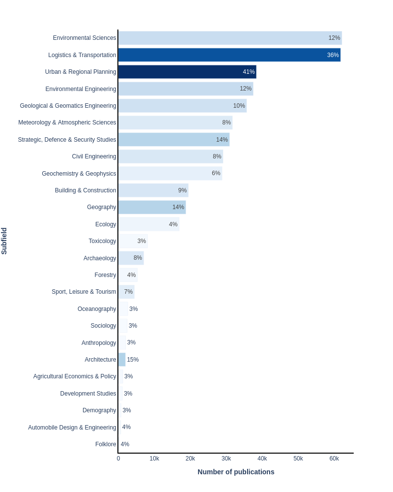

Figure 1. Top 25 subfields with the largest percentage of Scopus publication included in the publication set.

## Journals

In this section, we show how the publication set, captured by the query above, relates to scholarly journals. Journals are sorted in terms of their relevance using term frequency-inverse document frequency (TF-IDF). The horizontal bars are proportional to the number of publications contributed by the journal to the current publication set. The number alongside the horizontal bar is the proportion of the journal contributing to this publication set.

The articles on this topic are published most frequently in the following journals: *Sustainability (Switzerland)* (8,382 publications), *IOP Conference Series: Earth and Environmental Science* (7,802), and *Science of the Total Environment* (6,985).

Note, larger journals may not appear in the table below, as their SDG contribution may be relatively small compared to the size of the journal.

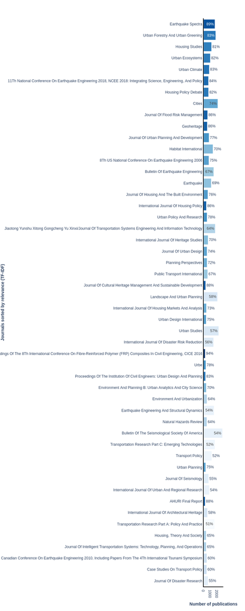

Figure 2. Top 50 journals, in terms of relevance (TF-IDF), for this publication set.

## Keywords

Elsevier’s [Scopus](https://www.scopus.com/search/form.uri?display=basic#basic) database of scientific literature, was used for the table below. The document types included in the data sets are journal articles, reviews, short surveys and conference papers, covering the period 1996–2022. We refer to these documents collectively as “publications” or “papers”.

In order to help better illustrate the content of this set of publications, indicators associated with the keywords most specific to this set (according to a TF-IDF score) are presented below.

|  | Term | # of papers with this term in the publication set | # of papers with this term in all of Scopus | Relevance (TF-IDF) | Percentage of Scopus |
| --- | --- | --- | --- | --- | --- |
| 1 | traffic emissions | 2418 | 2628 | 18.7542 | 92 |
| 2 | traffic emission | 3024 | 3288 | 18.7337 | 92 |
| 3 | urban heat island (uhi) | 2191 | 2416 | 18.7296 | 91 |
| 4 | urban canopy | 1249 | 1362 | 18.6961 | 92 |
| 5 | street canyon | 2210 | 2483 | 18.6941 | 89 |
| 6 | traffic-related air pollution | 1128 | 1216 | 18.6937 | 93 |
| 7 | urban canyon | 1696 | 1904 | 18.6871 | 89 |
| 8 | municipal solid waste incineration | 1695 | 1905 | 18.685 | 89 |
| 9 | urban green spaces | 1655 | 1859 | 18.684 | 89 |
| 10 | urban tree | 2195 | 2486 | 18.6791 | 88 |

[output cut: 990 more lines]